# Supplementary research evidence

Saved figures, result tables and calculation extracts for the experiment sections. Methods, interpretation and limitations are in the compact research appendix. Development narratives are omitted; the saved figures and tables are retained. Calculation extracts document individual experiments, not a single executable pipeline.

## E01. Initial sequential probability selection

**Calculation code (expand for reproducibility)**

```
from pathlib import Path
from zipfile import ZipFile
from io import StringIO
import re, json, hashlib, sys
import numpy as np
import pandas as pd
import matplotlib.pyplot as plt
from IPython.display import display, Markdown

ROOT = Path.cwd()
if not (ROOT / "data/raw").exists():
    raise RuntimeError("Run the notebook from the project root.")
DEV_START = "1964-01-01"
DEV_END = "2016-12-31"
HOLDOUT_START = "2017-01-01"
# 1964 gives a modern primary sample after Saturday trading ended.
# Earlier history is retained for a separately labelled descriptive stress check.
plt.rcParams.update({"figure.figsize": (11, 4), "axes.spines.top": False,
                     "axes.spines.right": False, "font.size": 11})
pd.set_option("display.max_columns", 12)
pd.set_option("display.precision", 4)
print("Python", sys.version.split()[0], "| pandas", pd.__version__, "| numpy", np.__version__)
```

**Calculation code (expand for reproducibility)**

```
manifest = json.loads((ROOT / "data/raw/manifest.json").read_text())
for name, item in manifest.items():
    actual = hashlib.sha256((ROOT / "data/raw" / name).read_bytes()).hexdigest()
    assert actual == item["sha256"], f"Snapshot changed: {name}"
display(pd.DataFrame(manifest).T[["retrieved_utc", "url", "sha256"]])

def read_daily_zip(filename, expected):
    with ZipFile(ROOT / "data/raw" / filename) as archive:
        members = [n for n in archive.namelist() if n.lower().endswith(".csv")]
        assert len(members) == 1
        lines = archive.read(members[0]).decode("utf-8-sig").splitlines()
    start = next(i for i, line in enumerate(lines) if re.match(r"^\s*\d{8},", line))
    stop = start
    while stop < len(lines) and re.match(r"^\s*\d{8},", lines[stop]):
        stop += 1
    frame = pd.read_csv(StringIO("\n".join(lines[start-1:stop])), index_col=0)
    frame.columns = frame.columns.str.strip()
    assert list(frame.columns) == expected, frame.columns.tolist()
    frame.index = pd.to_datetime(frame.index.astype(str), format="%Y%m%d")
    frame.index.name = "date"
    assert frame.index.is_unique and frame.index.is_monotonic_increasing
    frame = frame.apply(pd.to_numeric).replace([-99.99, -999], np.nan) / 100
    assert np.isfinite(frame.to_numpy()).all(), f"Missing/nonfinite data in {filename}"
    return frame

mom = read_daily_zip("momentum.zip", ["Mom"])
factors = read_daily_zip("factors.zip", ["Mkt-RF", "SMB", "HML", "RF"])
legs = read_daily_zip("portfolios.zip", ["SMALL LoPRIOR", "ME1 PRIOR2", "SMALL HiPRIOR",
                                        "BIG LoPRIOR", "ME2 PRIOR2", "BIG HiPRIOR"])
tables = {"Mom": mom, "Market factors": factors, "Six portfolios": legs}
display(pd.DataFrame({name: {"first": f.index.min().date(), "last": f.index.max().date(),
                            "rows": len(f), "missing": int(f.isna().sum().sum())}
                      for name, f in tables.items()}).T)
# Calendar agreement is checked before any join can silently discard dates.
assert mom.index.equals(legs.index)
assert mom.index.difference(factors.index).empty
daily = mom.join(factors[["Mkt-RF", "RF"]]).join(legs)
daily["winner"] = daily[["SMALL HiPRIOR", "BIG HiPRIOR"]].mean(axis=1)
daily["loser"] = daily[["SMALL LoPRIOR", "BIG LoPRIOR"]].mean(axis=1)
daily["reconstructed"] = daily["winner"] - daily["loser"]
daily["market"] = daily["Mkt-RF"] + daily["RF"]
error = daily["Mom"] - daily["reconstructed"]
# Each input is rounded to .01 percentage points; worst-case difference is 1.5 bp.
assert error.abs().max() <= 0.00015 + 1e-10
display(pd.Series({"max reconstruction difference (bp)": error.abs().max()*10000,
                   "mean absolute difference (bp)": error.abs().mean()*10000,
                   "dates missing from market": len(mom.index.difference(factors.index))}))
print("PASS: unique dates, finite returns, expected tables, matching calendars, factor reconstruction.")
```

|  | retrieved_utc | url | sha256 |
| --- | --- | --- | --- |
| momentum.zip | 2026-09-11T03:45:51.017590+00:00 | https://mba.tuck.dartmouth.edu/pages/faculty/k... | b039d986db27fc831bcf1f52ba2134916e96fbeba4762f... |
| factors.zip | 2026-09-11T03:45:52.755542+00:00 | https://mba.tuck.dartmouth.edu/pages/faculty/k... | 1916d331c2c51d2aee3d00215897d2b8e5995cb387f1f4... |
| portfolios.zip | 2026-09-11T03:45:54.984462+00:00 | https://mba.tuck.dartmouth.edu/pages/faculty/k... | 2f5708850280718f25693b0a44d9309995fa8a5bf4d169... |

|  | first | last | rows | missing |
| --- | --- | --- | --- | --- |
| Mom | 1926-11-03 | 2026-07-31 | 26195 | 0 |
| Market factors | 1926-07-01 | 2026-07-31 | 26296 | 0 |
| Six portfolios | 1926-11-03 | 2026-07-31 | 26195 | 0 |

**Calculation code (expand for reproducibility)**

```
dev = daily.loc[DEV_START:DEV_END].copy()

def weekly_pnl(frame):
    grouped = frame.resample("W-FRI")
    out = grouped[["Mom", "winner", "loser", "reconstructed"]].sum(min_count=1)
    out["market"] = grouped["market"].apply(lambda x: (1+x).prod()-1)
    out["sessions"] = grouped.size()
    dates = pd.Series(frame.index, index=frame.index)
    out["first_session"] = dates.resample("W-FRI").min()
    out["last_session"] = dates.resample("W-FRI").max()
    # Conservatively remove the first and last buckets, irrespective of weekday.
    out = out.iloc[1:-1]
    empty = out.index[out.sessions == 0]
    if len(empty):
        print("Excluded buckets with no source observations:", [d.date() for d in empty])
    out = out.loc[out.sessions > 0]
    assert (out.sessions > 0).all()
    return out

weekly = weekly_pnl(dev)
assert weekly.last_session.max() < pd.Timestamp(HOLDOUT_START)
display(weekly["sessions"].value_counts().sort_index().rename("weeks").to_frame())
print(f"Exploratory weekly buckets: {len(weekly):,}; {weekly.index.min().date()} to {weekly.index.max().date()}")
print("No post-2016 return summaries or charts are produced.")
```

| sessions | weeks |
| --- | --- |
| 1 | 1 |
| 3 | 6 |
| 4 | 467 |
| 5 | 2290 |

**Calculation code (expand for reproducibility)**

```
threshold = weekly.Mom.quantile(.05)
weekly["tail"] = weekly.Mom < threshold
summary = pd.Series({"weeks": len(weekly), "mean P&L (%)": weekly.Mom.mean()*100,
                     "weekly standard deviation (%)": weekly.Mom.std()*100,
                     "skewness": weekly.Mom.skew(), "minimum P&L (%)": weekly.Mom.min()*100,
                     "5th percentile P&L (%)": threshold*100,
                     "median P&L (%)": weekly.Mom.median()*100,
                     "95th percentile P&L (%)": weekly.Mom.quantile(.95)*100,
                     "tail observations": int(weekly["tail"].sum())})
display(summary.to_frame("development sample"))
fig, ax = plt.subplots(1, 2, figsize=(13, 4))
ax[0].hist(weekly.Mom*100, bins=70, color="#315b7c", alpha=.85)
ax[0].axvline(threshold*100, color="#bd493d", label="Development 5th percentile")
ax[0].set(xlabel="Weekly P&L (% of long-side notional)", ylabel="Weeks", title="Most weeks conceal a substantial left tail")
ax[0].legend(fontsize=8)
ax[1].plot(weekly.index, weekly.Mom*100, color="#315b7c", linewidth=.6)
ax[1].axhline(threshold*100, color="#bd493d", linestyle="--")
ax[1].set(ylabel="Weekly P&L (%)", title="When did losses occur? — development only")
fig.tight_layout(); plt.show()
```

|  | development sample |
| --- | --- |
| weeks | 2764.0000 |
| mean P&L (%) | 0.1461 |
| weekly standard deviation (%) | 1.8451 |
| skewness | -1.2733 |
| minimum P&L (%) | -16.7400 |
| 5th percentile P&L (%) | -2.7770 |
| median P&L (%) | 0.2450 |
| 95th percentile P&L (%) | 2.6700 |
| tail observations | 139.0000 |

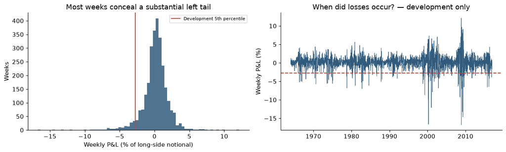

**Calculation code (expand for reproducibility)**

```
positions = np.flatnonzero(weekly["tail"].to_numpy())
def episodes(max_intervening):
    groups = np.cumsum(np.r_[True, np.diff(positions) > max_intervening+1])
    rows = []
    for group in np.unique(groups):
        selected = positions[groups == group]
        interval = weekly.iloc[selected[0]:selected[-1]+1]
        rows.append({"start": interval.index[0].date(), "end": interval.index[-1].date(),
                     "tail_weeks": len(selected), "calendar_weeks": len(interval),
                     "interval_P&L_pct": interval.Mom.sum()*100})
    return pd.DataFrame(rows)

runs, clusters = episodes(0), episodes(4)
display(pd.Series({"tail weeks": len(positions), "consecutive runs": len(runs),
                   "clusters allowing four intervening weeks": len(clusters)}).to_frame("count"))
display(clusters.sort_values("interval_P&L_pct").head(10))
monthly = dev.Mom.resample("ME").sum().iloc[1:-1]
display(monthly.nsmallest(5).mul(100).rename("monthly P&L (%)").to_frame())
```

|  | count |
| --- | --- |
| tail weeks | 139 |
| consecutive runs | 108 |
| clusters allowing four intervening weeks | 69 |

|  | start | end | tail_weeks | calendar_weeks | interval_P&L_pct |
| --- | --- | --- | --- | --- | --- |
| 52 | 2008-10-31 | 2009-05-22 | 17 | 30 | -55.61 |
| 34 | 2000-03-17 | 2000-05-26 | 5 | 11 | -32.68 |
| 36 | 2001-01-05 | 2001-01-19 | 3 | 3 | -24.20 |
| 43 | 2002-10-25 | 2002-11-29 | 5 | 6 | -22.38 |
| 51 | 2008-07-18 | 2008-09-19 | 4 | 10 | -20.44 |
| 13 | 1975-01-03 | 1975-01-31 | 3 | 5 | -17.41 |
| 53 | 2009-07-17 | 2009-08-07 | 4 | 4 | -16.58 |
| 39 | 2001-10-05 | 2001-11-16 | 5 | 7 | -16.10 |
| 16 | 1980-12-05 | 1981-01-09 | 2 | 6 | -13.27 |
| 14 | 1978-09-22 | 1978-10-27 | 3 | 6 | -13.12 |

| date | monthly P&L (%) |
| --- | --- |
| 2009-04-30 | -29.95 |
| 2001-01-31 | -24.09 |
| 2002-11-30 | -16.59 |
| 1975-01-31 | -15.70 |
| 2009-03-31 | -14.52 |

**Calculation code (expand for reproducibility)**

```
worst = weekly.nsmallest(10, "Mom")
attribution = pd.DataFrame({"factor": worst.Mom, "long contribution": worst.winner,
                            "short contribution": -worst.loser,
                            "rounding residual": worst.Mom-worst.reconstructed,
                            "market total return": worst.market}) * 100
display(attribution.round(3))
ax = attribution[["long contribution", "short contribution"]].plot.bar(
    color=["#315b7c", "#bd493d"], figsize=(12, 4))
ax.set_xticklabels([d.strftime("%Y-%m-%d") for d in worst.index], rotation=40, ha="right")
ax.axhline(0, color="black", linewidth=.7)
ax.set(ylabel="P&L contribution (%)", xlabel="Week bucket", title="Which side hurt in the ten worst weeks?")
plt.tight_layout(); plt.show()
tail_weeks = weekly.loc[weekly["tail"]]
display(Markdown(f"Of the {len(tail_weeks)} tail weeks, **{(tail_weeks.loser > 0).sum()}** had rising losers "
                 f"and **{(tail_weeks.market > 0).sum()}** had a rising market. "
                 "These are contemporaneous descriptions, not forecasting results."))
```

| date | factor | long contribution | short contribution | rounding residual | market total return |
| --- | --- | --- | --- | --- | --- |
| 2008-11-28 | -16.74 | 10.365 | -27.115 | 0.010 | 12.612 |
| 2000-04-14 | -16.61 | -21.790 | 5.185 | -0.005 | -13.671 |
| 2009-05-08 | -14.62 | 2.730 | -17.350 | 0.000 | 5.647 |
| 2009-03-13 | -13.28 | 8.230 | -21.505 | -0.005 | 10.708 |
| 2001-01-05 | -12.12 | -6.735 | -5.385 | 0.000 | -2.542 |
| 2000-03-17 | -9.81 | -2.350 | -7.455 | -0.005 | 1.976 |
| 2008-07-18 | -9.27 | -0.410 | -8.875 | 0.015 | 1.677 |
| 2009-03-27 | -9.18 | 5.010 | -14.185 | -0.005 | 6.453 |
| 1999-04-16 | -8.66 | -0.280 | -8.375 | -0.005 | -1.415 |
| 2009-04-17 | -8.11 | 0.605 | -8.705 | -0.010 | 1.569 |

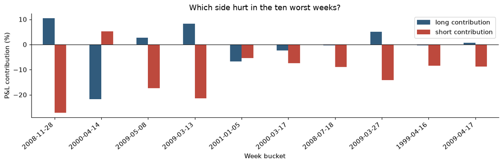

**Calculation code (expand for reproducibility)**

```
early = weekly_pnl(daily.loc[:"1963-12-31"])
display(pd.DataFrame({"pre-1964 stress history": {"weeks": len(early),
                    "worst weekly P&L (%)": early.Mom.min()*100,
                    "weeks with >5 sessions": int((early.sessions > 5).sum())},
                    "1964–2016 development": {"weeks": len(weekly),
                    "worst weekly P&L (%)": weekly.Mom.min()*100,
                    "weeks with >5 sessions": int((weekly.sessions > 5).sum())}}).T)
```

|  | weeks | worst weekly P&L (%) | weeks with >5 sessions |
| --- | --- | --- | --- |
| pre-1964 stress history | 1937.0 | -22.89 | 904.0 |
| 1964–2016 development | 2764.0 | -16.74 | 0.0 |

**Calculation code (expand for reproducibility)**

```
display(Markdown(f"""### Calculated checkpoint

- Development sample: **{len(weekly):,} weeks**.
- Provisional severe-loss boundary: **{threshold*100:.2f}%** of long-side notional.
- Below-boundary observations: **{len(positions)}**, forming **{len(runs)}** consecutive runs or **{len(clusters)}** broader clusters under the stated rule.
- Worst development week: **{weekly.Mom.idxmin().date()}**, **{weekly.Mom.min()*100:.2f}%**.
- Maximum daily factor reconstruction discrepancy: **{error.abs().max()*10000:.2f} basis points**.

**Next research step:** compare subsequent loss rates across a few prespecified volatility and market states within development data. This will test whether the economic hypotheses warrant the proposed small forecast model. Keep the reserved period closed until the design and validation protocol are fixed.
"""))
```

**Calculation code (expand for reproducibility)**

```
# Daily features use observations through that day's close, never future returns.
features = pd.DataFrame(index=dev.index)
features["mom_vol"] = dev.Mom.rolling(126, min_periods=126).std()
features["market_vol"] = dev.market.rolling(126, min_periods=126).std()
features["market_2y"] = np.expm1(np.log1p(dev.market).rolling(504, min_periods=504).sum())

state = features.reindex(pd.DatetimeIndex(weekly.last_session)).copy()
state.index = weekly.index
state["cutoff"] = weekly.last_session
for col in ["mom_vol", "market_vol"]:
    state[col + "_median"] = state[col].shift(1).expanding(min_periods=260).median()
state["next_pnl"] = weekly.Mom.shift(-1)
state["outcome_start"] = weekly.first_session.shift(-1)
state["outcome_end"] = weekly.last_session.shift(-1)
initial = weekly.loc[weekly.last_session < pd.Timestamp("1974-01-01"), "Mom"]
fixed_boundary = initial.quantile(.05)
sample = state.dropna().loc[lambda x: x.outcome_start >= pd.Timestamp("1974-01-01")].copy()
assert (sample.cutoff < sample.outcome_start).all()
assert sample.outcome_end.max() < pd.Timestamp(HOLDOUT_START)
assert initial.index.max() < sample.outcome_start.min()
sample["event"] = sample.next_pnl < fixed_boundary
sample["high_mom_vol"] = sample.mom_vol > sample.mom_vol_median
sample["high_market_vol"] = sample.market_vol > sample.market_vol_median
sample["bear"] = sample.market_2y < 0

display(Markdown(f"Frozen boundary: **{fixed_boundary*100:.2f}%** from **{len(initial)}** initial weeks. "
                 f"Comparison sample: **{len(sample)}** weeks, "
                 f"{sample.outcome_start.min().date()} to {sample.outcome_end.max().date()}."))
display(sample[["cutoff", "outcome_start", "outcome_end", "mom_vol", "market_2y", "next_pnl"]].head())
print("PASS: every state precedes its outcome; calibration ends before comparison; holdout excluded.")
```

| date | cutoff | outcome_start | outcome_end | mom_vol | market_2y | next_pnl |
| --- | --- | --- | --- | --- | --- | --- |
| 1974-01-04 | 1974-01-04 | 1974-01-07 | 1974-01-11 | 0.0078 | -0.0378 | 0.0054 |
| 1974-01-11 | 1974-01-11 | 1974-01-14 | 1974-01-18 | 0.0074 | -0.0996 | -0.0206 |
| 1974-01-18 | 1974-01-18 | 1974-01-21 | 1974-01-25 | 0.0072 | -0.0836 | -0.0244 |
| 1974-01-25 | 1974-01-25 | 1974-01-28 | 1974-02-01 | 0.0072 | -0.0623 | 0.0017 |
| 1974-02-01 | 1974-02-01 | 1974-02-04 | 1974-02-08 | 0.0071 | -0.0897 | 0.0100 |

**Calculation code (expand for reproducibility)**

```
def state_table(frame, group_columns):
    table = frame.groupby(group_columns, observed=True).agg(
        weeks=("event", "size"), events=("event", "sum"),
        event_rate=("event", "mean"), mean_pnl=("next_pnl", "mean"))
    table["event_rate_pct"] = 100*table.pop("event_rate")
    table["mean_pnl_pct"] = 100*table.pop("mean_pnl")
    if len(group_columns) == 2:
        full_index = pd.MultiIndex.from_product([[False, True], [False, True]], names=group_columns)
        table = table.reindex(full_index)
        table[["weeks", "events"]] = table[["weeks", "events"]].fillna(0).astype(int)
    return table

display(Markdown(f"Overall comparison-period loss frequency: **{sample.event.mean():.1%}**, "
                 f"**{sample.event.sum()}** events in **{len(sample)}** weeks."))
display(Markdown("**A. Momentum volatility: False = lower; True = higher than past median**"))
display(state_table(sample, ["high_mom_vol"]))
display(Markdown("**B. Market state: bear status × market volatility**"))
display(state_table(sample, ["bear", "high_market_vol"]))
display(Markdown("**Coarse incremental check: bear status within momentum-volatility groups**"))
display(state_table(sample, ["high_mom_vol", "bear"]))
```

| high_mom_vol | weeks | events | event_rate_pct | mean_pnl_pct |
| --- | --- | --- | --- | --- |
| False | 854 | 14 | 1.6393 | 0.2402 |
| True | 1388 | 161 | 11.5994 | 0.0576 |

| bear | high_market_vol | weeks | events | event_rate_pct | mean_pnl_pct |
| --- | --- | --- | --- | --- | --- |
| False | False | 763 | 19 | 2.4902 | 0.1955 |
|  | True | 1142 | 91 | 7.9685 | 0.1652 |
| True | False | 0 | 0 | NaN | NaN |
|  | True | 337 | 65 | 19.2878 | -0.1563 |

| high_mom_vol | bear | weeks | events | event_rate_pct | mean_pnl_pct |
| --- | --- | --- | --- | --- | --- |
| False | False | 821 | 13 | 1.5834 | 0.2453 |
|  | True | 33 | 1 | 3.0303 | 0.1118 |
| True | False | 1084 | 97 | 8.9483 | 0.1258 |
|  | True | 304 | 64 | 21.0526 | -0.1854 |

**Calculation code (expand for reproducibility)**

```
def contrasts(frame):
    a = frame.loc[frame.high_mom_vol, "event"].mean() - frame.loc[~frame.high_mom_vol, "event"].mean()
    b = (frame.loc[frame.bear & frame.high_market_vol, "event"].mean()
         - frame.loc[~frame.bear & frame.high_market_vol, "event"].mean())
    return np.array([a, b], dtype=float)*100

labels = ["High minus low momentum volatility", "Bear minus non-bear, high market volatility"]
def block_intervals(frame, block_length, repeats=2000):
    rng = np.random.default_rng(20260911)
    n = len(frame)
    draws = []
    for _ in range(repeats):
        starts = rng.integers(0, n-block_length+1, size=int(np.ceil(n/block_length)))
        indices = (starts[:, None]+np.arange(block_length)).ravel()[:n]
        draws.append(contrasts(frame.iloc[indices]))
    draws = np.asarray(draws)
    lower, upper = np.nanquantile(draws, [.025, .975], axis=0)
    return pd.DataFrame({"difference_pp": contrasts(frame), "lower_95_pp": lower,
                         "upper_95_pp": upper, "valid_draws": np.isfinite(draws).sum(axis=0)}, index=labels)

intervals = block_intervals(sample, 13)
display(intervals)
display(Markdown("**Sensitivity: 26-week blocks**"))
display(block_intervals(sample, 26))
fig, ax = plt.subplots(figsize=(10, 3.5))
for i, (_, row) in enumerate(intervals.iterrows()):
    ax.plot([row.lower_95_pp, row.upper_95_pp], [i, i], color="#315b7c", linewidth=3)
    ax.scatter(row.difference_pp, i, color="#bd493d", s=50, zorder=3)
ax.axvline(0, color="black", linestyle="--", linewidth=1)
ax.set(yticks=range(2), yticklabels=labels, xlabel="Difference in next-week loss frequency (percentage points)",
       title="Descriptive differences with 95% block-bootstrap intervals")
plt.tight_layout(); plt.show()
```

|  | difference_pp | lower_95_pp | upper_95_pp | valid_draws |
| --- | --- | --- | --- | --- |
| High minus low momentum volatility | 9.9601 | 7.3286 | 12.6757 | 2000 |
| Bear minus non-bear, high market volatility | 11.3194 | 4.5347 | 18.8210 | 2000 |

|  | difference_pp | lower_95_pp | upper_95_pp | valid_draws |
| --- | --- | --- | --- | --- |
| High minus low momentum volatility | 9.9601 | 7.1566 | 13.0515 | 2000 |
| Bear minus non-bear, high market volatility | 11.3194 | 3.6641 | 20.4300 | 2000 |

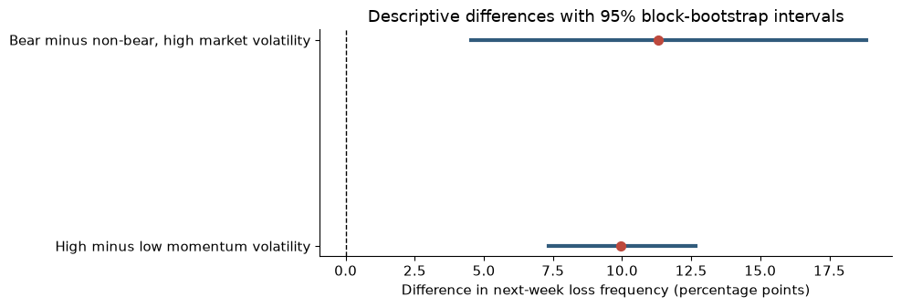

**Calculation code (expand for reproducibility)**

```
year = sample.outcome_end.dt.year
slices = {"All 1974–2016": sample,
          "1974–1999": sample.loc[year < 2000],
          "2000–2016": sample.loc[year >= 2000],
          "Excluding 2008–2009 outcomes": sample.loc[~year.between(2008, 2009)]}
stability = []
for name, frame in slices.items():
    a, b = contrasts(frame)
    stability.append({"sample": name, "weeks": len(frame), "events": int(frame.event.sum()),
                      "vol_difference_pp": a, "bear_difference_pp": b,
                      "bear_high_market_vol_weeks": int((frame.bear & frame.high_market_vol).sum()),
                      "bear_high_market_vol_events": int(frame.loc[frame.bear & frame.high_market_vol, "event"].sum())})
display(pd.DataFrame(stability).set_index("sample"))
display(Markdown("**Full subgroup denominators for the two eras**"))
display(pd.concat({k: state_table(v, ["bear", "high_market_vol"])
                   for k, v in slices.items() if k in ["1974–1999", "2000–2016"]}, names=["era"]))
```

| sample | weeks | events | vol_difference_pp | bear_difference_pp | bear_high_market_vol_weeks | bear_high_market_vol_events |
| --- | --- | --- | --- | --- | --- | --- |
| All 1974–2016 | 2242 | 175 | 9.9601 | 11.3194 | 337 | 65 |
| 1974–1999 | 1356 | 64 | 7.0380 | 2.3634 | 103 | 9 |
| 2000–2016 | 886 | 111 | 11.5598 | 12.8776 | 234 | 56 |
| Excluding 2008–2009 outcomes | 2137 | 140 | 8.1814 | 6.9569 | 271 | 39 |

| era | bear | high_market_vol | weeks | events | event_rate_pct | mean_pnl_pct |
| --- | --- | --- | --- | --- | --- | --- |
| 1974–1999 | False | False | 500 | 7 | 1.4000 | 0.2425 |
|  |  | True | 753 | 48 | 6.3745 | 0.1726 |
|  | True | False | 0 | 0 | NaN | NaN |
|  |  | True | 103 | 9 | 8.7379 | -0.1146 |
| 2000–2016 | False | False | 263 | 12 | 4.5627 | 0.1060 |
|  |  | True | 389 | 43 | 11.0540 | 0.1508 |
|  | True | False | 0 | 0 | NaN | NaN |
|  |  | True | 234 | 56 | 23.9316 | -0.1747 |

**Calculation code (expand for reproducibility)**

```
display(Markdown(f"""### Evidence to carry forward

- High versus lower momentum-volatility difference: **{contrasts(sample)[0]:.2f} percentage points**.
- Bear versus non-bear difference within high market volatility: **{contrasts(sample)[1]:.2f} percentage points**.
- Bear/low-market-volatility observations: **{int((sample.bear & ~sample.high_market_vol).sum())}**.

**Recommendation:** proceed to the historical-frequency and volatility-only forecast baselines next. The state result merits a later controlled comparison; it does not yet demonstrate incremental forecasting skill. No held-out outcomes have been examined.
"""))
```

**Calculation code (expand for reproducibility)**

```
from sklearn.linear_model import LogisticRegression
from sklearn.preprocessing import StandardScaler
import sklearn
print("scikit-learn", sklearn.__version__)

forecast_parts, fit_records, annual_models = [], [], {}
for forecast_year in range(1984, 2017):
    test = sample.loc[sample.outcome_start.dt.year == forecast_year].copy()
    fit_cutoff = test.cutoff.min()
    train = sample.loc[sample.outcome_end <= fit_cutoff].copy()
    assert train.outcome_start.min().year == 1974
    assert train.outcome_end.max() <= fit_cutoff < test.outcome_start.min()
    assert train.index.intersection(test.index).empty
    assert train.event.nunique() == 2
    scaler = StandardScaler()
    x_train = scaler.fit_transform(np.log(train[["mom_vol"]]))
    model = LogisticRegression(C=1.0, solver="lbfgs", max_iter=1000, tol=1e-9)
    model.fit(x_train, train.event.astype(int))
    assert model.n_iter_[0] < 1000
    test["p_frequency"] = train.event.mean()
    test["p_volatility"] = model.predict_proba(scaler.transform(np.log(test[["mom_vol"]])))[:, 1]
    test["refit_year"] = forecast_year
    forecast_parts.append(test)
    slope_log_vol = float(model.coef_[0, 0]/scaler.scale_[0])
    annual_models[forecast_year] = (scaler, model)
    fit_records.append({"year": forecast_year, "fit_cutoff": fit_cutoff,
                        "last_training_outcome": train.outcome_end.max(), "training_weeks": len(train),
                        "training_events": int(train.event.sum()), "historical_rate": train.event.mean(),
                        "slope_log_vol": slope_log_vol, "odds_ratio_for_double_vol": np.exp(slope_log_vol*np.log(2))})

forecasts = pd.concat(forecast_parts).sort_index()
fits = pd.DataFrame(fit_records).set_index("year")
assert forecasts.index.is_unique
assert forecasts.outcome_end.max() < pd.Timestamp(HOLDOUT_START)
assert np.isfinite(forecasts[["p_frequency", "p_volatility"]]).all().all()
assert forecasts[["p_frequency", "p_volatility"]].gt(0).all().all()
assert forecasts[["p_frequency", "p_volatility"]].lt(1).all().all()
display(fits.iloc[[0, 1, -1]])
print(f"PASS: {len(forecasts)} sequential forecasts, {len(fits)} converged annual fits, no unfinished training labels.")
```

| year | fit_cutoff | last_training_outcome | training_weeks | training_events | historical_rate | slope_log_vol | odds_ratio_for_double_vol |
| --- | --- | --- | --- | --- | --- | --- | --- |
| 1984 | 1983-12-30 | 1983-12-30 | 521 | 31 | 0.0595 | 2.0143 | 4.0398 |
| 1985 | 1985-01-04 | 1985-01-04 | 574 | 32 | 0.0557 | 2.0586 | 4.1658 |
| 2016 | 2015-12-31 | 2015-12-31 | 2191 | 169 | 0.0771 | 1.7185 | 3.2909 |

**Calculation code (expand for reproducibility)**

```
y = forecasts.event.astype(int).to_numpy()
for label in ["frequency", "volatility"]:
    p = forecasts["p_" + label].to_numpy()
    forecasts["brier_" + label] = (p-y)**2
    forecasts["logloss_" + label] = -(y*np.log(p)+(1-y)*np.log1p(-p))

def score_table(frame):
    return pd.DataFrame({label: {"weeks": len(frame), "events": int(frame.event.sum()),
                       "mean_probability": frame["p_"+label].mean(), "event_rate": frame.event.mean(),
                       "brier": frame["brier_"+label].mean(), "log_loss": frame["logloss_"+label].mean()}
                         for label in ["frequency", "volatility"]}).T
display(score_table(forecasts))

def paired_score_intervals(frame, block_length=13, repetitions=2000):
    differences = np.column_stack([frame[metric+"_volatility"]-frame[metric+"_frequency"]
                                   for metric in ["brier", "logloss"]])
    rng = np.random.default_rng(20260911)
    n = len(frame)
    boot = np.empty((repetitions, 2))
    for b in range(repetitions):
        starts = rng.integers(0, n-block_length+1, size=int(np.ceil(n/block_length)))
        indices = (starts[:, None]+np.arange(block_length)).ravel()[:n]
        boot[b] = differences[indices].mean(axis=0)
    lo, hi = np.quantile(boot, [.025, .975], axis=0)
    return pd.DataFrame({"difference": differences.mean(axis=0), "lower_95": lo, "upper_95": hi},
                        index=["Brier", "Log loss"])

display(paired_score_intervals(forecasts, 13))
display(Markdown("**26-week block sensitivity**"))
display(paired_score_intervals(forecasts, 26))
non_crisis = forecasts.loc[~forecasts.outcome_end.dt.year.between(2008, 2009)]
display(Markdown("**Scores excluding 2008–2009 outcomes**"))
display(score_table(non_crisis))
# No bootstrap on the concatenated non-crisis slice: it would bridge the removed gap.
yearly = forecasts.groupby("refit_year").agg(weeks=("event", "size"), events=("event", "sum"),
            brier_frequency=("brier_frequency", "mean"), brier_volatility=("brier_volatility", "mean"),
            logloss_frequency=("logloss_frequency", "mean"), logloss_volatility=("logloss_volatility", "mean"))
yearly["brier_difference"] = yearly.brier_volatility-yearly.brier_frequency
yearly["logloss_difference"] = yearly.logloss_volatility-yearly.logloss_frequency
display(yearly)
ax = yearly[["brier_difference"]].plot.bar(color="#315b7c", legend=False, figsize=(12, 3.5))
ax.axhline(0, color="black", linewidth=.7)
ax.set(ylabel="Brier difference: volatility − frequency", xlabel="Outcome year",
       title="Negative favors volatility; yearly results can be noisy")
plt.tight_layout(); plt.show()
```

|  | weeks | events | mean_probability | event_rate | brier | log_loss |
| --- | --- | --- | --- | --- | --- | --- |
| frequency | 1721.0 | 144.0 | 0.0600 | 0.0837 | 0.0771 | 0.2909 |
| volatility | 1721.0 | 144.0 | 0.0897 | 0.0837 | 0.0689 | 0.2484 |

|  | difference | lower_95 | upper_95 |
| --- | --- | --- | --- |
| Brier | -0.0082 | -0.0161 | -0.0023 |
| Log loss | -0.0425 | -0.0704 | -0.0200 |

|  | difference | lower_95 | upper_95 |
| --- | --- | --- | --- |
| Brier | -0.0082 | -0.0185 | -0.0018 |
| Log loss | -0.0425 | -0.0802 | -0.0167 |

|  | weeks | events | mean_probability | event_rate | brier | log_loss |
| --- | --- | --- | --- | --- | --- | --- |
| frequency | 1616.0 | 109.0 | 0.0594 | 0.0675 | 0.0631 | 0.2487 |
| volatility | 1616.0 | 109.0 | 0.0752 | 0.0675 | 0.0606 | 0.2270 |

| refit_year | weeks | events | brier_frequency | brier_volatility | logloss_frequency | logloss_volatility | brier_difference | logloss_difference |
| --- | --- | --- | --- | --- | --- | --- | --- | --- |
| 1984 | 53 | 1 | 0.0202 | 0.0195 | 0.1134 | 0.1039 | -0.0007 | -0.0096 |
| 1985 | 52 | 1 | 0.0202 | 0.0193 | 0.1118 | 0.1029 | -0.0009 | -0.0089 |
| 1986 | 52 | 3 | 0.0544 | 0.0540 | 0.2208 | 0.2136 | -0.0004 | -0.0072 |
| 1987 | 52 | 3 | 0.0544 | 0.0596 | 0.2208 | 0.2531 | 0.0052 | 0.0324 |
| 1988 | 52 | 1 | 0.0200 | 0.0215 | 0.1102 | 0.1031 | 0.0015 | -0.0071 |
| 1989 | 52 | 0 | 0.0026 | 0.0004 | 0.0525 | 0.0184 | -0.0022 | -0.0341 |
| 1990 | 53 | 4 | 0.0705 | 0.0699 | 0.2747 | 0.2704 | -0.0006 | -0.0043 |
| 1991 | 52 | 5 | 0.0891 | 0.0853 | 0.3348 | 0.2998 | -0.0038 | -0.0350 |
| 1992 | 52 | 1 | 0.0199 | 0.0202 | 0.1094 | 0.1085 | 0.0002 | -0.0009 |
| 1993 | 52 | 2 | 0.0371 | 0.0367 | 0.1647 | 0.1587 | -0.0004 | -0.0059 |
| 1994 | 52 | 1 | 0.0198 | 0.0189 | 0.1078 | 0.0947 | -0.0009 | -0.0132 |
| 1995 | 52 | 1 | 0.0197 | 0.0194 | 0.1069 | 0.1047 | -0.0004 | -0.0022 |
| 1996 | 53 | 2 | 0.0364 | 0.0360 | 0.1617 | 0.1566 | -0.0004 | -0.0051 |
| 1997 | 52 | 0 | 0.0022 | 0.0013 | 0.0478 | 0.0363 | -0.0009 | -0.0115 |
| 1998 | 52 | 2 | 0.0370 | 0.0358 | 0.1635 | 0.1480 | -0.0012 | -0.0155 |
| 1999 | 52 | 6 | 0.1071 | 0.1012 | 0.3994 | 0.3526 | -0.0059 | -0.0468 |
| 2000 | 52 | 9 | 0.1590 | 0.1725 | 0.5685 | 0.5409 | 0.0135 | -0.0276 |
| 2001 | 53 | 14 | 0.2394 | 0.2007 | 0.8209 | 0.5966 | -0.0387 | -0.2243 |
| 2002 | 52 | 9 | 0.1560 | 0.1366 | 0.5390 | 0.4364 | -0.0194 | -0.1026 |
| 2003 | 52 | 8 | 0.1383 | 0.1278 | 0.4797 | 0.4213 | -0.0106 | -0.0584 |
| 2004 | 52 | 3 | 0.0544 | 0.0535 | 0.2212 | 0.2131 | -0.0010 | -0.0081 |
| 2005 | 52 | 1 | 0.0211 | 0.0201 | 0.1194 | 0.1104 | -0.0010 | -0.0089 |
| 2006 | 52 | 5 | 0.0879 | 0.0899 | 0.3237 | 0.3413 | 0.0020 | 0.0175 |
| 2007 | 53 | 2 | 0.0371 | 0.0377 | 0.1681 | 0.1741 | 0.0006 | 0.0060 |
| 2008 | 52 | 14 | 0.2385 | 0.1914 | 0.7856 | 0.5737 | -0.0471 | -0.2119 |
| 2009 | 52 | 21 | 0.3518 | 0.2046 | 1.1139 | 0.5899 | -0.1472 | -0.5240 |
| 2010 | 52 | 4 | 0.0710 | 0.0706 | 0.2712 | 0.2675 | -0.0005 | -0.0038 |
| 2011 | 52 | 4 | 0.0710 | 0.0719 | 0.2712 | 0.2739 | 0.0009 | 0.0026 |
| 2012 | 53 | 5 | 0.0857 | 0.0832 | 0.3138 | 0.3012 | -0.0024 | -0.0127 |
| 2013 | 52 | 0 | 0.0064 | 0.0019 | 0.0835 | 0.0440 | -0.0045 | -0.0395 |
| 2014 | 52 | 1 | 0.0223 | 0.0199 | 0.1288 | 0.1081 | -0.0024 | -0.0207 |
| 2015 | 52 | 5 | 0.0873 | 0.0869 | 0.3190 | 0.3165 | -0.0004 | -0.0026 |
| 2016 | 51 | 6 | 0.1054 | 0.1042 | 0.3723 | 0.3634 | -0.0012 | -0.0089 |

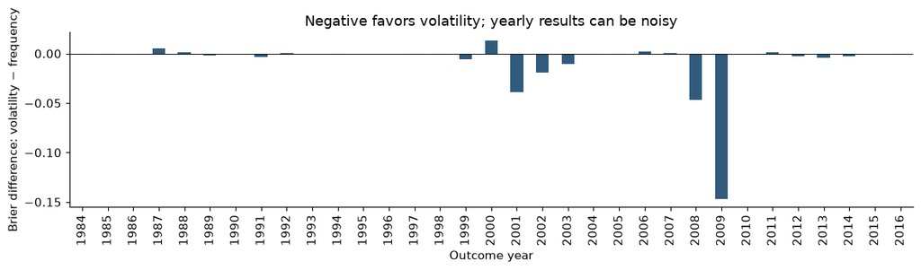

**Calculation code (expand for reproducibility)**

```
edges = [0, .025, .05, .10, .20, 1.0]
calibration = {}
for label in ["frequency", "volatility"]:
    temp = forecasts.assign(bin=pd.cut(forecasts["p_"+label], edges, include_lowest=True))
    calibration[label] = temp.groupby("bin", observed=False).agg(
        weeks=("event", "size"), events=("event", "sum"),
        mean_prediction=("p_"+label, "mean"), realized_rate=("event", "mean"))
display(pd.concat(calibration, names=["model"]))
fig, ax = plt.subplots(figsize=(6, 5))
for label, table in calibration.items():
    valid = table.loc[table.weeks > 0]
    ax.plot(valid.mean_prediction, valid.realized_rate, "o-", label=label)
    for _, row in valid.iterrows():
        ax.annotate(f"n={int(row.weeks)}", (row.mean_prediction, row.realized_rate),
                    xytext=(3, 5), textcoords="offset points", fontsize=8)
ax.plot([0, .5], [0, .5], "--", color="grey", label="Ideal calibration")
ax.set(xlabel="Mean predicted probability", ylabel="Observed loss frequency", title="Pooled calibration; labels show weeks")
ax.legend(); plt.tight_layout(); plt.show()
```

| model | bin | weeks | events | mean_prediction | realized_rate |
| --- | --- | --- | --- | --- | --- |
| frequency | (-0.001, 0.025] | 0 | 0 | NaN | NaN |
|  | (0.025, 0.05] | 470 | 30 | 0.0473 | 0.0638 |
|  | (0.05, 0.1] | 1251 | 114 | 0.0647 | 0.0911 |
|  | (0.1, 0.2] | 0 | 0 | NaN | NaN |
|  | (0.2, 1.0] | 0 | 0 | NaN | NaN |
| volatility | (-0.001, 0.025] | 244 | 4 | 0.0187 | 0.0164 |
|  | (0.025, 0.05] | 537 | 17 | 0.0365 | 0.0317 |
|  | (0.05, 0.1] | 479 | 33 | 0.0685 | 0.0689 |
|  | (0.1, 0.2] | 308 | 44 | 0.1503 | 0.1429 |
|  | (0.2, 1.0] | 153 | 46 | 0.3343 | 0.3007 |

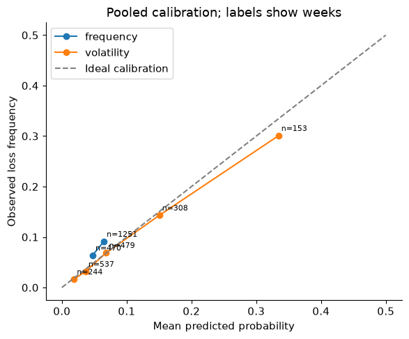

**Calculation code (expand for reproducibility)**

```
fig, ax = plt.subplots(1, 2, figsize=(12, 4))
ax[0].plot(fits.index, fits.slope_log_vol, color="#315b7c")
ax[0].axhline(0, color="grey", linestyle="--")
ax[0].set(xlabel="Refit year", ylabel="Slope per unit of log volatility", title="Is the direction stable?")
for year in [1984, 2000, 2016]:
    scaler, model = annual_models[year]
    training_vol = sample.loc[sample.outcome_end <= fits.loc[year, "fit_cutoff"], "mom_vol"]
    grid = np.geomspace(training_vol.quantile(.05), training_vol.quantile(.95), 100)
    probability = model.predict_proba(scaler.transform(pd.DataFrame({"mom_vol": np.log(grid)})))[:, 1]
    ax[1].plot(grid*100, probability, label=str(year))
ax[1].set(xlabel="Trailing daily momentum volatility (%)", ylabel="Next-week loss probability",
          title="Training-range probability curves")
ax[1].legend(); plt.tight_layout(); plt.show()
display(fits[["training_weeks", "training_events", "slope_log_vol", "odds_ratio_for_double_vol"]].iloc[[0, 16, -1]])
```

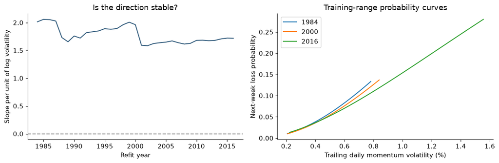

| year | training_weeks | training_events | slope_log_vol | odds_ratio_for_double_vol |
| --- | --- | --- | --- | --- |
| 1984 | 521 | 31 | 2.0143 | 4.0398 |
| 2000 | 1356 | 64 | 1.9630 | 3.8987 |
| 2016 | 2191 | 169 | 1.7185 | 3.2909 |

**Calculation code (expand for reproducibility)**

```
overall_scores = score_table(forecasts)
skill = 1-overall_scores.loc["volatility", "brier"]/overall_scores.loc["frequency", "brier"]
display(Markdown(f"""### Calculated findings

- Relative Brier-score improvement: **{skill:.1%}**.
- Years with lower Brier score: **{int((yearly.brier_difference < 0).sum())} / {len(yearly)}**.
- Years with lower log loss: **{int((yearly.logloss_difference < 0).sum())} / {len(yearly)}**.
- Positive fitted volatility slopes: **{int((fits.slope_log_vol > 0).sum())} / {len(fits)}**.
- Mean predicted probability: **{forecasts.p_volatility.mean():.1%}**; realized event frequency: **{forecasts.event.mean():.1%}**.
- Excluding 2008–2009 outcomes, Brier difference: **{(non_crisis.brier_volatility-non_crisis.brier_frequency).mean():.5f}**; log-loss difference: **{(non_crisis.logloss_volatility-non_crisis.logloss_frequency).mean():.5f}**. Negative favors volatility.

We have implemented the two baselines, their common chronological evaluation, calibration diagnostics and stability checks. No post-2016 outcomes enter these results.
"""))
```

**Calculation code (expand for reproducibility)**

```
import warnings
from sklearn.exceptions import ConvergenceWarning
warnings.filterwarnings("error", category=ConvergenceWarning)
C_GRID = [0.01, 0.1, 1.0, 10.0]
FEATURES = {"tuned_volatility": ["log_mom"],
            "market_volatility": ["log_mom", "log_market"],
            "market_state": ["log_mom", "log_market", "bear", "bear_x_market"]}

def design(frame, model_name):
    x = pd.DataFrame(index=frame.index)
    x["log_mom"] = np.log(frame.mom_vol/.01)
    x["log_market"] = np.log(frame.market_vol/.01)
    x["bear"] = frame.bear.astype(float)
    x["bear_x_market"] = x.bear*x.log_market
    return x[FEATURES[model_name]]

def fit_logistic(train, model_name, c):
    scaler = StandardScaler()
    x = scaler.fit_transform(design(train, model_name))
    model = LogisticRegression(C=c, solver="lbfgs", max_iter=2000, tol=1e-9)
    model.fit(x, train.event.astype(int))
    assert model.n_iter_[0] < 2000
    return scaler, model

def predict_logistic(fitted, frame, model_name):
    scaler, model = fitted
    return model.predict_proba(scaler.transform(design(frame, model_name)))[:, 1]

def binary_log_loss(y, p):
    # Clip only for numerical evaluation, using the same rule for all candidates.
    p = np.clip(np.asarray(p), 1e-12, 1-1e-12)
    y = np.asarray(y, dtype=float)
    return -(y*np.log(p)+(1-y)*np.log1p(-p))

def choose_c(train, model_name, forecast_year):
    totals = {c: [] for c in C_GRID}
    for start_year in range(forecast_year-6, forecast_year, 2):
        valid = train.loc[train.outcome_start.dt.year.between(start_year, start_year+1)]
        assert len(valid) > 80
        inner = train.loc[train.outcome_end <= valid.cutoff.min()]
        assert len(inner) >= 150 and inner.event.nunique() == 2
        assert inner.outcome_end.max() <= valid.cutoff.min() < valid.outcome_start.min()
        assert inner.index.intersection(valid.index).empty
        for c in C_GRID:
            fitted = fit_logistic(inner, model_name, c)
            totals[c].extend(binary_log_loss(valid.event, predict_logistic(fitted, valid, model_name)))
    losses = {c: float(np.mean(values)) for c, values in totals.items()}
    selected = min(C_GRID, key=lambda c: (losses[c], c))
    return selected, losses

extended = forecasts.copy()
extension_fits, extension_models, tuning_records = [], {}, []
for year in range(1984, 2017):
    test = sample.loc[sample.outcome_start.dt.year == year]
    train = sample.loc[sample.outcome_end <= test.cutoff.min()]
    for name in FEATURES:
        c, losses = choose_c(train, name, year)
        fitted = fit_logistic(train, name, c)
        extended.loc[test.index, "p_"+name] = predict_logistic(fitted, test, name)
        extension_models[(year, name)] = fitted
        scaler, model = fitted
        coefficients = model.coef_[0]/scaler.scale_
        extension_fits.append({"year": year, "model": name, "C": c, "training_weeks": len(train),
                               **dict(zip(FEATURES[name], coefficients))})
        tuning_records.extend({"year": year, "model": name, "C": value, "inner_log_loss": loss}
                              for value, loss in losses.items())
extension_fit_table = pd.DataFrame(extension_fits)
MODEL_NAMES = ["frequency", "volatility", *FEATURES]
def add_scores(frame, names):
    out = frame.copy()
    for name in names:
        p = out["p_"+name]
        assert p.notna().all() and p.between(0, 1).all()
        out["brier_"+name] = (p-out.event.astype(int))**2
        out["logloss_"+name] = binary_log_loss(out.event, p)
    return out

def all_scores(frame, names):
    return pd.DataFrame({name: {"weeks": len(frame), "events": int(frame.event.sum()),
                         "mean_probability": frame["p_"+name].mean(), "event_rate": frame.event.mean(),
                         "brier": frame["brier_"+name].mean(), "log_loss": frame["logloss_"+name].mean()}
                        for name in names}).T
extended = add_scores(extended, MODEL_NAMES)
assert extended.index.equals(forecasts.index)
display(all_scores(extended, MODEL_NAMES))
display(extension_fit_table.groupby(["model", "C"]).size().unstack(fill_value=0).rename_axis(columns="chosen C"))
```

|  | weeks | events | mean_probability | event_rate | brier | log_loss |
| --- | --- | --- | --- | --- | --- | --- |
| frequency | 1721.0 | 144.0 | 0.0600 | 0.0837 | 0.0771 | 0.2909 |
| volatility | 1721.0 | 144.0 | 0.0897 | 0.0837 | 0.0689 | 0.2484 |
| tuned_volatility | 1721.0 | 144.0 | 0.0896 | 0.0837 | 0.0689 | 0.2486 |
| market_volatility | 1721.0 | 144.0 | 0.0888 | 0.0837 | 0.0686 | 0.2489 |
| market_state | 1721.0 | 144.0 | 0.0915 | 0.0837 | 0.0685 | 0.2491 |

| chosen C model | 0.01 | 0.10 | 1.00 | 10.00 |
| --- | --- | --- | --- | --- |
| market_state | 16 | 8 | 3 | 6 |
| market_volatility | 6 | 12 | 6 | 9 |
| tuned_volatility | 0 | 15 | 1 | 17 |

**Calculation code (expand for reproducibility)**

```
def compare_models(frame, candidate, comparator, block=13):
    differences = np.column_stack([frame[m+"_"+candidate]-frame[m+"_"+comparator]
                                   for m in ["brier", "logloss"]])
    rng = np.random.default_rng(20260911)
    n = len(frame)
    draws = np.empty((2000, 2))
    for i in range(2000):
        starts = rng.integers(0, n-block+1, size=int(np.ceil(n/block)))
        idx = (starts[:, None]+np.arange(block)).ravel()[:n]
        draws[i] = differences[idx].mean(axis=0)
    lo, hi = np.quantile(draws, [.025, .975], axis=0)
    return pd.DataFrame({"difference": differences.mean(axis=0), "lower": lo, "upper": hi},
                        index=["brier", "logloss"])

def promotion(candidate, comparator):
    small = compare_models(extended, candidate, comparator, 13)
    large = compare_models(extended, candidate, comparator, 26)
    ex = extended.loc[~extended.outcome_end.dt.year.between(2008, 2009)]
    ex_brier = (ex["brier_"+candidate]-ex["brier_"+comparator]).mean()
    ex_log = (ex["logloss_"+candidate]-ex["logloss_"+comparator]).mean()
    annual = (extended["brier_"+candidate]-extended["brier_"+comparator]).groupby(extended.refit_year).mean()
    passes = (small.difference.lt(0).all() and small.loc["brier", "upper"] < 0
              and large.loc["brier", "upper"] < 0 and ex_brier < 0 and ex_log < 0
              and (annual < 0).sum() > len(annual)/2)
    return {"candidate": candidate, "comparator": comparator, "brier_difference": small.loc["brier", "difference"],
            "brier_upper13": small.loc["brier", "upper"], "brier_upper26": large.loc["brier", "upper"],
            "logloss_difference": small.loc["logloss", "difference"], "ex_crisis_brier": ex_brier,
            "ex_crisis_logloss": ex_log, "years_better": int((annual < 0).sum()), "promote": bool(passes)}

comparisons = []
selected_model = "volatility"
check = promotion("tuned_volatility", selected_model)
comparisons.append(check)
if check["promote"]:
    selected_model = "tuned_volatility"
for candidate, required_control in [("market_volatility", "tuned_volatility"), ("market_state", "market_volatility")]:
    checks = [promotion(candidate, comparator) for comparator in dict.fromkeys([selected_model, required_control])]
    comparisons.extend(checks)
    if all(row["promote"] for row in checks):
        selected_model = candidate
selection_table = pd.DataFrame(comparisons)
display(selection_table)
display(Markdown(f"**Development-selected specification: `{selected_model}`.** Selection does not use post-2016 scores."))
```

|  | candidate | comparator | brier_difference | brier_upper13 | brier_upper26 | logloss_difference | ex_crisis_brier | ex_crisis_logloss | years_better | promote |
| --- | --- | --- | --- | --- | --- | --- | --- | --- | --- | --- |
| 0 | tuned_volatility | volatility | 2.6050e-05 | 0.0003 | 0.0003 | 0.0002 | 3.9924e-05 | 0.0003 | 17 | False |
| 1 | market_volatility | volatility | -3.0814e-04 | 0.0004 | 0.0004 | 0.0005 | -5.8157e-05 | 0.0011 | 21 | False |
| 2 | market_volatility | tuned_volatility | -3.3419e-04 | 0.0004 | 0.0005 | 0.0002 | -9.8080e-05 | 0.0008 | 20 | False |
| 3 | market_state | volatility | -3.3747e-04 | 0.0012 | 0.0010 | 0.0007 | -4.2185e-04 | 0.0001 | 13 | False |
| 4 | market_state | market_volatility | -2.9324e-05 | 0.0015 | 0.0012 | 0.0003 | -3.6370e-04 | -0.0010 | 13 | False |

**Calculation code (expand for reproducibility)**

```
display(design(sample, "market_state").corr())
diagnostics = []
for (year, name), (scaler, model) in extension_models.items():
    train = sample.loc[sample.outcome_end <= fits.loc[year, "fit_cutoff"]]
    x = scaler.transform(design(train, name))
    diagnostics.append({"year": year, "model": name, "condition_number": np.linalg.cond(np.column_stack([np.ones(len(x)), x])),
                        "bear_weeks": int(train.bear.sum()), "bear_events": int(train.loc[train.bear, "event"].sum())})
display(pd.DataFrame(diagnostics).groupby("model").agg(max_condition=("condition_number", "max"),
            min_bear_weeks=("bear_weeks", "min"), min_bear_events=("bear_events", "min")))
display(extension_fit_table.groupby("model")[["log_mom", "log_market", "bear", "bear_x_market"]].agg(["min", "max"]))
fig, axes = plt.subplots(1, 2, figsize=(12, 4))
for name in ["market_volatility", "market_state"]:
    subset = extension_fit_table.loc[extension_fit_table.model == name]
    axes[0].plot(subset.year, subset.log_market, label=name)
state_coefs = extension_fit_table.loc[extension_fit_table.model == "market_state"]
axes[1].plot(state_coefs.year, state_coefs.bear, label="bear at 1% market vol")
axes[1].plot(state_coefs.year, state_coefs.bear_x_market, label="bear × log market vol")
for ax in axes:
    ax.axhline(0, color="grey", linestyle="--"); ax.set_xlabel("Refit year"); ax.legend(fontsize=8)
axes[0].set_title("Market-volatility coefficient")
axes[1].set_title("State coefficients: stability matters")
plt.tight_layout(); plt.show()
```

|  | log_mom | log_market | bear | bear_x_market |
| --- | --- | --- | --- | --- |
| log_mom | 1.0000 | 0.8083 | 0.4642 | 0.5561 |
| log_market | 0.8083 | 1.0000 | 0.5173 | 0.6091 |
| bear | 0.4642 | 0.5173 | 1.0000 | 0.6697 |
| bear_x_market | 0.5561 | 0.6091 | 0.6697 | 1.0000 |

| model | max_condition | min_bear_weeks | min_bear_events |
| --- | --- | --- | --- |
| market_state | 5.9177 | 103 | 9 |
| market_volatility | 3.2587 | 103 | 9 |
| tuned_volatility | 1.0000 | 103 | 9 |

| model | log_mom min | log_mom max | log_market min | log_market max | bear min | bear max | bear_x_market min | bear_x_market max |
| --- | --- | --- | --- | --- | --- | --- | --- | --- |
| market_state | 0.3161 | 2.3901 | -1.2068 | 0.7816 | -0.5795 | 0.1247 | 0.7439 | 4.9435 |
| market_volatility | 0.3787 | 1.9343 | 0.1440 | 1.3549 | NaN | NaN | NaN | NaN |
| tuned_volatility | 1.3070 | 2.0533 | NaN | NaN | NaN | NaN | NaN | NaN |

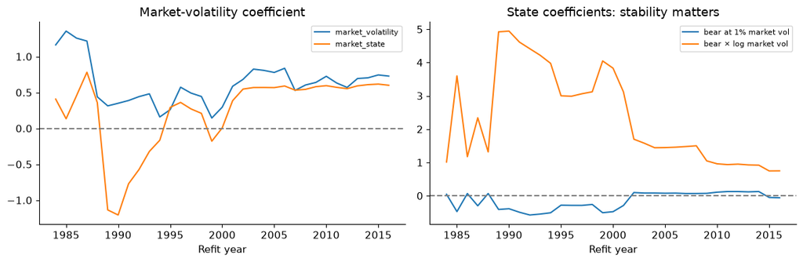

**Calculation code (expand for reproducibility)**

```
record = {"selected_model": selected_model, "loss_threshold": float(fixed_boundary),
          "initial_threshold_period": "1964–1973", "development_forecasts": "1984–2016",
          "holdout_start": "2017-01-01", "refit": "annual expanding completed outcomes",
          "C_grid": C_GRID, "inner_validation": "three trailing two-year blocks; pooled log loss",
          "fixed_volatility_C": 1.0, "features": FEATURES,
          "promotion_rule": "both scores improve, Brier upper13 and upper26 <0, ex-crisis both improve, majority years",
          "source_hashes": {k: v["sha256"] for k, v in manifest.items()},
          "development_comparisons": selection_table.to_dict(orient="records")}
record_path = ROOT / "model_selection.json"
if record_path.exists():
    assert json.loads(record_path.read_text()) == record, "Selection differs from frozen record: stop and document a revision."
else:
    record_path.write_text(json.dumps(record, indent=2)+"\n")
print("Selection frozen:", record_path.name, "| model:", selected_model)
```

**Calculation code (expand for reproducibility)**

```
full_daily = daily.loc[DEV_START:].copy()
full_weekly = weekly_pnl(full_daily)
full_features = pd.DataFrame(index=full_daily.index)
full_features["mom_vol"] = full_daily.Mom.rolling(126, min_periods=126).std()
full_features["market_vol"] = full_daily.market.rolling(126, min_periods=126).std()
full_features["market_2y"] = np.expm1(np.log1p(full_daily.market).rolling(504, min_periods=504).sum())
# Appending later observations must not alter any earlier rolling feature.
pd.testing.assert_frame_equal(full_features.loc[features.index], features)
later = full_features.reindex(pd.DatetimeIndex(full_weekly.last_session)).copy()
later.index = full_weekly.index
later["cutoff"] = full_weekly.last_session
later["outcome_start"] = full_weekly.first_session.shift(-1)
later["outcome_end"] = full_weekly.last_session.shift(-1)
later["next_pnl"] = full_weekly.Mom.shift(-1)
later = later.dropna().loc[lambda x: x.outcome_start >= pd.Timestamp(HOLDOUT_START)].copy()
later["bear"] = later.market_2y < 0
later["event"] = later.next_pnl < fixed_boundary
registry = pd.concat([sample, later]).sort_index()
assert registry.index.is_unique
assert (later.cutoff < later.outcome_start).all()
holdout_names = list(dict.fromkeys(["frequency", "volatility", selected_model]))
holdout_parts, holdout_audit = [], []
for year in sorted(later.outcome_start.dt.year.unique()):
    test = later.loc[later.outcome_start.dt.year == year].copy()
    train = registry.loc[registry.outcome_end <= test.cutoff.min()]
    assert train.outcome_end.max() <= test.cutoff.min() < test.outcome_start.min()
    assert train.index.intersection(test.index).empty
    test["p_frequency"] = train.event.mean()
    fitted_fixed = fit_logistic(train, "tuned_volatility", 1.0)
    test["p_volatility"] = predict_logistic(fitted_fixed, test, "tuned_volatility")
    selected_fit = fitted_fixed
    selected_c = 1.0
    if selected_model not in ["frequency", "volatility"]:
        selected_c, _ = choose_c(train, selected_model, int(year))
        selected_fit = fit_logistic(train, selected_model, selected_c)
        test["p_"+selected_model] = predict_logistic(selected_fit, test, selected_model)
    test["refit_year"] = year
    holdout_parts.append(test)
    holdout_audit.append({"year": year, "cutoff": test.cutoff.min(), "training_end": train.outcome_end.max(),
                          "training_weeks": len(train), "selected_C": selected_c})
holdout = add_scores(pd.concat(holdout_parts), holdout_names)
display(pd.DataFrame(holdout_audit))
display(Markdown(f"**Reserved outcomes evaluated: {holdout.outcome_start.min().date()}–{holdout.outcome_end.max().date()}, "
                 f"{len(holdout)} weeks and {int(holdout.event.sum())} events.**"))
display(all_scores(holdout, holdout_names))
for comparator in ["frequency", "volatility"]:
    if comparator != selected_model:
        display(Markdown(f"**Selected `{selected_model}` minus `{comparator}`: 13-week blocks**"))
        display(compare_models(holdout, selected_model, comparator, 13))
        display(Markdown("**26-week block sensitivity**"))
        display(compare_models(holdout, selected_model, comparator, 26))
holdout_yearly = pd.DataFrame({name: holdout.groupby("refit_year")["brier_"+name].mean() for name in holdout_names})
display(holdout_yearly)
display(pd.DataFrame({name: holdout.groupby("refit_year")["logloss_"+name].mean() for name in holdout_names}))
cal = holdout.assign(bin=pd.cut(holdout["p_"+selected_model], [0, .025, .05, .1, .2, 1], include_lowest=True))
display(cal.groupby("bin", observed=False).agg(weeks=("event", "size"), events=("event", "sum"),
            mean_probability=("p_"+selected_model, "mean"), realized_rate=("event", "mean")))
print("PASS: selected specification frozen before holdout; every holdout refit uses only completed prior outcomes.")
```

|  | year | cutoff | training_end | training_weeks | selected_C |
| --- | --- | --- | --- | --- | --- |
| 0 | 2017 | 2016-12-30 | 2016-12-23 | 2242 | 1.0 |
| 1 | 2018 | 2017-12-29 | 2017-12-29 | 2294 | 1.0 |
| 2 | 2019 | 2019-01-04 | 2019-01-04 | 2347 | 1.0 |
| 3 | 2020 | 2020-01-03 | 2020-01-03 | 2399 | 1.0 |
| 4 | 2021 | 2020-12-31 | 2020-12-31 | 2451 | 1.0 |
| 5 | 2022 | 2021-12-31 | 2021-12-31 | 2503 | 1.0 |
| 6 | 2023 | 2022-12-30 | 2022-12-30 | 2555 | 1.0 |
| 7 | 2024 | 2023-12-29 | 2023-12-29 | 2607 | 1.0 |
| 8 | 2025 | 2025-01-03 | 2025-01-03 | 2660 | 1.0 |
| 9 | 2026 | 2026-01-02 | 2026-01-02 | 2712 | 1.0 |

|  | weeks | events | mean_probability | event_rate | brier | log_loss |
| --- | --- | --- | --- | --- | --- | --- |
| frequency | 499.0 | 61.0 | 0.0806 | 0.1222 | 0.1091 | 0.3818 |
| volatility | 499.0 | 61.0 | 0.1520 | 0.1222 | 0.1025 | 0.3469 |

|  | difference | lower | upper |
| --- | --- | --- | --- |
| brier | -0.0066 | -0.0137 | 0.0005 |
| logloss | -0.0349 | -0.0641 | -0.0055 |

|  | difference | lower | upper |
| --- | --- | --- | --- |
| brier | -0.0066 | -0.0136 | -0.0002 |
| logloss | -0.0349 | -0.0654 | -0.0058 |

| refit_year | frequency | volatility |
| --- | --- | --- |
| 2017 | 0.0223 | 0.0204 |
| 2018 | 0.0378 | 0.0368 |
| 2019 | 0.0873 | 0.0858 |
| 2020 | 0.2340 | 0.2008 |
| 2021 | 0.1356 | 0.1341 |
| 2022 | 0.1354 | 0.1315 |
| 2023 | 0.1672 | 0.1540 |
| 2024 | 0.0230 | 0.0251 |
| 2025 | 0.1350 | 0.1310 |
| 2026 | 0.1217 | 0.1129 |

| refit_year | frequency | volatility |
| --- | --- | --- |
| 2017 | 0.1288 | 0.1139 |
| 2018 | 0.1737 | 0.1655 |
| 2019 | 0.3193 | 0.3094 |
| 2020 | 0.7508 | 0.5913 |
| 2021 | 0.4588 | 0.4356 |
| 2022 | 0.4573 | 0.4272 |
| 2023 | 0.5481 | 0.4881 |
| 2024 | 0.1341 | 0.1465 |
| 2025 | 0.4551 | 0.4334 |
| 2026 | 0.4162 | 0.3803 |

| bin | weeks | events | mean_probability | realized_rate |
| --- | --- | --- | --- | --- |
| (-0.001, 0.025] | 0 | 0 | NaN | NaN |
| (0.025, 0.05] | 0 | 0 | NaN | NaN |
| (0.05, 0.1] | 189 | 9 | 0.0754 | 0.0476 |
| (0.1, 0.2] | 191 | 23 | 0.1340 | 0.1204 |
| (0.2, 1.0] | 119 | 29 | 0.3029 | 0.2437 |

**Calculation code (expand for reproducibility)**

```
scaler, fitted_model = selected_fit
selected_features = FEATURES["tuned_volatility" if selected_model == "volatility" else selected_model]
raw_slopes = fitted_model.coef_[0]/scaler.scale_
raw_intercept = float(fitted_model.intercept_[0]-np.dot(raw_slopes, scaler.mean_))
# Check that the portable coefficients reproduce the final annual fit's probabilities.
from scipy.special import expit
final_design = design(test, "tuned_volatility" if selected_model == "volatility" else selected_model)
reproduced = expit(raw_intercept + final_design.to_numpy() @ raw_slopes)
np.testing.assert_allclose(reproduced, test["p_"+selected_model], rtol=1e-12, atol=1e-12)
parameters = {"model": selected_model, "fit_cutoff": str(test.cutoff.min().date()),
              "last_training_outcome": str(train.outcome_end.max().date()),
              "training_weeks": len(train), "training_events": int(train.event.sum()),
              "loss_threshold": float(fixed_boundary), "intercept": raw_intercept,
              "coefficients": dict(zip(selected_features, map(float, raw_slopes))),
              "feature_units": "log_mom=ln(126-session sample SD of decimal daily Mom / 0.01)",
              "link": "logistic", "C": float(selected_c), "scikit_learn_version": sklearn.__version__,
              "status": "last audited annual research fit; not calibrated for production"}
(ROOT / "selected_model_parameters.json").write_text(json.dumps(parameters, indent=2)+"\n")
display(pd.Series(parameters, name="selected model record").to_frame())
print("PASS: portable coefficient predictions match fitted model to numerical precision.")
```

|  | selected model record |
| --- | --- |
| model | volatility |
| fit_cutoff | 2026-01-02 |
| last_training_outcome | 2026-01-02 |
| training_weeks | 2712 |
| training_events | 232 |
| loss_threshold | -0.0216 |
| intercept | -1.8198 |
| coefficients | {'log_mom': 1.634852094609747} |
| feature_units | log_mom=ln(126-session sample SD of decimal da... |
| link | logistic |
| C | 1.0 |
| scikit_learn_version | 1.9.1 |
| status | last audited annual research fit; not calibrat... |

## E02. Market-state conditional scenarios

**Calculation code (expand for reproducibility)**

```
from pathlib import Path
from zipfile import ZipFile
from io import StringIO
import re, json, hashlib, sys
import numpy as np
import pandas as pd
import matplotlib.pyplot as plt
from IPython.display import display, Markdown

ROOT = Path.cwd()
if not (ROOT / "data/raw").exists():
    raise RuntimeError("Run the notebook from the project root.")
DEV_START = "1964-01-01"
DEV_END = "2016-12-31"
HOLDOUT_START = "2017-01-01"
# 1964 gives a modern primary sample after Saturday trading ended.
# Earlier history is retained for a separately labelled descriptive stress check.
plt.rcParams.update({"figure.figsize": (11, 4), "axes.spines.top": False,
                     "axes.spines.right": False, "font.size": 11})
pd.set_option("display.max_columns", 12)
pd.set_option("display.precision", 4)
print("Python", sys.version.split()[0], "| pandas", pd.__version__, "| numpy", np.__version__)
```

**Calculation code (expand for reproducibility)**

```
manifest = json.loads((ROOT / "data/raw/manifest.json").read_text())
for name, item in manifest.items():
    actual = hashlib.sha256((ROOT / "data/raw" / name).read_bytes()).hexdigest()
    assert actual == item["sha256"], f"Snapshot changed: {name}"
display(pd.DataFrame(manifest).T[["retrieved_utc", "url", "sha256"]])

def read_daily_zip(filename, expected):
    with ZipFile(ROOT / "data/raw" / filename) as archive:
        members = [n for n in archive.namelist() if n.lower().endswith(".csv")]
        assert len(members) == 1
        lines = archive.read(members[0]).decode("utf-8-sig").splitlines()
    start = next(i for i, line in enumerate(lines) if re.match(r"^\s*\d{8},", line))
    stop = start
    while stop < len(lines) and re.match(r"^\s*\d{8},", lines[stop]):
        stop += 1
    frame = pd.read_csv(StringIO("\n".join(lines[start-1:stop])), index_col=0)
    frame.columns = frame.columns.str.strip()
    assert list(frame.columns) == expected, frame.columns.tolist()
    frame.index = pd.to_datetime(frame.index.astype(str), format="%Y%m%d")
    frame.index.name = "date"
    assert frame.index.is_unique and frame.index.is_monotonic_increasing
    frame = frame.apply(pd.to_numeric).replace([-99.99, -999], np.nan) / 100
    assert np.isfinite(frame.to_numpy()).all(), f"Missing/nonfinite data in {filename}"
    return frame

mom = read_daily_zip("momentum.zip", ["Mom"])
factors = read_daily_zip("factors.zip", ["Mkt-RF", "SMB", "HML", "RF"])
legs = read_daily_zip("portfolios.zip", ["SMALL LoPRIOR", "ME1 PRIOR2", "SMALL HiPRIOR",
                                        "BIG LoPRIOR", "ME2 PRIOR2", "BIG HiPRIOR"])
tables = {"Mom": mom, "Market factors": factors, "Six portfolios": legs}
display(pd.DataFrame({name: {"first": f.index.min().date(), "last": f.index.max().date(),
                            "rows": len(f), "missing": int(f.isna().sum().sum())}
                      for name, f in tables.items()}).T)
# Calendar agreement is checked before any join can silently discard dates.
assert mom.index.equals(legs.index)
assert mom.index.difference(factors.index).empty
daily = mom.join(factors[["Mkt-RF", "RF"]]).join(legs)
daily["winner"] = daily[["SMALL HiPRIOR", "BIG HiPRIOR"]].mean(axis=1)
daily["loser"] = daily[["SMALL LoPRIOR", "BIG LoPRIOR"]].mean(axis=1)
daily["reconstructed"] = daily["winner"] - daily["loser"]
daily["market"] = daily["Mkt-RF"] + daily["RF"]
error = daily["Mom"] - daily["reconstructed"]
# Each input is rounded to .01 percentage points; worst-case difference is 1.5 bp.
assert error.abs().max() <= 0.00015 + 1e-10
display(pd.Series({"max reconstruction difference (bp)": error.abs().max()*10000,
                   "mean absolute difference (bp)": error.abs().mean()*10000,
                   "dates missing from market": len(mom.index.difference(factors.index))}))
print("PASS: unique dates, finite returns, expected tables, matching calendars, factor reconstruction.")
```

|  | retrieved_utc | url | sha256 |
| --- | --- | --- | --- |
| momentum.zip | 2026-09-11T03:45:51.017590+00:00 | https://mba.tuck.dartmouth.edu/pages/faculty/k... | b039d986db27fc831bcf1f52ba2134916e96fbeba4762f... |
| factors.zip | 2026-09-11T03:45:52.755542+00:00 | https://mba.tuck.dartmouth.edu/pages/faculty/k... | 1916d331c2c51d2aee3d00215897d2b8e5995cb387f1f4... |
| portfolios.zip | 2026-09-11T03:45:54.984462+00:00 | https://mba.tuck.dartmouth.edu/pages/faculty/k... | 2f5708850280718f25693b0a44d9309995fa8a5bf4d169... |

|  | first | last | rows | missing |
| --- | --- | --- | --- | --- |
| Mom | 1926-11-03 | 2026-07-31 | 26195 | 0 |
| Market factors | 1926-07-01 | 2026-07-31 | 26296 | 0 |
| Six portfolios | 1926-11-03 | 2026-07-31 | 26195 | 0 |

**Calculation code (expand for reproducibility)**

```
from scipy.special import expit
hist = daily.loc[DEV_START:].copy()
g = hist.resample("W-FRI")
w = g[["Mom", "winner", "loser", "reconstructed"]].sum(min_count=1)
w["market"] = g.market.apply(lambda x: (1+x).prod()-1)
dates = pd.Series(hist.index, index=hist.index)
w["start"] = dates.resample("W-FRI").min()
w["end"] = dates.resample("W-FRI").max()
w = w.iloc[1:-1].dropna()
market_2y = np.expm1(np.log1p(hist.market).rolling(504).sum())
w["past_market_2y"] = market_2y.reindex(pd.DatetimeIndex(w.end)).to_numpy()
panel = pd.DataFrame(index=w.index)
panel["cutoff"] = w.end.shift(1)
panel["prior_market"] = w.past_market_2y.shift(1)
panel["bear"] = panel.prior_market < 0
panel["start"], panel["end"] = w.start, w.end
panel["market"] = w.market*100
panel["mom"], panel["long"], panel["short"] = w.Mom*100, w.winner*100, -w.loser*100
panel = panel.dropna().loc[lambda x: x.start >= pd.Timestamp("1974-01-01")]
assert (panel.cutoff < panel.start).all()
assert np.allclose(panel.long+panel.short, w.reconstructed.reindex(panel.index)*100)
TARGETS = ["mom", "long", "short"]
MODELS = ["linear", "asymmetric", "state_asymmetric"]
def matrix(frame, model):
    m = frame.market.to_numpy(dtype=float)
    b = frame.bear.to_numpy(dtype=float)
    columns = {"intercept": np.ones(len(frame)), "market": m}
    if model in ["asymmetric", "state_asymmetric"]:
        columns["market_up"] = np.maximum(m, 0)
    if model == "state_asymmetric":
        columns.update(bear=b, bear_market=b*m, bear_market_up=b*np.maximum(m, 0))
    return pd.DataFrame(columns, index=frame.index)
def fit(frame, model):
    x = matrix(frame, model)
    assert np.linalg.matrix_rank(x) == x.shape[1]
    coef = np.linalg.lstsq(x, frame[TARGETS], rcond=None)[0]
    return coef
print(f"Available conditional observations: {len(panel)}; {panel.start.min().date()} to {panel.end.max().date()}")
display(panel.groupby("bear").agg(weeks=("mom", "size"), market_min=("market", "min"),
                                 market_max=("market", "max"), mean_mom=("mom", "mean")))
```

| bear | weeks | market_min | market_max | mean_mom |
| --- | --- | --- | --- | --- |
| False | 2368 | -13.6708 | 9.3033 | 0.1685 |
| True | 374 | -18.0126 | 13.5627 | -0.1586 |

**Calculation code (expand for reproducibility)**

```
parts, coefficients, fitted_by_year = [], [], {}
for year in range(1984, int(panel.start.dt.year.max())+1):
    test = panel.loc[panel.start.dt.year == year].copy()
    train = panel.loc[panel.end <= test.cutoff.min()]
    assert train.end.max() <= test.cutoff.min() < test.start.min()
    assert train.index.intersection(test.index).empty
    out = test.copy()
    for model in MODELS:
        coef = fit(train, model)
        fitted_by_year[(year, model)] = (coef, train.copy())
        pred = matrix(test, model).to_numpy() @ coef
        train_pred = matrix(train, model).to_numpy() @ coef
        residual = train.mom.to_numpy()-train_pred[:, 0]
        # Historical residual bands by state, falling back to pooled if fewer than 40 observations.
        for b in [False, True]:
            mask = train.bear.to_numpy() == b
            pool = residual[mask] if mask.sum() >= 40 else residual
            lo, hi = np.quantile(pool, [.05, .95])
            test_mask = test.bear == b
            out.loc[test_mask, model+"_lo"] = pred[test_mask.to_numpy(), 0]+lo
            out.loc[test_mask, model+"_hi"] = pred[test_mask.to_numpy(), 0]+hi
        for i, target in enumerate(TARGETS):
            out[model+"_"+target] = pred[:, i]
        coefficients.append({"year": year, "model": model, "train_weeks": len(train),
                             "bear_weeks": int(train.bear.sum()), **dict(zip(matrix(train, model).columns, coef[:, 0]))})
    out["year"] = year
    parts.append(out)
evaluation = pd.concat(parts)
coefs = pd.DataFrame(coefficients)
for model in MODELS:
    evaluation[model+"_se"] = (evaluation[model+"_mom"]-evaluation.mom)**2
    evaluation[model+"_ae"] = abs(evaluation[model+"_mom"]-evaluation.mom)
    evaluation[model+"_coverage"] = evaluation.mom.between(evaluation[model+"_lo"], evaluation[model+"_hi"])
def metrics(frame):
    return pd.DataFrame({model: {"weeks": len(frame), "RMSE_pp": np.sqrt(frame[model+"_se"].mean()),
                                "MAE_pp": frame[model+"_ae"].mean(),
                                "90pct_band_coverage": frame[model+"_coverage"].mean(),
                                "mean_band_width_pp": (frame[model+"_hi"]-frame[model+"_lo"]).mean()}
                        for model in MODELS}).T
display(metrics(evaluation))
display(Markdown("**Preceding bear state and subsequent market rebound greater than 2%**"))
rebound = evaluation.loc[evaluation.bear & (evaluation.market > 2)]
display(metrics(rebound))
display(Markdown("**Era and crisis diagnostics; none is a fresh holdout**"))
display(pd.concat({"1984–2016": metrics(evaluation.loc[evaluation.start.dt.year <= 2016]),
                   "2017 onward (previously examined)": metrics(evaluation.loc[evaluation.start.dt.year >= 2017]),
                   "excluding 2008–2009": metrics(evaluation.loc[~evaluation.start.dt.year.between(2008, 2009)])}, names=["sample"]))
```

|  | weeks | RMSE_pp | MAE_pp | 90pct_band_coverage | mean_band_width_pp |
| --- | --- | --- | --- | --- | --- |
| linear | 2221.0 | 2.1236 | 1.4088 | 0.8492 | 4.9620 |
| asymmetric | 2221.0 | 2.1171 | 1.4103 | 0.8528 | 4.9519 |
| state_asymmetric | 2221.0 | 2.0477 | 1.3787 | 0.8384 | 4.7537 |

|  | weeks | RMSE_pp | MAE_pp | 90pct_band_coverage | mean_band_width_pp |
| --- | --- | --- | --- | --- | --- |
| linear | 68.0 | 4.6205 | 3.3438 | 0.7647 | 7.6322 |
| asymmetric | 68.0 | 4.3590 | 3.1735 | 0.7647 | 7.6292 |
| state_asymmetric | 68.0 | 3.6458 | 2.7376 | 0.6912 | 6.1988 |

| sample |  | weeks | RMSE_pp | MAE_pp | 90pct_band_coverage | mean_band_width_pp |
| --- | --- | --- | --- | --- | --- | --- |
| 1984–2016 | linear | 1722.0 | 2.0435 | 1.3240 | 0.8606 | 4.8601 |
|  | asymmetric | 1722.0 | 2.0343 | 1.3230 | 0.8664 | 4.8504 |
|  | state_asymmetric | 1722.0 | 1.8976 | 1.2685 | 0.8502 | 4.6067 |
| 2017 onward (previously examined) | linear | 499.0 | 2.3793 | 1.7013 | 0.8096 | 5.3136 |
|  | asymmetric | 499.0 | 2.3808 | 1.7120 | 0.8056 | 5.3022 |
|  | state_asymmetric | 499.0 | 2.4973 | 1.7589 | 0.7976 | 5.2611 |
| excluding 2008–2009 | linear | 2117.0 | 1.8968 | 1.3011 | 0.8640 | 4.8883 |
|  | asymmetric | 2117.0 | 1.8906 | 1.3023 | 0.8677 | 4.8780 |
|  | state_asymmetric | 2117.0 | 1.9072 | 1.2964 | 0.8531 | 4.7168 |

**Calculation code (expand for reproducibility)**

[output not shown]

|  | candidate | comparator | block | MSE_difference | lower95 | upper95 |
| --- | --- | --- | --- | --- | --- | --- |
| 0 | asymmetric | linear | 13 | -0.0274 | -0.1072 | 0.0483 |
| 1 | asymmetric | linear | 26 | -0.0274 | -0.0968 | 0.0427 |
| 2 | state_asymmetric | linear | 13 | -0.3163 | -0.8686 | 0.1511 |
| 3 | state_asymmetric | linear | 26 | -0.3163 | -1.0179 | 0.2391 |
| 4 | state_asymmetric | asymmetric | 13 | -0.2889 | -0.8565 | 0.1595 |
| 5 | state_asymmetric | asymmetric | 26 | -0.2889 | -0.9842 | 0.2705 |

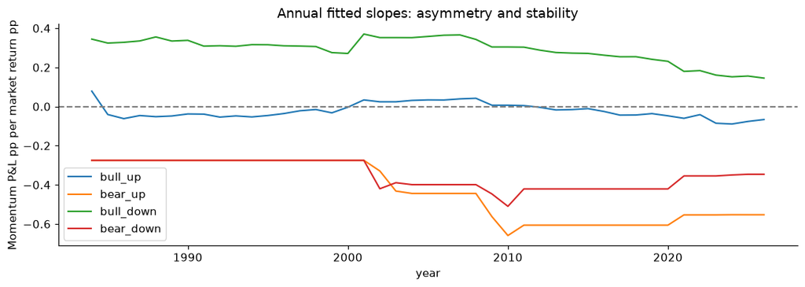

**Calculation code (expand for reproducibility)**

```
last_year = int(evaluation.year.max())
coef, training = fitted_by_year[(last_year, "state_asymmetric")]
scenarios = pd.DataFrame({"bear": [False, False, True, True], "market": [-5., 5., -5., 5.]})
prediction = matrix(scenarios, "state_asymmetric").to_numpy() @ coef
residual = training.mom.to_numpy()-(matrix(training, "state_asymmetric").to_numpy() @ coef)[:, 0]
scenario_table = scenarios.copy()
scenario_table[TARGETS] = prediction
for i, row in scenarios.iterrows():
    group = training.bear.to_numpy() == row.bear
    lo, hi = np.quantile(residual[group], [.05, .95])
    scenario_table.loc[i, "outcome_band_lo"] = prediction[i, 0]+lo
    scenario_table.loc[i, "outcome_band_hi"] = prediction[i, 0]+hi
    scenario_table.loc[i, "nearby_training_weeks"] = int((group & (abs(training.market-row.market) <= 1)).sum())
scenario_table["reconciliation_rounding_pp"] = scenario_table.mom-scenario_table.long-scenario_table.short
assert scenario_table.reconciliation_rounding_pp.abs().max() < .05
display(Markdown(f"Fit uses outcomes through **{training.end.max().date()}**; scenario returns and P&L are in percentage points."))
display(scenario_table)
fig, ax = plt.subplots(figsize=(9, 4))
for b, label in [(False, "Non-bear state"), (True, "Bear state")]:
    support = training.loc[training.bear == b, "market"]
    grid = np.linspace(support.quantile(.025), support.quantile(.975), 100)
    s = pd.DataFrame({"market": grid, "bear": b})
    mean = matrix(s, "state_asymmetric").to_numpy() @ coef
    ax.plot(grid, mean[:, 0], label=label)
ax.axhline(0, color="grey", linewidth=.7); ax.axvline(0, color="grey", linewidth=.7)
ax.set(xlabel="Specified weekly market move (%)", ylabel="Conditional mean momentum P&L (%)",
       title="Scenario curves, limited to each state's central 95% market range")
ax.legend(); plt.tight_layout(); plt.show()
```

|  | bear | market | mom | long | short | outcome_band_lo | outcome_band_hi | nearby_training_weeks | reconciliation_rounding_pp |
| --- | --- | --- | --- | --- | --- | --- | --- | --- | --- |
| 0 | False | -5.0 | -0.4086 | -5.8166 | 5.4069 | -3.0909 | 2.2836 | 44.0 | 0.0010 |
| 1 | False | 5.0 | -0.0153 | 5.1432 | -5.1591 | -2.6976 | 2.6769 | 52.0 | 0.0005 |
| 2 | True | -5.0 | 1.9133 | -4.6635 | 6.5794 | -2.0274 | 5.7017 | 19.0 | -0.0026 |
| 3 | True | 5.0 | -2.5815 | 4.5375 | -7.1187 | -6.5222 | 1.2069 | 17.0 | -0.0003 |

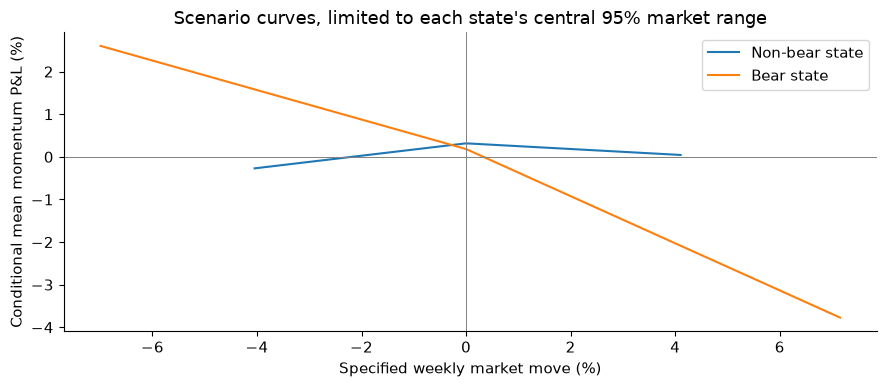

**Calculation code (expand for reproducibility)**

```
rng = np.random.default_rng(20260911)
n = len(training); block = 26
draws = []
for _ in range(1000):
    starts = rng.integers(0, n-block+1, int(np.ceil(n/block)))
    idx = (starts[:, None]+np.arange(block)).ravel()[:n]
    boot = training.iloc[idx]
    if np.linalg.matrix_rank(matrix(boot, "state_asymmetric")) < 6:
        continue
    draws.append(matrix(scenarios, "state_asymmetric").to_numpy() @ fit(boot, "state_asymmetric"))
draws = np.asarray(draws)
lo, hi = np.quantile(draws, [.025, .975], axis=0)
rows = []
for i, row in scenarios.iterrows():
    for j, target in enumerate(TARGETS):
        rows.append({"bear": row.bear, "market": row.market, "contribution": target,
                     "mean": prediction[i, j], "mean_lower95": lo[i, j], "mean_upper95": hi[i, j]})
display(pd.DataFrame(rows))
print("Valid bootstrap fits:", len(draws), "of 1000")
# Pair the same bootstrap draws when comparing states, preserving covariance.
state_gap = draws[:, 3, 0]-draws[:, 1, 0]
display(pd.Series({"bear_minus_nonbear_at_plus5": prediction[3, 0]-prediction[1, 0],
                   "lower95": np.quantile(state_gap, .025), "upper95": np.quantile(state_gap, .975)}))
```

|  | bear | market | contribution | mean | mean_lower95 | mean_upper95 |
| --- | --- | --- | --- | --- | --- | --- |
| 0 | False | -5.0 | mom | -0.4086 | -1.1856 | 0.3581 |
| 1 | False | -5.0 | long | -5.8166 | -6.1081 | -5.5268 |
| 2 | False | -5.0 | short | 5.4069 | 4.8539 | 5.9720 |
| 3 | False | 5.0 | mom | -0.0153 | -0.6000 | 0.5399 |
| 4 | False | 5.0 | long | 5.1432 | 4.8816 | 5.3843 |
| 5 | False | 5.0 | short | -5.1591 | -5.5808 | -4.7531 |
| 6 | True | -5.0 | mom | 1.9133 | 0.3849 | 2.8907 |
| 7 | True | -5.0 | long | -4.6635 | -5.3638 | -4.2509 |
| 8 | True | -5.0 | short | 6.5794 | 5.5123 | 7.4142 |
| 9 | True | 5.0 | mom | -2.5815 | -3.9602 | -1.0855 |
| 10 | True | 5.0 | long | 4.5375 | 3.9890 | 5.2920 |
| 11 | True | 5.0 | short | -7.1187 | -8.3086 | -5.9092 |

**Calculation code (expand for reproducibility)**

```
display(rebound.nsmallest(8, "mom")[["cutoff", "market", "mom", "long", "short", "linear_mom",
                                       "asymmetric_mom", "state_asymmetric_mom", "state_asymmetric_lo", "state_asymmetric_hi"]])
summary = {"last_fit_training_end": str(training.end.max().date()),
           "evaluation_weeks": len(evaluation), "bear_rebound_weeks": len(rebound),
           "overall_metrics": metrics(evaluation).to_dict(orient="index"),
           "rebound_metrics": metrics(rebound).to_dict(orient="index"),
           "scenarios": scenario_table.to_dict(orient="records"),
           "state_gap_plus5": {"estimate": float(prediction[3, 0]-prediction[1, 0]),
                               "lower95": float(np.quantile(state_gap, .025)), "upper95": float(np.quantile(state_gap, .975))},
           "status": "exploratory conditional scenario research; not an unconditional forecast or fresh holdout"}
(ROOT / "scenario_results.json").write_text(json.dumps(summary, indent=2)+"\n")
print("Results saved. No probability of the specified market move has been estimated.")
```

| date | cutoff | market | mom | long | short | linear_mom | asymmetric_mom | state_asymmetric_mom | state_asymmetric_lo | state_asymmetric_hi |
| --- | --- | --- | --- | --- | --- | --- | --- | --- | --- | --- |
| 2008-11-28 | 2008-11-21 | 12.6121 | -16.74 | 10.365 | -27.115 | 0.5749 | -0.8421 | -5.5182 | -8.8854 | -2.8896 |
| 2009-05-08 | 2009-05-01 | 5.6471 | -14.62 | 2.730 | -17.350 | -0.1508 | -0.5894 | -3.0126 | -6.3035 | -0.2354 |
| 2009-03-13 | 2009-03-06 | 10.7079 | -13.28 | 8.230 | -21.505 | -0.4557 | -1.4459 | -5.8587 | -9.1497 | -3.0815 |
| 2009-03-27 | 2009-03-20 | 6.4526 | -9.18 | 5.010 | -14.185 | -0.1994 | -0.7257 | -3.4656 | -6.7565 | -0.6884 |
| 2001-04-20 | 2001-04-12 | 5.3085 | -7.87 | 1.465 | -9.340 | 0.7878 | 0.2054 | -1.5321 | -3.9165 | 0.0723 |
| 2002-11-22 | 2002-11-15 | 2.4101 | -6.83 | 0.765 | -7.590 | 0.3127 | 0.2128 | -0.9770 | -4.0612 | 1.5078 |
| 2001-04-13 | 2001-04-06 | 5.3404 | -6.80 | 3.345 | -10.145 | 0.7916 | 0.2042 | -1.5409 | -3.9252 | 0.0635 |
| 2009-08-07 | 2009-07-31 | 2.4635 | -6.55 | 0.655 | -7.220 | 0.0409 | -0.0507 | -1.2221 | -4.5131 | 1.5550 |

**Calculation code (expand for reproducibility)**

```
diagnostic_samples = {"1974–2016": panel.loc[panel.start.dt.year <= 2016],
                      "2017 onward": panel.loc[panel.start.dt.year >= 2017],
                      "last-fit sample excluding 2008–2009": training.loc[~training.start.dt.year.between(2008, 2009)]}
challenge_rows = []
for label, frame in diagnostic_samples.items():
    estimate = matrix(scenarios, "state_asymmetric").to_numpy() @ fit(frame, "state_asymmetric")
    rng = np.random.default_rng(20260911)
    intervals = []
    # Split at missing calendar buckets rather than splice separated eras.
    group_id = (frame.index.to_series().diff().dt.days.fillna(7) > 7).cumsum()
    segments = [segment for _, segment in frame.groupby(group_id)]
    for _ in range(500):
        pieces = []
        for segment in segments:
            size = len(segment); length = min(26, size)
            starts = rng.integers(0, size-length+1, int(np.ceil(size/length)))
            idx = (starts[:, None]+np.arange(length)).ravel()[:size]
            pieces.append(segment.iloc[idx])
        boot = pd.concat(pieces)
        if np.linalg.matrix_rank(matrix(boot, "state_asymmetric")) < 6:
            continue
        result = matrix(scenarios, "state_asymmetric").to_numpy() @ fit(boot, "state_asymmetric")
        intervals.append(result[3, 0]-result[1, 0])
    challenge_rows.append({"sample": label, "weeks": len(frame), "bear_weeks": int(frame.bear.sum()),
                          "bear_plus5_nearby": int((frame.bear & frame.market.between(4, 6)).sum()),
                          "bear_plus5_mean": estimate[3, 0], "nonbear_plus5_mean": estimate[1, 0],
                          "state_gap": estimate[3, 0]-estimate[1, 0],
                          "gap_lower95": np.quantile(intervals, .025), "gap_upper95": np.quantile(intervals, .975),
                          "long_gap": estimate[3, 1]-estimate[1, 1], "short_gap": estimate[3, 2]-estimate[1, 2],
                          "valid_bootstrap_fits": len(intervals)})
challenge = pd.DataFrame(challenge_rows).set_index("sample")
display(challenge)
summary["challenge_tests"] = challenge.reset_index().to_dict(orient="records")
(ROOT / "scenario_results.json").write_text(json.dumps(summary, indent=2)+"\n")
```

| sample | weeks | bear_weeks | bear_plus5_nearby | bear_plus5_mean | nonbear_plus5_mean | state_gap | gap_lower95 | gap_upper95 | long_gap | short_gap | valid_bootstrap_fits |
| --- | --- | --- | --- | --- | --- | --- | --- | --- | --- | --- | --- |
| 1974–2016 | 2243 | 337 | 16 | -2.9034 | 0.1575 | -3.0609 | -4.7261 | -1.3610 | -0.8541 | -2.2060 | 500 |
| 2017 onward | 499 | 37 | 1 | -0.7861 | -0.5953 | -0.1908 | -2.9834 | 1.2145 | 0.6719 | -0.8603 | 483 |
| last-fit sample excluding 2008–2009 | 2609 | 308 | 12 | -1.5330 | 0.0828 | -1.6158 | -2.7574 | -0.7125 | -0.5641 | -1.0515 | 500 |

## E03. Literature model and positioning comparison

**Calculation code (expand for reproducibility)**

```
from pathlib import Path
import os, sys, json, inspect
os.environ.setdefault("OMP_NUM_THREADS", "1")
os.environ.setdefault("OPENBLAS_NUM_THREADS", "1")
os.environ.setdefault("VECLIB_MAXIMUM_THREADS", "1")
ROOT = Path.cwd()
sys.path.insert(0, str(ROOT / "scripts"))
import numpy as np
import pandas as pd
import matplotlib.pyplot as plt
from IPython.display import display, Markdown
from expanded_research import run, scores, paired, self_tests, THRESHOLD, OUT
results = run()  # Uses source-fingerprinted caches; uncached execution performs all fits.
pred = results["predictions"]
pd.set_option("display.max_columns", 12)
pd.set_option("display.precision", 5)
plt.rcParams.update({"figure.figsize": (11, 4), "axes.spines.top": False, "axes.spines.right": False})
print(self_tests())
print(f"Common evaluation: {pred.start.min().date()} to {pred.end.max().date()}, {len(pred)} weekly outcomes, {pred.event.sum()} severe losses.")
assert pred.filter(regex=r"^(p_|q_)").notna().all().all()
assert (pred.cutoff < pred.start).all()
```

**Calculation code (expand for reproducibility)**

```
probability, tails = scores(pred)
display(probability.sort_values("logloss"))
eras = {"1984–2016": pred.loc[pred.start.dt.year <= 2016],
        "2017 onward — already examined": pred.loc[pred.start.dt.year >= 2017],
        "Excluding 2008–2009": pred.loc[~pred.start.dt.year.between(2008, 2009)]}
display(pd.concat({name: scores(frame)[0] for name, frame in eras.items()}, names=["sample"]))
comparisons = [("fhs_ewma", "logit_rv126", "logloss"), ("fhs_ewma", "logit_rv126", "brier"),
               ("fhs_garch_t", "fhs_ewma", "logloss"), ("garch_t", "logit_rv126", "logloss"),
               ("hmm_heavy", "logit_rv126", "logloss")]
display(pd.DataFrame([paired(pred, a, b, k, block) for a,b,k in comparisons for block in [13,26]]))
```

| model | weeks | events | brier | logloss | predicted_rate | observed_rate |
| --- | --- | --- | --- | --- | --- | --- |
| fhs_ewma | 2221 | 205 | 0.07536 | 0.26319 | 0.09540 | 0.0923 |
| fhs5y_ewma | 2221 | 205 | 0.07544 | 0.26376 | 0.08615 | 0.0923 |
| logit_ewma | 2221 | 205 | 0.07591 | 0.26428 | 0.10917 | 0.0923 |
| fhs_garch_t | 2221 | 205 | 0.07559 | 0.26459 | 0.09081 | 0.0923 |
| fhs_gjr_t | 2221 | 205 | 0.07565 | 0.26480 | 0.09048 | 0.0923 |
| fhs5y_garch_t | 2221 | 205 | 0.07578 | 0.26511 | 0.08620 | 0.0923 |
| logit_garch_t | 2221 | 205 | 0.07586 | 0.26527 | 0.10807 | 0.0923 |
| logit_gjr_t | 2221 | 205 | 0.07584 | 0.26527 | 0.10766 | 0.0923 |
| garch_normal | 2221 | 205 | 0.07519 | 0.26713 | 0.07966 | 0.0923 |
| garch_t | 2221 | 205 | 0.07539 | 0.26736 | 0.07658 | 0.0923 |
| gjr_t | 2221 | 205 | 0.07543 | 0.26740 | 0.07663 | 0.0923 |
| logit_rv126 | 2221 | 205 | 0.07639 | 0.27046 | 0.10369 | 0.0923 |
| fhs_rv126 | 2221 | 205 | 0.07668 | 0.27135 | 0.09582 | 0.0923 |
| hmm_normal | 2221 | 205 | 0.07860 | 0.27995 | 0.08084 | 0.0923 |
| hmm_heavy | 2221 | 205 | 0.08029 | 0.28796 | 0.06324 | 0.0923 |
| frequency | 2221 | 205 | 0.08423 | 0.31125 | 0.06458 | 0.0923 |
| rolling_frequency | 2221 | 205 | 0.08556 | 0.31577 | 0.08843 | 0.0923 |

| sample | model | weeks | events | brier | logloss | predicted_rate | observed_rate |
| --- | --- | --- | --- | --- | --- | --- | --- |
| 1984–2016 | garch_normal | 1722 | 144 | 0.06777 | 0.24566 | 0.06296 | 0.08362 |
|  | garch_t | 1722 | 144 | 0.06801 | 0.24571 | 0.06025 | 0.08362 |
|  | gjr_t | 1722 | 144 | 0.06806 | 0.24581 | 0.06025 | 0.08362 |
|  | frequency | 1722 | 144 | 0.07703 | 0.29080 | 0.05996 | 0.08362 |
|  | rolling_frequency | 1722 | 144 | 0.07886 | 0.29794 | 0.08332 | 0.08362 |
|  | logit_rv126 | 1722 | 144 | 0.06882 | 0.24831 | 0.08969 | 0.08362 |
|  | fhs_rv126 | 1722 | 144 | 0.06948 | 0.24968 | 0.08221 | 0.08362 |
|  | logit_ewma | 1722 | 144 | 0.06804 | 0.24058 | 0.09505 | 0.08362 |
|  | fhs_ewma | 1722 | 144 | 0.06800 | 0.24018 | 0.08081 | 0.08362 |
|  | fhs5y_ewma | 1722 | 144 | 0.06822 | 0.24201 | 0.07529 | 0.08362 |
|  | logit_garch_t | 1722 | 144 | 0.06781 | 0.24097 | 0.09350 | 0.08362 |
|  | fhs_garch_t | 1722 | 144 | 0.06821 | 0.24155 | 0.07637 | 0.08362 |
|  | fhs5y_garch_t | 1722 | 144 | 0.06852 | 0.24285 | 0.07496 | 0.08362 |
|  | logit_gjr_t | 1722 | 144 | 0.06782 | 0.24104 | 0.09303 | 0.08362 |
|  | fhs_gjr_t | 1722 | 144 | 0.06829 | 0.24181 | 0.07601 | 0.08362 |
|  | hmm_normal | 1722 | 144 | 0.07127 | 0.25690 | 0.06975 | 0.08362 |
|  | hmm_heavy | 1722 | 144 | 0.07343 | 0.26813 | 0.05287 | 0.08362 |
| 2017 onward — already examined | garch_normal | 499 | 61 | 0.10076 | 0.34125 | 0.13726 | 0.12224 |
|  | garch_t | 499 | 61 | 0.10088 | 0.34209 | 0.13290 | 0.12224 |
|  | gjr_t | 499 | 61 | 0.10085 | 0.34189 | 0.13314 | 0.12224 |
|  | frequency | 499 | 61 | 0.10906 | 0.38183 | 0.08053 | 0.12224 |
|  | rolling_frequency | 499 | 61 | 0.10867 | 0.37727 | 0.10607 | 0.12224 |
|  | logit_rv126 | 499 | 61 | 0.10249 | 0.34689 | 0.15200 | 0.12224 |
|  | fhs_rv126 | 499 | 61 | 0.10151 | 0.34615 | 0.14282 | 0.12224 |
|  | logit_ewma | 499 | 61 | 0.10307 | 0.34608 | 0.15787 | 0.12224 |
|  | fhs_ewma | 499 | 61 | 0.10074 | 0.34257 | 0.14572 | 0.12224 |
|  | fhs5y_ewma | 499 | 61 | 0.10034 | 0.33881 | 0.12362 | 0.12224 |
|  | logit_garch_t | 499 | 61 | 0.10364 | 0.34911 | 0.15833 | 0.12224 |
|  | fhs_garch_t | 499 | 61 | 0.10106 | 0.34411 | 0.14066 | 0.12224 |
|  | fhs5y_garch_t | 499 | 61 | 0.10085 | 0.34192 | 0.12499 | 0.12224 |
|  | logit_gjr_t | 499 | 61 | 0.10353 | 0.34887 | 0.15816 | 0.12224 |
|  | fhs_gjr_t | 499 | 61 | 0.10107 | 0.34416 | 0.14043 | 0.12224 |
|  | hmm_normal | 499 | 61 | 0.10389 | 0.35949 | 0.11908 | 0.12224 |
|  | hmm_heavy | 499 | 61 | 0.10397 | 0.35640 | 0.09902 | 0.12224 |
| Excluding 2008–2009 | garch_normal | 2117 | 170 | 0.06843 | 0.24948 | 0.07212 | 0.08030 |
|  | garch_t | 2117 | 170 | 0.06860 | 0.24972 | 0.06924 | 0.08030 |
|  | gjr_t | 2117 | 170 | 0.06862 | 0.24973 | 0.06926 | 0.08030 |
|  | frequency | 2117 | 170 | 0.07387 | 0.27989 | 0.06443 | 0.08030 |
|  | rolling_frequency | 2117 | 170 | 0.07571 | 0.28762 | 0.08872 | 0.08030 |
|  | logit_rv126 | 2117 | 170 | 0.07041 | 0.25516 | 0.09332 | 0.08030 |
|  | fhs_rv126 | 2117 | 170 | 0.06962 | 0.25371 | 0.08912 | 0.08030 |
|  | logit_ewma | 2117 | 170 | 0.06999 | 0.24894 | 0.09798 | 0.08030 |
|  | fhs_ewma | 2117 | 170 | 0.06840 | 0.24561 | 0.08880 | 0.08030 |
|  | fhs5y_ewma | 2117 | 170 | 0.06853 | 0.24629 | 0.07885 | 0.08030 |
|  | logit_garch_t | 2117 | 170 | 0.06980 | 0.24939 | 0.09718 | 0.08030 |
|  | fhs_garch_t | 2117 | 170 | 0.06848 | 0.24632 | 0.08477 | 0.08030 |
|  | fhs5y_garch_t | 2117 | 170 | 0.06864 | 0.24637 | 0.07958 | 0.08030 |
|  | logit_gjr_t | 2117 | 170 | 0.06979 | 0.24938 | 0.09682 | 0.08030 |
|  | fhs_gjr_t | 2117 | 170 | 0.06853 | 0.24653 | 0.08443 | 0.08030 |
|  | hmm_normal | 2117 | 170 | 0.07062 | 0.25993 | 0.07587 | 0.08030 |
|  | hmm_heavy | 2117 | 170 | 0.07122 | 0.26412 | 0.06039 | 0.08030 |

|  | candidate | base | score | block | difference | lower95 | upper95 |
| --- | --- | --- | --- | --- | --- | --- | --- |
| 0 | fhs_ewma | logit_rv126 | logloss | 13 | -0.00727 | -0.01312 | -0.00097 |
| 1 | fhs_ewma | logit_rv126 | logloss | 26 | -0.00727 | -0.01421 | -0.00032 |
| 2 | fhs_ewma | logit_rv126 | brier | 13 | -0.00103 | -0.00278 | 0.00102 |
| 3 | fhs_ewma | logit_rv126 | brier | 26 | -0.00103 | -0.00332 | 0.00133 |
| 4 | fhs_garch_t | fhs_ewma | logloss | 13 | 0.00140 | -0.00125 | 0.00410 |
| 5 | fhs_garch_t | fhs_ewma | logloss | 26 | 0.00140 | -0.00126 | 0.00427 |
| 6 | garch_t | logit_rv126 | logloss | 13 | -0.00309 | -0.01196 | 0.00670 |
| 7 | garch_t | logit_rv126 | logloss | 26 | -0.00309 | -0.01337 | 0.00769 |
| 8 | hmm_heavy | logit_rv126 | logloss | 13 | 0.01751 | 0.00346 | 0.03363 |
| 9 | hmm_heavy | logit_rv126 | logloss | 26 | 0.01751 | 0.00210 | 0.03488 |

**Calculation code (expand for reproducibility)**

```
def simultaneous(frame, prefix, base, loss_kind):
    names = [c[len(prefix):] for c in frame if c.startswith(prefix) and c != prefix+base]
    def loss(name):
        if prefix == "p_":
            p = np.clip(frame[prefix+name].to_numpy(), 1e-8, 1-1e-8)
            y = frame.event.astype(int).to_numpy()
            return -(y*np.log(p)+(1-y)*np.log1p(-p))
        u = frame.y.to_numpy()-frame[prefix+name].to_numpy()
        return np.maximum(.05*u, -.95*u)
    d = np.column_stack([loss(name)-loss(base) for name in names])
    n = len(d); rng = np.random.default_rng(20260911); boot = []
    for _ in range(2000):
        starts = rng.integers(0, n-13+1, int(np.ceil(n/13)))
        idx = (starts[:,None]+np.arange(13)).ravel()[:n]
        boot.append(d[idx].mean(axis=0))
    boot = np.asarray(boot); means = d.mean(axis=0); se = boot.std(axis=0, ddof=1)
    critical = np.quantile(np.max(abs((boot-boot.mean(axis=0))/np.maximum(se,1e-12)), axis=1), .95)
    return pd.DataFrame({"difference": means, "simultaneous_lower95": means-critical*se,
                         "simultaneous_upper95": means+critical*se}, index=names)
display(simultaneous(pred, "p_", "logit_rv126", "logloss").sort_values("difference"))
display(Markdown("**Probability calibration by fixed bins; counts matter**"))
calibration = {}
for name in ["logit_rv126", "fhs5y_ewma", "fhs_ewma", "fhs_garch_t", "garch_t", "hmm_heavy"]:
    f = pred.assign(bin=pd.cut(pred["p_"+name], [0,.025,.05,.1,.2,1], include_lowest=True))
    calibration[name] = f.groupby("bin", observed=False).agg(weeks=("event","size"), events=("event","sum"),
                               mean_prediction=("p_"+name,"mean"), realized_rate=("event","mean"))
display(pd.concat(calibration, names=["model"]))
```

|  | difference | simultaneous_lower95 | simultaneous_upper95 |
| --- | --- | --- | --- |
| fhs_ewma | -0.00727 | -0.01573 | 0.00119 |
| fhs5y_ewma | -0.00670 | -0.01604 | 0.00264 |
| logit_ewma | -0.00617 | -0.01477 | 0.00242 |
| fhs_garch_t | -0.00587 | -0.01587 | 0.00414 |
| fhs_gjr_t | -0.00565 | -0.01567 | 0.00436 |
| fhs5y_garch_t | -0.00535 | -0.01639 | 0.00569 |
| logit_garch_t | -0.00519 | -0.01606 | 0.00568 |
| logit_gjr_t | -0.00519 | -0.01598 | 0.00560 |
| garch_normal | -0.00333 | -0.01682 | 0.01017 |
| garch_t | -0.00309 | -0.01623 | 0.01005 |
| gjr_t | -0.00306 | -0.01619 | 0.01007 |
| fhs_rv126 | 0.00090 | -0.00488 | 0.00667 |
| hmm_normal | 0.00949 | -0.00739 | 0.02637 |
| hmm_heavy | 0.01751 | -0.00289 | 0.03790 |
| frequency | 0.04080 | 0.01153 | 0.07007 |
| rolling_frequency | 0.04531 | 0.01915 | 0.07147 |

| model | bin | weeks | events | mean_prediction | realized_rate |
| --- | --- | --- | --- | --- | --- |
| logit_rv126 | (-0.001, 0.025] | 244 | 4 | 0.01870 | 0.01639 |
|  | (0.025, 0.05] | 537 | 17 | 0.03646 | 0.03166 |
|  | (0.05, 0.1] | 669 | 42 | 0.07041 | 0.06278 |
|  | (0.1, 0.2] | 499 | 67 | 0.14403 | 0.13427 |
|  | (0.2, 1.0] | 272 | 75 | 0.32051 | 0.27574 |
| fhs5y_ewma | (-0.001, 0.025] | 545 | 7 | 0.01305 | 0.01284 |
|  | (0.025, 0.05] | 427 | 16 | 0.03677 | 0.03747 |
|  | (0.05, 0.1] | 475 | 33 | 0.07277 | 0.06947 |
|  | (0.1, 0.2] | 546 | 79 | 0.14082 | 0.14469 |
|  | (0.2, 1.0] | 228 | 70 | 0.25034 | 0.30702 |
| fhs_ewma | (-0.001, 0.025] | 374 | 2 | 0.01171 | 0.00535 |
|  | (0.025, 0.05] | 443 | 11 | 0.03742 | 0.02483 |
|  | (0.05, 0.1] | 573 | 38 | 0.07286 | 0.06632 |
|  | (0.1, 0.2] | 578 | 76 | 0.14663 | 0.13149 |
|  | (0.2, 1.0] | 253 | 78 | 0.25460 | 0.30830 |
| fhs_garch_t | (-0.001, 0.025] | 362 | 2 | 0.01644 | 0.00552 |
|  | (0.025, 0.05] | 544 | 18 | 0.03508 | 0.03309 |
|  | (0.05, 0.1] | 530 | 33 | 0.07310 | 0.06226 |
|  | (0.1, 0.2] | 556 | 82 | 0.14425 | 0.14748 |
|  | (0.2, 1.0] | 229 | 70 | 0.25204 | 0.30568 |
| garch_t | (-0.001, 0.025] | 907 | 18 | 0.00950 | 0.01985 |
|  | (0.025, 0.05] | 296 | 25 | 0.03618 | 0.08446 |
|  | (0.05, 0.1] | 362 | 24 | 0.07161 | 0.06630 |
|  | (0.1, 0.2] | 418 | 67 | 0.14430 | 0.16029 |
|  | (0.2, 1.0] | 238 | 71 | 0.27105 | 0.29832 |
| hmm_heavy | (-0.001, 0.025] | 946 | 29 | 0.01240 | 0.03066 |
|  | (0.025, 0.05] | 188 | 8 | 0.03657 | 0.04255 |
|  | (0.05, 0.1] | 469 | 53 | 0.07844 | 0.11301 |
|  | (0.1, 0.2] | 618 | 115 | 0.13762 | 0.18608 |
|  | (0.2, 1.0] | 0 | 0 | NaN | NaN |

**Calculation code (expand for reproducibility)**

```
from scipy.stats import chi2
def dq_screen(frame, name):
    hit = (frame.y < frame["q_"+name]).astype(float)-.05
    x = pd.DataFrame({"constant": 1., "q": frame["q_"+name]})
    for lag in range(1,5): x[f"hit_lag{lag}"] = hit.shift(lag)
    keep = x.notna().all(axis=1); a = x.loc[keep].to_numpy(); h = hit.loc[keep].to_numpy()
    rank = np.linalg.matrix_rank(a)
    fitted = a @ np.linalg.lstsq(a, h, rcond=None)[0]
    statistic = float(fitted@fitted/(.05*.95))
    return chi2.sf(statistic, rank)
tails["DQ_asymptotic_p"] = [dq_screen(pred, name) for name in tails.index]
display(tails.sort_values("pinball"))
display(pd.concat({name: scores(frame)[1] for name, frame in eras.items()}, names=["sample"]))
display(pd.DataFrame([paired(pred,a,b,"pinball",block) for a,b in [
    ("fhs_garch_t","fhs_rv126"), ("fhs_garch_t","fhs_ewma"), ("caviar_sav","fhs_rv126"),
    ("qr_state","historical")] for block in [13,26]]))
display(simultaneous(pred, "q_", "fhs_rv126", "pinball").sort_values("difference"))
fig, axes = plt.subplots(1,2,figsize=(13,4))
selected = ["historical","fhs_rv126","fhs5y_ewma","fhs5y_garch_t","fhs_ewma","fhs_garch_t","garch_t","qr_state","caviar_sav","hmm_heavy"]
tails.loc[selected,"pinball"].plot.barh(ax=axes[0], color="#315b7c")
recent = scores(eras["2017 onward — already examined"])[1]
recent.loc[selected,"breach_rate"].plot.barh(ax=axes[1], color="#ba6b45")
axes[1].axvline(.05,color="black",linestyle="--")
axes[0].set_title("Full-period quantile loss: lower is better")
axes[1].set_title("Recent breach frequency: target 5%")
plt.tight_layout(); plt.show()
```

| model | pinball | breach_rate | breach_weeks | breach_runs | mean_q05_pp | DQ_asymptotic_p |
| --- | --- | --- | --- | --- | --- | --- |
| fhs5y_garch_t | 0.21466 | 0.05223 | 116 | 108 | -2.92242 | 9.25568e-01 |
| fhs_gjr_t | 0.21542 | 0.04412 | 98 | 92 | -3.14674 | 8.09692e-01 |
| fhs5y_ewma | 0.21553 | 0.05223 | 116 | 108 | -2.91795 | 9.08368e-01 |
| fhs_garch_t | 0.21556 | 0.04367 | 97 | 91 | -3.16804 | 7.95591e-01 |
| garch_normal | 0.21733 | 0.06303 | 140 | 127 | -2.63278 | 5.91377e-02 |
| gjr_t | 0.21812 | 0.06619 | 147 | 133 | -2.57655 | 8.35390e-03 |
| garch_t | 0.21812 | 0.06529 | 145 | 132 | -2.58465 | 2.80754e-02 |
| fhs_ewma | 0.21923 | 0.04052 | 90 | 83 | -3.36599 | 1.36542e-01 |
| caviar_sav | 0.22289 | 0.05718 | 127 | 120 | -2.91793 | 7.34592e-01 |
| caviar_as | 0.22350 | 0.05763 | 128 | 120 | -2.86890 | 4.60947e-01 |
| qr_state | 0.22958 | 0.04953 | 110 | 96 | -2.87104 | 9.91393e-06 |
| qr_vol | 0.23426 | 0.04998 | 111 | 100 | -2.91648 | 1.34518e-03 |
| fhs_rv126 | 0.23479 | 0.04277 | 95 | 85 | -3.38964 | 8.92324e-03 |
| hmm_normal | 0.24534 | 0.06979 | 155 | 138 | -2.61806 | 1.03047e-07 |
| hmm_heavy | 0.25665 | 0.07924 | 176 | 156 | -2.39083 | 1.22417e-14 |
| historical | 0.28435 | 0.07024 | 156 | 123 | -2.55582 | 1.23749e-39 |

| sample | model | pinball | breach_rate | breach_weeks | breach_runs | mean_q05_pp |
| --- | --- | --- | --- | --- | --- | --- |
| 1984–2016 | garch_normal | 0.20404 | 0.06852 | 118 | 106 | -2.33133 |
|  | garch_t | 0.20484 | 0.07085 | 122 | 110 | -2.28231 |
|  | gjr_t | 0.20475 | 0.07143 | 123 | 110 | -2.27646 |
|  | historical | 0.27543 | 0.06969 | 120 | 90 | -2.43440 |
|  | fhs_rv126 | 0.21942 | 0.04820 | 83 | 73 | -3.04366 |
|  | fhs_ewma | 0.20155 | 0.04646 | 80 | 74 | -3.00870 |
|  | fhs5y_ewma | 0.20196 | 0.05401 | 93 | 86 | -2.74024 |
|  | fhs_garch_t | 0.19886 | 0.04762 | 82 | 77 | -2.82026 |
|  | fhs5y_garch_t | 0.20052 | 0.05285 | 91 | 85 | -2.72675 |
|  | fhs_gjr_t | 0.19879 | 0.04820 | 83 | 78 | -2.79961 |
|  | qr_vol | 0.22129 | 0.05052 | 87 | 76 | -2.68482 |
|  | qr_state | 0.22019 | 0.04820 | 83 | 71 | -2.73290 |
|  | caviar_sav | 0.20745 | 0.05749 | 99 | 94 | -2.73931 |
|  | caviar_as | 0.20835 | 0.06039 | 104 | 97 | -2.66494 |
|  | hmm_normal | 0.23421 | 0.07085 | 122 | 106 | -2.39172 |
|  | hmm_heavy | 0.24658 | 0.08188 | 141 | 123 | -2.17931 |
| 2017 onward — already examined | garch_normal | 0.26320 | 0.04409 | 22 | 21 | -3.67308 |
|  | garch_t | 0.26397 | 0.04609 | 23 | 22 | -3.62799 |
|  | gjr_t | 0.26423 | 0.04810 | 24 | 23 | -3.61214 |
|  | historical | 0.31515 | 0.07214 | 36 | 33 | -2.97482 |
|  | fhs_rv126 | 0.28784 | 0.02405 | 12 | 12 | -4.58358 |
|  | fhs_ewma | 0.28024 | 0.02004 | 10 | 9 | -4.59896 |
|  | fhs5y_ewma | 0.26234 | 0.04609 | 23 | 22 | -3.53121 |
|  | fhs_garch_t | 0.27321 | 0.03006 | 15 | 14 | -4.36821 |
|  | fhs5y_garch_t | 0.26346 | 0.05010 | 25 | 23 | -3.59768 |
|  | fhs_gjr_t | 0.27281 | 0.03006 | 15 | 14 | -4.34465 |
|  | qr_vol | 0.27902 | 0.04810 | 24 | 24 | -3.71593 |
|  | qr_state | 0.26197 | 0.05411 | 27 | 25 | -3.34774 |
|  | caviar_sav | 0.27615 | 0.05611 | 28 | 26 | -3.53433 |
|  | caviar_as | 0.27577 | 0.04810 | 24 | 23 | -3.57276 |
|  | hmm_normal | 0.28373 | 0.06613 | 33 | 32 | -3.39912 |
|  | hmm_heavy | 0.29141 | 0.07014 | 35 | 33 | -3.12075 |
| Excluding 2008–2009 | garch_normal | 0.20220 | 0.06141 | 130 | 117 | -2.46090 |
|  | garch_t | 0.20316 | 0.06377 | 135 | 122 | -2.41706 |
|  | gjr_t | 0.20325 | 0.06471 | 137 | 123 | -2.41054 |
|  | historical | 0.24574 | 0.05952 | 126 | 107 | -2.55241 |
|  | fhs_rv126 | 0.21753 | 0.04157 | 88 | 79 | -3.14413 |
|  | fhs_ewma | 0.20549 | 0.04015 | 85 | 78 | -3.12723 |
|  | fhs5y_ewma | 0.20158 | 0.05243 | 111 | 103 | -2.64800 |
|  | fhs_garch_t | 0.20231 | 0.04204 | 89 | 83 | -2.96186 |
|  | fhs5y_garch_t | 0.20213 | 0.05102 | 108 | 100 | -2.67706 |
|  | fhs_gjr_t | 0.20229 | 0.04251 | 90 | 84 | -2.94188 |
|  | qr_vol | 0.21548 | 0.04865 | 103 | 93 | -2.76983 |
|  | qr_state | 0.21173 | 0.04818 | 102 | 89 | -2.72062 |
|  | caviar_sav | 0.20755 | 0.05668 | 120 | 114 | -2.71933 |
|  | caviar_as | 0.20878 | 0.05668 | 120 | 113 | -2.69175 |
|  | hmm_normal | 0.22052 | 0.06519 | 138 | 128 | -2.53673 |
|  | hmm_heavy | 0.22721 | 0.07369 | 156 | 143 | -2.33395 |

|  | candidate | base | score | block | difference | lower95 | upper95 |
| --- | --- | --- | --- | --- | --- | --- | --- |
| 0 | fhs_garch_t | fhs_rv126 | pinball | 13 | -0.01923 | -0.02982 | -0.01022 |
| 1 | fhs_garch_t | fhs_rv126 | pinball | 26 | -0.01923 | -0.03088 | -0.01034 |
| 2 | fhs_garch_t | fhs_ewma | pinball | 13 | -0.00367 | -0.00767 | 0.00043 |
| 3 | fhs_garch_t | fhs_ewma | pinball | 26 | -0.00367 | -0.00783 | 0.00027 |
| 4 | caviar_sav | fhs_rv126 | pinball | 13 | -0.01190 | -0.02066 | -0.00341 |
| 5 | caviar_sav | fhs_rv126 | pinball | 26 | -0.01190 | -0.02003 | -0.00367 |
| 6 | qr_state | historical | pinball | 13 | -0.05477 | -0.08952 | -0.02840 |
| 7 | qr_state | historical | pinball | 26 | -0.05477 | -0.09351 | -0.02598 |

|  | difference | simultaneous_lower95 | simultaneous_upper95 |
| --- | --- | --- | --- |
| fhs5y_garch_t | -0.02013 | -0.03362 | -0.00664 |
| fhs_gjr_t | -0.01937 | -0.03263 | -0.00610 |
| fhs5y_ewma | -0.01926 | -0.03068 | -0.00785 |
| fhs_garch_t | -0.01923 | -0.03266 | -0.00580 |
| garch_normal | -0.01746 | -0.03048 | -0.00444 |
| gjr_t | -0.01667 | -0.03007 | -0.00328 |
| garch_t | -0.01667 | -0.03012 | -0.00321 |
| fhs_ewma | -0.01556 | -0.02747 | -0.00364 |
| caviar_sav | -0.01190 | -0.02363 | -0.00018 |
| caviar_as | -0.01129 | -0.02325 | 0.00067 |
| qr_state | -0.00521 | -0.01642 | 0.00599 |
| qr_vol | -0.00053 | -0.01243 | 0.01138 |
| hmm_normal | 0.01055 | -0.01555 | 0.03664 |
| hmm_heavy | 0.02186 | -0.01191 | 0.05564 |
| historical | 0.04956 | 0.00290 | 0.09623 |

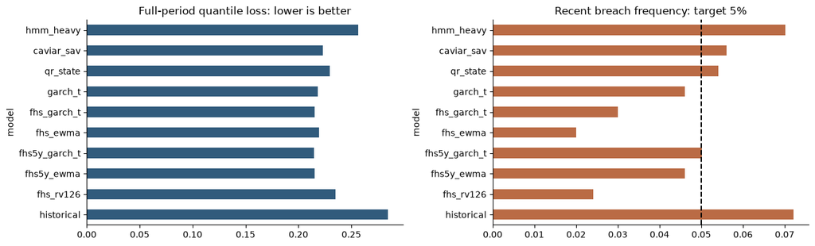

**Calculation code (expand for reproducibility)**

```
display(results["hmm_audit"].groupby("model").agg(fits=("year","size"),
            converged_to_tolerance=("converged","sum"), min_duration=("turbulent_duration_weeks","min"),
            max_duration=("turbulent_duration_weeks","max")))
display(results["volatility_audit"].groupby("model").agg(fits=("year","size"), converged=("converged","sum"),
            max_persistence=("persistence","max")))
display(pd.DataFrame({"hmm_normal": pred.risk_state_hmm_normal.describe(),
                      "hmm_heavy": pred.risk_state_hmm_heavy.describe()}))
fig,ax=plt.subplots(figsize=(12,3.5))
recent_mask=pred.start.dt.year>=2000
ax.plot(pred.loc[recent_mask,"end"],pred.loc[recent_mask,"risk_state_hmm_heavy"],linewidth=.8)
ax.set(ylabel="Next-week turbulent-state probability",title="Heavy-tailed HMM: an inferred state is not a crash probability")
plt.tight_layout(); plt.show()
```

| model | fits | converged_to_tolerance | min_duration | max_duration |
| --- | --- | --- | --- | --- |
| hmm_heavy | 43 | 43 | 16.0228 | 40.09094 |
| hmm_normal | 43 | 43 | 7.0515 | 20.61841 |

| model | fits | converged | max_persistence |
| --- | --- | --- | --- |
| garch_normal | 53 | 53 | 1.0 |
| garch_t | 53 | 53 | 1.0 |
| gjr_t | 53 | 53 | 1.0 |

|  | hmm_normal | hmm_heavy |
| --- | --- | --- |
| count | 2221.00000 | 2221.00000 |
| mean | 0.35518 | 0.46090 |
| std | 0.36390 | 0.39376 |
| min | 0.02295 | 0.02026 |
| 25% | 0.05324 | 0.06215 |
| 50% | 0.11682 | 0.34663 |
| 75% | 0.77322 | 0.90916 |
| max | 0.95150 | 0.97441 |

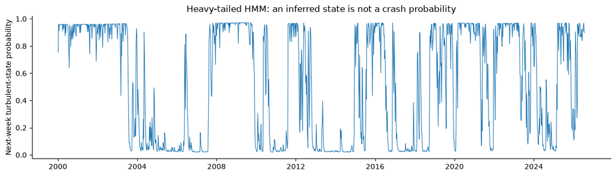

**Calculation code (expand for reproducibility)**

```
position_file=OUT/"positioning.pkl"
if not position_file.exists():
    from positioning_research import run as run_positioning
    positions=run_positioning()
else: positions=pd.read_pickle(position_file)
display(pd.concat({f"{lag}-day assumed lag": scores(frame)[0]
                   for lag,frame in positions.groupby("assumed_lag_days")},names=["timing assumption"]))
display(pd.DataFrame([paired(frame,"position_proxy","proxy_baseline",kind)
    for lag,frame in positions.groupby("assumed_lag_days") for kind in ["brier","logloss"]]))
```

| timing assumption | model | weeks | events | brier | logloss | predicted_rate | observed_rate |
| --- | --- | --- | --- | --- | --- | --- | --- |
| 14-day assumed lag | proxy_baseline | 760 | 78 | 0.08828 | 0.30557 | 0.11068 | 0.10263 |
|  | position_proxy | 760 | 78 | 0.08943 | 0.31106 | 0.10608 | 0.10263 |
| 28-day assumed lag | proxy_baseline | 760 | 78 | 0.08828 | 0.30550 | 0.11136 | 0.10263 |
|  | position_proxy | 760 | 78 | 0.08925 | 0.31178 | 0.10349 | 0.10263 |

|  | candidate | base | score | block | difference | lower95 | upper95 |
| --- | --- | --- | --- | --- | --- | --- | --- |
| 0 | position_proxy | proxy_baseline | brier | 13 | 0.00115 | -0.00012 | 0.00258 |
| 1 | position_proxy | proxy_baseline | logloss | 13 | 0.00548 | -0.00004 | 0.01178 |
| 2 | position_proxy | proxy_baseline | brier | 13 | 0.00098 | -0.00044 | 0.00191 |
| 3 | position_proxy | proxy_baseline | logloss | 13 | 0.00629 | -0.00090 | 0.00859 |

**Calculation code (expand for reproducibility)**

```
display(results["scaling"])
display(Markdown("A regime model can help an exposure-reduction rule while producing worse crash probabilities. These objectives must be evaluated separately."))
```

| rule | weeks | mean_weight | weekly_mean_pp | annualized_mean_sd | worst_week_pp | q05_pp | max_fixed_notional_drawdown_pp | illustrative_cost_mean_pp | average_overlay_change |
| --- | --- | --- | --- | --- | --- | --- | --- | --- | --- |
| unscaled | 1960 | 1.00000 | 0.13111 | 0.42671 | -16.74000 | -3.32100 | -93.80000 | 0.13111 | 0.00000 |
| constant_50pct | 1960 | 0.50000 | 0.06555 | 0.42671 | -8.37000 | -1.66050 | -46.90000 | 0.06555 | 0.00000 |
| vol_target_rv126 | 1960 | 0.87016 | 0.15243 | 0.71690 | -9.72812 | -2.35650 | -31.86157 | 0.15182 | 0.00611 |
| vol_target_ewma | 1960 | 0.87582 | 0.15682 | 0.76736 | -8.66000 | -2.33052 | -33.23606 | 0.15485 | 0.01972 |
| vol_target_garch_t | 1960 | 0.88018 | 0.15722 | 0.76235 | -8.66000 | -2.37740 | -33.47668 | 0.15355 | 0.03671 |
| vol_target_gjr_t | 1960 | 0.88039 | 0.15699 | 0.76091 | -8.66000 | -2.37050 | -33.63070 | 0.15342 | 0.03568 |
| hmm_reduce | 1960 | 0.52774 | 0.09222 | 0.83651 | -4.17551 | -1.18309 | -13.21406 | 0.08443 | 0.07792 |
| mean_variance_reduce | 1960 | 0.82724 | 0.16406 | 0.89866 | -7.10000 | -2.16050 | -24.43326 | 0.16030 | 0.03755 |

**Calculation code (expand for reproducibility)**

```
from expanded_research import data
from risk_core import MomentumRiskCore, verify_replay
print(inspect.getsource(MomentumRiskCore.fit))
print(inspect.getsource(MomentumRiskCore.forecast))
print(verify_replay(data()[1], pred))
```

**Calculation code (expand for reproducibility)**

```
summary={"probability":probability.reset_index().to_dict(orient="records"),
         "tails":tails.reset_index().to_dict(orient="records"),
         "status":"expanded exploratory search; no fresh holdout", "threshold_pp":THRESHOLD,
         "weeks":len(pred),"events":int(pred.event.sum())}
(ROOT/"expanded_research_summary.json").write_text(json.dumps(summary,indent=2)+"\n")
print("All model families evaluated; results saved. No PM report or automatic trading system created.")
```

## E04. Integrated distribution and construction challengers

**Calculation code (expand for reproducibility)**

```
from pathlib import Path
import os, sys, json
os.environ.setdefault('OPENBLAS_NUM_THREADS','1')
os.environ.setdefault('OMP_NUM_THREADS','1')
os.environ.setdefault('VECLIB_MAXIMUM_THREADS','1')
ROOT=Path.cwd(); sys.path.insert(0,str(ROOT/'scripts'))
import numpy as np
import pandas as pd
from IPython.display import display, Markdown
from integrated_research import run, STATE
from expanded_research import scores, paired, data
from risk_core import MomentumRiskCore, verify_replay
results=run()
pred=results['predictions']
pd.set_option('display.max_columns',12)
pd.set_option('display.precision',5)
print(f"{len(pred):,} common weekly outcomes; {int(pred.event.sum())} fixed-threshold losses; {pred.start.min().date()} to {pred.end.max().date()}")
```

**Calculation code (expand for reproducibility)**

```
probability,tails=scores(pred)
models=['logit_rv126','fhs5y_ewma','fhs5y_garch_t','weekly_skew_gjr']
display(probability.loc[models])
display(tails.loc[['fhs_rv126','fhs5y_ewma','fhs5y_garch_t','weekly_skew_gjr']])
display(pd.DataFrame([paired(pred,'weekly_skew_gjr','fhs5y_ewma',metric,block)
    for metric in ['brier','logloss','pinball'] for block in [13,26]]))
recent=pred.loc[pred.start.dt.year>=2017]
display(Markdown('**Recent period — already examined, not a holdout**'))
display(scores(recent)[0].loc[models])
display(scores(recent)[1].loc[['fhs5y_ewma','weekly_skew_gjr']])
display(results['audit'].agg({'converged':['count','sum'],'warnings':['sum']}))
```

| model | weeks | events | brier | logloss | predicted_rate | observed_rate |
| --- | --- | --- | --- | --- | --- | --- |
| logit_rv126 | 2221 | 205 | 0.07639 | 0.27046 | 0.10369 | 0.0923 |
| fhs5y_ewma | 2221 | 205 | 0.07544 | 0.26376 | 0.08615 | 0.0923 |
| fhs5y_garch_t | 2221 | 205 | 0.07578 | 0.26511 | 0.08620 | 0.0923 |
| weekly_skew_gjr | 2221 | 205 | 0.07586 | 0.26510 | 0.08314 | 0.0923 |

| model | pinball | breach_rate | breach_weeks | breach_runs | mean_q05_pp |
| --- | --- | --- | --- | --- | --- |
| fhs_rv126 | 0.23479 | 0.04277 | 95 | 85 | -3.38964 |
| fhs5y_ewma | 0.21553 | 0.05223 | 116 | 108 | -2.91795 |
| fhs5y_garch_t | 0.21466 | 0.05223 | 116 | 108 | -2.92242 |
| weekly_skew_gjr | 0.21945 | 0.05538 | 123 | 114 | -2.83384 |

|  | candidate | base | score | block | difference | lower95 | upper95 |
| --- | --- | --- | --- | --- | --- | --- | --- |
| 0 | weekly_skew_gjr | fhs5y_ewma | brier | 13 | 0.00042 | -0.00043 | 0.00116 |
| 1 | weekly_skew_gjr | fhs5y_ewma | brier | 26 | 0.00042 | -0.00037 | 0.00108 |
| 2 | weekly_skew_gjr | fhs5y_ewma | logloss | 13 | 0.00134 | -0.00321 | 0.00539 |
| 3 | weekly_skew_gjr | fhs5y_ewma | logloss | 26 | 0.00134 | -0.00293 | 0.00518 |
| 4 | weekly_skew_gjr | fhs5y_ewma | pinball | 13 | 0.00393 | -0.00362 | 0.01212 |
| 5 | weekly_skew_gjr | fhs5y_ewma | pinball | 26 | 0.00393 | -0.00378 | 0.01174 |

| model | weeks | events | brier | logloss | predicted_rate | observed_rate |
| --- | --- | --- | --- | --- | --- | --- |
| logit_rv126 | 499 | 61 | 0.10249 | 0.34689 | 0.15200 | 0.12224 |
| fhs5y_ewma | 499 | 61 | 0.10034 | 0.33881 | 0.12362 | 0.12224 |
| fhs5y_garch_t | 499 | 61 | 0.10085 | 0.34192 | 0.12499 | 0.12224 |
| weekly_skew_gjr | 499 | 61 | 0.10091 | 0.34045 | 0.11614 | 0.12224 |

| model | pinball | breach_rate | breach_weeks | breach_runs | mean_q05_pp |
| --- | --- | --- | --- | --- | --- |
| fhs5y_ewma | 0.26234 | 0.04609 | 23 | 22 | -3.53121 |
| weekly_skew_gjr | 0.26881 | 0.05010 | 25 | 24 | -3.43567 |

|  | converged | warnings |
| --- | --- | --- |
| count | 43 | NaN |
| sum | 43 | 0.0 |

**Calculation code (expand for reproducibility)**

```
f=results['falsification']
display(pd.concat({name:scores(frame)[0] for name,frame in f.groupby('target')},names=['target']))
shape_comparisons=pd.DataFrame([dict(target=name,**paired(frame,'state','scale',metric,block))
    for name,frame in f.groupby('target') for metric in ['brier','logloss'] for block in [13,26]])
display(shape_comparisons)
# Confirm the left-tail empirical implementation exactly reproduces the retained core.
left=f.loc[f.target=='absolute_left']
np.testing.assert_allclose(left.p_empirical,pred.p_fhs5y_ewma,atol=1e-12)
display(f.groupby(['target','bear']).agg(weeks=('event','size'),events=('event','sum'),rate=('event','mean')))
```

| target | model | weeks | events | brier | logloss | predicted_rate | observed_rate |
| --- | --- | --- | --- | --- | --- | --- | --- |
| absolute_left | frequency | 2221 | 205 | 0.08422 | 0.31117 | 0.06492 | 0.09230 |
|  | scale | 2221 | 205 | 0.07591 | 0.26428 | 0.10917 | 0.09230 |
|  | state | 2221 | 205 | 0.08015 | 0.27480 | 0.11517 | 0.09230 |
|  | empirical | 2221 | 205 | 0.07544 | 0.26376 | 0.08615 | 0.09230 |
| absolute_right | frequency | 2221 | 246 | 0.09935 | 0.35406 | 0.07335 | 0.11076 |
|  | scale | 2221 | 246 | 0.09231 | 0.30841 | 0.12255 | 0.11076 |
|  | state | 2221 | 246 | 0.09312 | 0.31289 | 0.12396 | 0.11076 |
|  | empirical | 2221 | 246 | 0.09000 | 0.30582 | 0.12541 | 0.11076 |
| surprise_left | frequency | 2221 | 162 | 0.06779 | 0.26229 | 0.08816 | 0.07294 |
|  | scale | 2221 | 162 | 0.06781 | 0.26234 | 0.08826 | 0.07294 |
|  | state | 2221 | 162 | 0.06918 | 0.26682 | 0.08881 | 0.07294 |
|  | empirical | 2221 | 162 | 0.06761 | 0.26094 | 0.07819 | 0.07294 |
| surprise_right | frequency | 2221 | 250 | 0.10039 | 0.35398 | 0.14855 | 0.11256 |
|  | scale | 2221 | 250 | 0.09767 | 0.34079 | 0.12590 | 0.11256 |
|  | state | 2221 | 250 | 0.09756 | 0.34145 | 0.12544 | 0.11256 |
|  | empirical | 2221 | 250 | 0.09845 | 0.34388 | 0.12102 | 0.11256 |

|  | target | candidate | base | score | block | difference | lower95 | upper95 |
| --- | --- | --- | --- | --- | --- | --- | --- | --- |
| 0 | absolute_left | state | scale | brier | 13 | 0.00424 | -0.00026 | 0.01080 |
| 1 | absolute_left | state | scale | brier | 26 | 0.00424 | -0.00071 | 0.01223 |
| 2 | absolute_left | state | scale | logloss | 13 | 0.01052 | -0.00044 | 0.02641 |
| 3 | absolute_left | state | scale | logloss | 26 | 0.01052 | -0.00171 | 0.03022 |
| 4 | absolute_right | state | scale | brier | 13 | 0.00081 | -0.00226 | 0.00373 |
| 5 | absolute_right | state | scale | brier | 26 | 0.00081 | -0.00279 | 0.00427 |
| 6 | absolute_right | state | scale | logloss | 13 | 0.00448 | -0.00386 | 0.01368 |
| 7 | absolute_right | state | scale | logloss | 26 | 0.00448 | -0.00477 | 0.01491 |
| 8 | surprise_left | state | scale | brier | 13 | 0.00137 | 0.00028 | 0.00302 |
| 9 | surprise_left | state | scale | brier | 26 | 0.00137 | 0.00019 | 0.00312 |
| 10 | surprise_left | state | scale | logloss | 13 | 0.00449 | 0.00104 | 0.00885 |
| 11 | surprise_left | state | scale | logloss | 26 | 0.00449 | 0.00060 | 0.00906 |
| 12 | surprise_right | state | scale | brier | 13 | -0.00011 | -0.00102 | 0.00077 |
| 13 | surprise_right | state | scale | brier | 26 | -0.00011 | -0.00099 | 0.00075 |
| 14 | surprise_right | state | scale | logloss | 13 | 0.00066 | -0.00404 | 0.00575 |
| 15 | surprise_right | state | scale | logloss | 26 | 0.00066 | -0.00360 | 0.00553 |

| target | bear | weeks | events | rate |
| --- | --- | --- | --- | --- |
| absolute_left | False | 1950 | 141 | 0.07231 |
|  | True | 271 | 64 | 0.23616 |
| absolute_right | False | 1950 | 192 | 0.09846 |
|  | True | 271 | 54 | 0.19926 |
| surprise_left | False | 1950 | 138 | 0.07077 |
|  | True | 271 | 24 | 0.08856 |
| surprise_right | False | 1950 | 224 | 0.11487 |
|  | True | 271 | 26 | 0.09594 |

**Calculation code (expand for reproducibility)**

```
scenario=json.loads((ROOT/'scenario_results.json').read_text())
print('Existing scenario fit through:',scenario['last_fit_training_end'])
display(pd.DataFrame(scenario['scenarios'])[['bear','market','mom','long','short','nearby_training_weeks']])
display(pd.DataFrame(scenario['overall_metrics']).T)
display(pd.DataFrame(scenario['rebound_metrics']).T)
```

|  | bear | market | mom | long | short | nearby_training_weeks |
| --- | --- | --- | --- | --- | --- | --- |
| 0 | False | -5.0 | -0.40864 | -5.81655 | 5.40689 | 44.0 |
| 1 | False | 5.0 | -0.01534 | 5.14323 | -5.15909 | 52.0 |
| 2 | True | -5.0 | 1.91332 | -4.66348 | 6.57943 | 19.0 |
| 3 | True | 5.0 | -2.58152 | 4.53753 | -7.11875 | 17.0 |

|  | weeks | RMSE_pp | MAE_pp | 90pct_band_coverage | mean_band_width_pp |
| --- | --- | --- | --- | --- | --- |
| linear | 2221.0 | 2.12355 | 1.40876 | 0.84917 | 4.96196 |
| asymmetric | 2221.0 | 2.11710 | 1.41035 | 0.85277 | 4.95191 |
| state_asymmetric | 2221.0 | 2.04773 | 1.37867 | 0.83836 | 4.75373 |

|  | weeks | RMSE_pp | MAE_pp | 90pct_band_coverage | mean_band_width_pp |
| --- | --- | --- | --- | --- | --- |
| linear | 68.0 | 4.62055 | 3.34382 | 0.76471 | 7.63220 |
| asymmetric | 68.0 | 4.35903 | 3.17346 | 0.76471 | 7.62921 |
| state_asymmetric | 68.0 | 3.64578 | 2.73758 | 0.69118 | 6.19878 |

**Calculation code (expand for reproducibility)**

```
display(results['construction'])
```

| exposure | weeks | annualized_sd_pp | skew | q05_pp | worst_week_pp | bear_rebound_mean_pp | bear_rebound_weeks |
| --- | --- | --- | --- | --- | --- | --- | --- |
| y | 2221 | 15.30123 | -1.32915 | -3.22000 | -16.74000 | -1.39662 | 151 |
| hedged | 2221 | 14.10890 | -1.11507 | -2.94501 | -16.19391 | -0.27600 | 151 |
| matched_hedged | 2221 | 15.32513 | -1.12143 | -3.21738 | -17.86302 | -0.29479 | 151 |

**Calculation code (expand for reproducibility)**

```
print('Historical query cutoff:',pred.cutoff.iloc[-1].date(), '(not a live assessment)')
display(results['analogs'])
```

|  | cutoff | start | end | y | market | bear | distance |
| --- | --- | --- | --- | --- | --- | --- | --- |
| 1980-04-18 | 1980-04-11 | 1980-04-14 | 1980-04-18 | -2.54 | -2.94747 | False | 0.46024 |
| 2021-07-23 | 2021-07-16 | 2021-07-19 | 2021-07-23 | 2.28 | 2.31246 | False | 0.49231 |
| 2022-03-04 | 2022-02-25 | 2022-02-28 | 2022-03-04 | 4.17 | -1.67404 | False | 0.51140 |
| 2000-02-18 | 2000-02-11 | 2000-02-14 | 2000-02-18 | 1.92 | -1.80510 | False | 0.51495 |
| 1981-01-16 | 1981-01-09 | 1981-01-12 | 1981-01-16 | 2.17 | 1.16302 | False | 0.52897 |

**Calculation code (expand for reproducibility)**

```
print(results['checks'])
print(verify_replay(data()[1],pred))
assert results['audit'].converged.all()
assert (results['audit'].training_end <= results['audit'].cutoff).all()
assert (pred.cutoff < pred.start).all()
assert pred.index.equals(left.index)
summary={'version':4,'status':'exploratory; no fresh holdout','retained_core':'fhs5y_ewma',
         'new_challenger':'weekly_skew_gjr','state_layer_promoted':False,
         'weeks':len(pred),'events':int(pred.event.sum()),
         'probability':probability.loc[models].reset_index().to_dict(orient='records'),
         'tail':tails.loc[['fhs5y_ewma','weekly_skew_gjr']].reset_index().to_dict(orient='records'),
         'checks':results['checks'],'source_fingerprint':results['fingerprint']}
(ROOT/'integrated_v4_summary.json').write_text(json.dumps(summary,indent=2)+'\n')
print('V4 checks passed. Earlier selection records were not changed.')
```

## E05. Calibration, onset, parameter and economic checks

**Calculation code (expand for reproducibility)**

```
from pathlib import Path
import os,sys,json,hashlib
os.environ.setdefault('OPENBLAS_NUM_THREADS','1')
os.environ.setdefault('OMP_NUM_THREADS','1')
os.environ.setdefault('VECLIB_MAXIMUM_THREADS','1')
ROOT=Path.cwd();sys.path.insert(0,str(ROOT/'scripts'))
import numpy as np
import pandas as pd
from IPython.display import display,Markdown
from challenge_calibration import run as calibration_run
from challenge_economics import run as economics_run
from challenge_episodes import run as episodes_run
from expanded_research import data,run as old_run,scores
from risk_core import MomentumRiskCore,verify_replay
cal=calibration_run();econ=economics_run();episodes=episodes_run()
pd.set_option('display.max_columns',12)
pd.set_option('display.precision',5)
print(cal['status']);print(econ['status']);print(episodes['holdout_status'])
```

**Calculation code (expand for reproducibility)**

```
daily,panel=data();old=old_run()['predictions']
print(verify_replay(panel,old))
cutoff=old.cutoff.iloc[0]
legacy=MomentumRiskCore().fit(panel,cutoff)
explicit=MomentumRiskCore().fit(panel,cutoff,daily_returns=daily.Mom)
np.testing.assert_allclose(legacy.residuals,explicit.residuals,atol=1e-12)
faster=MomentumRiskCore(variance_decay=.90).fit(panel,cutoff,daily_returns=daily.Mom)
assert not np.allclose(explicit.residuals,faster.residuals)
try: MomentumRiskCore(variance_decay=.90).fit(panel,cutoff)
except ValueError: print('PASS: nondefault decay cannot silently reuse upstream default volatility')
else: raise AssertionError('Dormant decay bug returned')
altered=daily.Mom.copy();altered.loc[altered.index>cutoff]=999.
assert faster.forecast_from_returns(daily.Mom,cutoff)==faster.forecast_from_returns(altered,cutoff)
print('PASS: configurable decay and future-return exclusion')
```

**Calculation code (expand for reproducibility)**

```
display(cal['recalibration_scores'])
display(cal['calibration'].query("era == 'full'"))
display(cal['recalibration_comparisons'].query("score == 'logloss'"))
display(cal['calibration'].query("era != 'full' and bear == 'True'"))
```

| model | weeks | events | brier | logloss | predicted_rate | observed_rate |
| --- | --- | --- | --- | --- | --- | --- |
| raw | 1960 | 196 | 0.08112 | 0.28161 | 0.09270 | 0.1 |
| state_free | 1960 | 196 | 0.08213 | 0.28511 | 0.09583 | 0.1 |
| bear_adjusted | 1960 | 196 | 0.08145 | 0.28299 | 0.09362 | 0.1 |

|  | era | bear | model | weeks | events | actual | predicted | actual_minus_predicted |
| --- | --- | --- | --- | --- | --- | --- | --- | --- |
| 0 | full | all | raw | 1960 | 196 | 0.10000 | 0.09270 | 0.00730 |
| 1 | full | all | state_free | 1960 | 196 | 0.10000 | 0.09583 | 0.00417 |
| 2 | full | all | bear_adjusted | 1960 | 196 | 0.10000 | 0.09362 | 0.00638 |
| 3 | full | False | raw | 1689 | 132 | 0.07815 | 0.08195 | -0.00380 |
| 4 | full | False | state_free | 1689 | 132 | 0.07815 | 0.08622 | -0.00806 |
| 5 | full | False | bear_adjusted | 1689 | 132 | 0.07815 | 0.07632 | 0.00183 |
| 6 | full | True | raw | 271 | 64 | 0.23616 | 0.15970 | 0.07647 |
| 7 | full | True | state_free | 271 | 64 | 0.23616 | 0.15572 | 0.08044 |
| 8 | full | True | bear_adjusted | 271 | 64 | 0.23616 | 0.20144 | 0.03472 |

|  | candidate | base | score | block | difference | lower95 | upper95 |
| --- | --- | --- | --- | --- | --- | --- | --- |
| 3 | state_free | raw | logloss | 13 | 0.00350 | 0.00053 | 0.00670 |
| 4 | state_free | raw | logloss | 26 | 0.00350 | 0.00061 | 0.00670 |
| 5 | state_free | raw | logloss | 52 | 0.00350 | 0.00050 | 0.00667 |
| 9 | bear_adjusted | raw | logloss | 13 | 0.00138 | -0.00262 | 0.00532 |
| 10 | bear_adjusted | raw | logloss | 26 | 0.00138 | -0.00266 | 0.00531 |
| 11 | bear_adjusted | raw | logloss | 52 | 0.00138 | -0.00252 | 0.00535 |
| 15 | bear_adjusted | state_free | logloss | 13 | -0.00212 | -0.00541 | 0.00091 |
| 16 | bear_adjusted | state_free | logloss | 26 | -0.00212 | -0.00550 | 0.00073 |
| 17 | bear_adjusted | state_free | logloss | 52 | -0.00212 | -0.00526 | 0.00061 |

|  | era | bear | model | weeks | events | actual | predicted | actual_minus_predicted |
| --- | --- | --- | --- | --- | --- | --- | --- | --- |
| 21 | 2000–2016 | True | raw | 234 | 56 | 0.23932 | 0.16631 | 0.07301 |
| 22 | 2000–2016 | True | state_free | 234 | 56 | 0.23932 | 0.15999 | 0.07933 |
| 23 | 2000–2016 | True | bear_adjusted | 234 | 56 | 0.23932 | 0.20410 | 0.03521 |
| 30 | 2017 onward (examined) | True | raw | 37 | 8 | 0.21622 | 0.11789 | 0.09832 |
| 31 | 2017 onward (examined) | True | state_free | 37 | 8 | 0.21622 | 0.12875 | 0.08747 |
| 32 | 2017 onward (examined) | True | bear_adjusted | 37 | 8 | 0.21622 | 0.18463 | 0.03159 |

**Calculation code (expand for reproducibility)**

```
display(episodes['onset'])
display(episodes['alert_audit'].tail(6))
```

|  | model | weeks | alerts | achieved_alert_fraction | first_events | onset_recall | subsequent_events | subsequent_recall | one_week_earlier_onset_recall | false_alerts | false_fraction_of_alerts |
| --- | --- | --- | --- | --- | --- | --- | --- | --- | --- | --- | --- |
| 0 | core | 1960 | 401 | 0.20459 | 38 | 0.13158 | 158 | 0.56329 | 0.15789 | 307 | 0.76559 |
| 1 | volatility | 1960 | 447 | 0.22806 | 38 | 0.15789 | 158 | 0.65190 | 0.18421 | 338 | 0.75615 |

|  | year | model | training_weeks | training_end | cutoff | boundary |
| --- | --- | --- | --- | --- | --- | --- |
| 70 | 2024 | core | 2087 | 2023-12-29 | 2023-12-29 | 0.20115 |
| 71 | 2024 | volatility | 2087 | 2023-12-29 | 2023-12-29 | 1.34427 |
| 72 | 2025 | core | 2140 | 2025-01-03 | 2025-01-03 | 0.19770 |
| 73 | 2025 | volatility | 2140 | 2025-01-03 | 2025-01-03 | 1.33039 |
| 74 | 2026 | core | 2192 | 2026-01-02 | 2026-01-02 | 0.19732 |
| 75 | 2026 | volatility | 2192 | 2026-01-02 | 2026-01-02 | 1.31024 |

**Calculation code (expand for reproducibility)**

```
display(episodes['four_week'])
display(episodes['intraperiod'])
display(episodes['four_week_audit'].tail(3))
```

|  | model | origins | flagged_windows | episodes | alert_fraction | flagged_window_recall | episode_recall_origin_or_prior_0w | eligible_episodes_0w | episode_recall_origin_or_prior_1w | eligible_episodes_1w | episode_recall_origin_or_prior_4w | eligible_episodes_4w |
| --- | --- | --- | --- | --- | --- | --- | --- | --- | --- | --- | --- | --- |
| 0 | core | 1957 | 132 | 49 | 0.20337 | 0.62121 | 0.51020 | 49 | 0.55102 | 49 | 0.61224 | 49 |
| 1 | volatility | 1957 | 132 | 49 | 0.22688 | 0.70455 | 0.59184 | 49 | 0.65306 | 49 | 0.71429 | 49 |

|  | model | target | origins | events | alerted_events | recall | false_fraction_of_alerts |
| --- | --- | --- | --- | --- | --- | --- | --- |
| 0 | core | endpoint_event | 1960 | 203 | 95 | 0.46798 | 0.76309 |
| 1 | core | intraperiod_event | 1960 | 268 | 125 | 0.46642 | 0.68828 |
| 2 | core | recovered_event | 1960 | 65 | 30 | 0.46154 | 0.92519 |
| 3 | volatility | endpoint_event | 1960 | 203 | 113 | 0.55665 | 0.74720 |
| 4 | volatility | intraperiod_event | 1960 | 268 | 143 | 0.53358 | 0.68009 |
| 5 | volatility | recovered_event | 1960 | 65 | 30 | 0.46154 | 0.93289 |

|  | year | training_windows | latest_training_outcome | cutoff | boundary_pp |
| --- | --- | --- | --- | --- | --- |
| 35 | 2024 | 2605 | 2023-12-29 | 2023-12-29 | -6.4500 |
| 36 | 2025 | 2658 | 2025-01-03 | 2025-01-03 | -6.3635 |
| 37 | 2026 | 2710 | 2026-01-02 | 2026-01-02 | -6.3500 |

**Calculation code (expand for reproducibility)**

```
grid=cal['grid_scores']
display(grid.query("era == 'full'")[['model','logloss','brier','pinball','breach_rate']])
display(grid.groupby('era')[['logloss','pinball','breach_rate']].agg(['min','max']))
display(grid.loc[grid.model.isin(['ewma0.94_260_annual','ewma0.94_260_monthly','ewma0.94_260_annual_July'])])
```

|  | model | logloss | brier | pinball | breach_rate |
| --- | --- | --- | --- | --- | --- |
| 0 | ewma0.90_156_annual | 0.26388 | 0.07560 | 0.21424 | 0.05223 |
| 4 | ewma0.90_156_monthly | 0.26452 | 0.07559 | 0.21646 | 0.05133 |
| 8 | ewma0.90_260_annual | 0.26381 | 0.07555 | 0.21428 | 0.05448 |
| 12 | ewma0.90_260_monthly | 0.26379 | 0.07556 | 0.21400 | 0.05133 |
| 16 | ewma0.90_520_annual | 0.26414 | 0.07553 | 0.21389 | 0.04863 |
| 20 | ewma0.90_520_monthly | 0.26415 | 0.07551 | 0.21390 | 0.04728 |
| 24 | ewma0.94_156_annual | 0.26398 | 0.07543 | 0.21663 | 0.05448 |
| 28 | ewma0.94_156_monthly | 0.26496 | 0.07545 | 0.21871 | 0.05493 |
| 32 | ewma0.94_260_annual | 0.26376 | 0.07544 | 0.21553 | 0.05223 |
| 36 | ewma0.94_260_monthly | 0.26377 | 0.07547 | 0.21606 | 0.05223 |
| 40 | ewma0.94_520_annual | 0.26391 | 0.07545 | 0.21554 | 0.04818 |
| 44 | ewma0.94_520_monthly | 0.26393 | 0.07543 | 0.21606 | 0.04818 |
| 48 | ewma0.97_156_annual | 0.26462 | 0.07546 | 0.22152 | 0.05043 |
| 52 | ewma0.97_156_monthly | 0.26567 | 0.07551 | 0.22361 | 0.05268 |
| 56 | ewma0.97_260_annual | 0.26529 | 0.07545 | 0.21965 | 0.05088 |
| 60 | ewma0.97_260_monthly | 0.26555 | 0.07553 | 0.22029 | 0.04998 |
| 64 | ewma0.97_520_annual | 0.26470 | 0.07554 | 0.22057 | 0.04863 |
| 68 | ewma0.97_520_monthly | 0.26476 | 0.07553 | 0.22049 | 0.04818 |
| 72 | ewma0.94_260_annual_July | 0.26384 | 0.07548 | 0.21557 | 0.05268 |

| era | logloss min | logloss max | pinball min | pinball max | breach_rate min | breach_rate max |
| --- | --- | --- | --- | --- | --- | --- |
| 1984–1999 | 0.14801 | 0.15341 | 0.14919 | 0.15985 | 0.04551 | 0.05629 |
| 2000–2016 | 0.32760 | 0.33092 | 0.24557 | 0.25988 | 0.04961 | 0.05862 |
| 2017 onward (examined) | 0.33805 | 0.34458 | 0.26234 | 0.26674 | 0.04008 | 0.05010 |
| full | 0.26376 | 0.26567 | 0.21389 | 0.22361 | 0.04728 | 0.05493 |

|  | weeks | events | brier | logloss | predicted_rate | observed_rate | ... | model | era | decay | window | frequency | phase |
| --- | --- | --- | --- | --- | --- | --- | --- | --- | --- | --- | --- | --- | --- |
| 32 | 2221.0 | 205.0 | 0.07544 | 0.26376 | 0.08615 | 0.09230 | ... | ewma0.94_260_annual | full | 0.94 | 260 | annual | January |
| 33 | 835.0 | 33.0 | 0.03627 | 0.14914 | 0.03958 | 0.03952 | ... | ewma0.94_260_annual | 1984–1999 | 0.94 | 260 | annual | January |
| 34 | 887.0 | 111.0 | 0.09830 | 0.32944 | 0.10891 | 0.12514 | ... | ewma0.94_260_annual | 2000–2016 | 0.94 | 260 | annual | January |
| 35 | 499.0 | 61.0 | 0.10034 | 0.33881 | 0.12362 | 0.12224 | ... | ewma0.94_260_annual | 2017 onward (examined) | 0.94 | 260 | annual | January |
| 36 | 2221.0 | 205.0 | 0.07547 | 0.26377 | 0.08628 | 0.09230 | ... | ewma0.94_260_monthly | full | 0.94 | 260 | monthly | January |
| 37 | 835.0 | 33.0 | 0.03627 | 0.14893 | 0.03995 | 0.03952 | ... | ewma0.94_260_monthly | 1984–1999 | 0.94 | 260 | monthly | January |
| 38 | 887.0 | 111.0 | 0.09827 | 0.32935 | 0.10917 | 0.12514 | ... | ewma0.94_260_monthly | 2000–2016 | 0.94 | 260 | monthly | January |
| 39 | 499.0 | 61.0 | 0.10053 | 0.33937 | 0.12312 | 0.12224 | ... | ewma0.94_260_monthly | 2017 onward (examined) | 0.94 | 260 | monthly | January |
| 72 | 2221.0 | 205.0 | 0.07548 | 0.26384 | 0.08696 | 0.09230 | ... | ewma0.94_260_annual_July | full | 0.94 | 260 | annual | July |
| 73 | 835.0 | 33.0 | 0.03633 | 0.14929 | 0.04101 | 0.03952 | ... | ewma0.94_260_annual_July | 1984–1999 | 0.94 | 260 | annual | July |
| 74 | 887.0 | 111.0 | 0.09840 | 0.32966 | 0.10944 | 0.12514 | ... | ewma0.94_260_annual_July | 2000–2016 | 0.94 | 260 | annual | July |
| 75 | 499.0 | 61.0 | 0.10025 | 0.33852 | 0.12391 | 0.12224 | ... | ewma0.94_260_annual_July | 2017 onward (examined) | 0.94 | 260 | annual | July |

12 rows × 17 columns

**Calculation code (expand for reproducibility)**

```
influence=episodes['influence']
display(influence.loc[influence['sample'].str.startswith('era_') | influence['sample'].eq('all')])
deleted=influence.loc[influence['sample'].str.startswith('exclude_')]
display(deleted.groupby(['comparator','metric']).core_minus_comparator.agg(['min','max']))
display(episodes['episodes'].sort_values('worst_week_pp').head(8))
```

|  | sample | comparator | metric | weeks | events | core_minus_comparator |
| --- | --- | --- | --- | --- | --- | --- |
| 0 | all | logit_rv126 | brier | 2221 | 205 | -0.00095 |
| 1 | all | logit_rv126 | logloss | 2221 | 205 | -0.00670 |
| 2 | all | weekly_skew_gjr | brier | 2221 | 205 | -0.00042 |
| 3 | all | weekly_skew_gjr | logloss | 2221 | 205 | -0.00134 |
| 4 | all | weekly_skew_gjr | pinball | 2221 | 205 | -0.00393 |
| 5 | era_1984_1999 | logit_rv126 | brier | 835 | 33 | -0.00119 |
| 6 | era_1984_1999 | logit_rv126 | logloss | 835 | 33 | -0.00876 |
| 7 | era_1984_1999 | weekly_skew_gjr | brier | 835 | 33 | 0.00002 |
| 8 | era_1984_1999 | weekly_skew_gjr | logloss | 835 | 33 | 0.00165 |
| 9 | era_1984_1999 | weekly_skew_gjr | pinball | 835 | 33 | -0.00254 |
| 10 | era_2000_2009 | logit_rv126 | brier | 522 | 86 | 0.00059 |
| 11 | era_2000_2009 | logit_rv126 | logloss | 522 | 86 | -0.00025 |
| 12 | era_2000_2009 | weekly_skew_gjr | brier | 522 | 86 | -0.00079 |
| 13 | era_2000_2009 | weekly_skew_gjr | logloss | 522 | 86 | -0.00222 |
| 14 | era_2000_2009 | weekly_skew_gjr | pinball | 522 | 86 | -0.00132 |
| 15 | era_2010_2016 | logit_rv126 | brier | 365 | 25 | -0.00097 |
| 16 | era_2010_2016 | logit_rv126 | logloss | 365 | 25 | -0.00931 |
| 17 | era_2010_2016 | weekly_skew_gjr | brier | 365 | 25 | -0.00071 |
| 18 | era_2010_2016 | weekly_skew_gjr | logloss | 365 | 25 | -0.00652 |
| 19 | era_2010_2016 | weekly_skew_gjr | pinball | 365 | 25 | -0.00738 |
| 20 | era_2017_2026 | logit_rv126 | brier | 499 | 61 | -0.00215 |
| 21 | era_2017_2026 | logit_rv126 | logloss | 499 | 61 | -0.00808 |
| 22 | era_2017_2026 | weekly_skew_gjr | brier | 499 | 61 | -0.00057 |
| 23 | era_2017_2026 | weekly_skew_gjr | logloss | 499 | 61 | -0.00164 |
| 24 | era_2017_2026 | weekly_skew_gjr | pinball | 499 | 61 | -0.00647 |

| comparator | metric | min | max |
| --- | --- | --- | --- |
| logit_rv126 | brier | -0.00192 | -0.00019 |
|  | logloss | -0.00905 | -0.00471 |
| weekly_skew_gjr | brier | -0.00055 | -0.00023 |
|  | logloss | -0.00221 | -0.00056 |
|  | pinball | -0.00438 | -0.00280 |

|  | episode | start | end | events | weeks | cumulative_pp | worst_week_pp |
| --- | --- | --- | --- | --- | --- | --- | --- |
| 24 | 25 | 2008-01-25 | 2010-07-02 | 39 | 128 | -46.51 | -16.74 |
| 35 | 36 | 2020-03-20 | 2021-07-16 | 21 | 70 | -40.17 | -16.73 |
| 14 | 15 | 2000-01-07 | 2001-06-29 | 18 | 78 | 16.43 | -16.61 |
| 36 | 37 | 2021-12-17 | 2023-07-21 | 16 | 84 | -1.52 | -9.51 |
| 13 | 14 | 1998-10-23 | 1999-05-21 | 8 | 31 | -9.85 | -8.66 |
| 34 | 35 | 2019-09-06 | 2019-11-08 | 4 | 10 | -12.17 | -7.10 |
| 17 | 18 | 2002-08-23 | 2003-06-06 | 13 | 42 | -24.96 | -6.83 |
| 29 | 30 | 2015-08-28 | 2016-05-20 | 8 | 39 | -7.85 | -6.54 |

**Calculation code (expand for reproducibility)**

```
display(econ['runup_scores'])
display(econ['comparisons'].query("experiment == 'runup'"))
display(pd.concat({label:scores(frame)[0] for label,frame in {
    '1984–1999':econ['runup_predictions'].loc[lambda x:x.start.dt.year<2000],
    '2000–2016':econ['runup_predictions'].loc[lambda x:x.start.dt.year.between(2000,2016)],
    '2017 onward examined':econ['runup_predictions'].loc[lambda x:x.start.dt.year>=2017]}.items()},names=['era']))
```

| model | weeks | events | brier | logloss | predicted_rate | observed_rate |
| --- | --- | --- | --- | --- | --- | --- |
| scale | 2221 | 205 | 0.07508 | 0.26311 | 0.10609 | 0.0923 |
| runup | 2221 | 205 | 0.07761 | 0.27265 | 0.09695 | 0.0923 |

|  | experiment | candidate | base | score | block | difference | lower95 | upper95 |
| --- | --- | --- | --- | --- | --- | --- | --- | --- |
| 0 | runup | runup | scale | brier | 13 | 0.00253 | -0.00046 | 0.00661 |
| 1 | runup | runup | scale | brier | 26 | 0.00253 | -0.00093 | 0.00725 |
| 2 | runup | runup | scale | logloss | 13 | 0.00954 | -0.00046 | 0.02326 |
| 3 | runup | runup | scale | logloss | 26 | 0.00954 | -0.00223 | 0.02561 |

| era | model | weeks | events | brier | logloss | predicted_rate | observed_rate |
| --- | --- | --- | --- | --- | --- | --- | --- |
| 1984–1999 | scale | 835 | 33 | 0.03629 | 0.14863 | 0.04685 | 0.03952 |
|  | runup | 835 | 33 | 0.03525 | 0.14378 | 0.04635 | 0.03952 |
| 2000–2016 | scale | 887 | 111 | 0.09623 | 0.32484 | 0.13444 | 0.12514 |
|  | runup | 887 | 111 | 0.10478 | 0.35661 | 0.12848 | 0.12514 |
| 2017 onward examined | scale | 499 | 61 | 0.10239 | 0.34492 | 0.15484 | 0.12224 |
|  | runup | 499 | 61 | 0.10023 | 0.33905 | 0.12556 | 0.12224 |

**Calculation code (expand for reproducibility)**

```
display(econ['location_scores'])
display(econ['location_tail'])
display(econ['comparisons'].query("experiment == 'location'"))
display(pd.concat({label:scores(frame)[0] for label,frame in {
    '1989–1999':econ['location_predictions'].loc[lambda x:x.start.dt.year<2000],
    '2000–2016':econ['location_predictions'].loc[lambda x:x.start.dt.year.between(2000,2016)],
    '2017 onward examined':econ['location_predictions'].loc[lambda x:x.start.dt.year>=2017]}.items()},names=['era']))
```

| model | weeks | events | brier | logloss | predicted_rate | observed_rate |
| --- | --- | --- | --- | --- | --- | --- |
| uncentered | 1960 | 196 | 0.08112 | 0.28161 | 0.09270 | 0.1 |
| constant | 1960 | 196 | 0.08078 | 0.28151 | 0.09726 | 0.1 |
| state | 1960 | 196 | 0.08014 | 0.27995 | 0.10031 | 0.1 |

| model | pinball | breach_rate | breach_weeks | breach_runs | mean_q05_pp |
| --- | --- | --- | --- | --- | --- |
| uncentered | 0.22414 | 0.05000 | 98 | 95 | -3.07673 |
| constant | 0.22452 | 0.04898 | 96 | 93 | -3.15601 |
| state | 0.22536 | 0.04796 | 94 | 91 | -3.19400 |

|  | experiment | candidate | base | score | block | difference | lower95 | upper95 |
| --- | --- | --- | --- | --- | --- | --- | --- | --- |
| 4 | location | constant | uncentered | brier | 13 | -0.00033 | -0.00085 | 0.00009 |
| 5 | location | constant | uncentered | brier | 26 | -0.00033 | -0.00090 | 0.00011 |
| 6 | location | constant | uncentered | logloss | 13 | -0.00010 | -0.00157 | 0.00136 |
| 7 | location | constant | uncentered | logloss | 26 | -0.00010 | -0.00169 | 0.00159 |
| 8 | location | constant | uncentered | pinball | 13 | 0.00038 | -0.00111 | 0.00184 |
| 9 | location | constant | uncentered | pinball | 26 | 0.00038 | -0.00091 | 0.00185 |
| 10 | location | state | uncentered | brier | 13 | -0.00097 | -0.00216 | -0.00008 |
| 11 | location | state | uncentered | brier | 26 | -0.00097 | -0.00231 | -0.00004 |
| 12 | location | state | uncentered | logloss | 13 | -0.00166 | -0.00479 | 0.00116 |
| 13 | location | state | uncentered | logloss | 26 | -0.00166 | -0.00503 | 0.00142 |
| 14 | location | state | uncentered | pinball | 13 | 0.00122 | -0.00149 | 0.00376 |
| 15 | location | state | uncentered | pinball | 26 | 0.00122 | -0.00127 | 0.00417 |

| era | model | weeks | events | brier | logloss | predicted_rate | observed_rate |
| --- | --- | --- | --- | --- | --- | --- | --- |
| 1989–1999 | uncentered | 574 | 24 | 0.03785 | 0.15798 | 0.04076 | 0.04181 |
|  | constant | 574 | 24 | 0.03774 | 0.15788 | 0.04255 | 0.04181 |
|  | state | 574 | 24 | 0.03774 | 0.15816 | 0.04361 | 0.04181 |
| 2000–2016 | uncentered | 887 | 111 | 0.09830 | 0.32944 | 0.10891 | 0.12514 |
|  | constant | 887 | 111 | 0.09761 | 0.32899 | 0.11536 | 0.12514 |
|  | state | 887 | 111 | 0.09643 | 0.32656 | 0.11957 | 0.12514 |
| 2017 onward examined | uncentered | 499 | 61 | 0.10034 | 0.33881 | 0.12362 | 0.12224 |
|  | constant | 499 | 61 | 0.10038 | 0.33931 | 0.12801 | 0.12224 |
|  | state | 499 | 61 | 0.09998 | 0.33719 | 0.13131 | 0.12224 |

**Calculation code (expand for reproducibility)**

```
display(econ['transfer_thresholds'].rename('frozen_loss_threshold_pp'))
display(econ['transfer_scores'])
display(econ['transfer_tail'])
display(pd.concat({name:scores(frame.loc[frame.start.dt.year>=2017])[0]
    for name,frame in econ['transfer_predictions'].items()},names=['exposure_recent_examined']))
```

| exposure | model | weeks | events | brier | logloss | predicted_rate | observed_rate |
| --- | --- | --- | --- | --- | --- | --- | --- |
| small | core | 2221 | 172 | 0.06377 | 0.22174 | 0.06962 | 0.07744 |
|  | frequency | 2221 | 172 | 0.07185 | 0.27641 | 0.05147 | 0.07744 |
| big | core | 2221 | 230 | 0.08567 | 0.29864 | 0.09842 | 0.10356 |
|  | frequency | 2221 | 230 | 0.09320 | 0.33525 | 0.07777 | 0.10356 |

| exposure | model | pinball | breach_rate | breach_weeks | breach_runs | mean_q05_pp |
| --- | --- | --- | --- | --- | --- | --- |
| small | core | 0.19702 | 0.04908 | 109 | 100 | -2.48884 |
|  | historical | 0.27704 | 0.07384 | 164 | 117 | -2.16398 |
| big | core | 0.26189 | 0.05493 | 122 | 114 | -3.73263 |
|  | historical | 0.31914 | 0.06574 | 146 | 125 | -3.18873 |

| exposure_recent_examined | model | weeks | events | brier | logloss | predicted_rate | observed_rate |
| --- | --- | --- | --- | --- | --- | --- | --- |
| small | core | 499 | 51 | 0.08788 | 0.30873 | 0.11105 | 0.10220 |
|  | frequency | 499 | 51 | 0.09299 | 0.33852 | 0.06823 | 0.10220 |
| big | core | 499 | 69 | 0.11365 | 0.37733 | 0.13389 | 0.13828 |
|  | frequency | 499 | 69 | 0.12129 | 0.41310 | 0.09091 | 0.13828 |

**Calculation code (expand for reproducibility)**

```
display(cal['checks']);print(econ['checks']);print(episodes['checks'])
assert cal['checks'].passed.all()
assert (cal['recalibration_audit'].training_end <= cal['recalibration_audit'].cutoff).all()
assert (episodes['four_week_audit'].latest_training_outcome <= episodes['four_week_audit'].cutoff).all()
summary={'version':5,'status':'exploratory; no new holdout; benchmark retained',
    'core':'fhs5y_ewma','recalibration_scores':cal['recalibration_scores'].reset_index().to_dict(orient='records'),
    'onset':episodes['onset'].to_dict(orient='records'),
    'intraperiod':episodes['intraperiod'].to_dict(orient='records'),
    'stability_full':grid.query("era == 'full'").to_dict(orient='records'),
    'runup_scores':econ['runup_scores'].reset_index().to_dict(orient='records'),
    'location_scores':econ['location_scores'].reset_index().to_dict(orient='records'),
    'source_hashes':{name:hashlib.sha256((ROOT/'scripts'/name).read_bytes()).hexdigest()
        for name in ['risk_core.py','challenge_calibration.py','challenge_economics.py','challenge_episodes.py']}}
(ROOT/'challenge_v5_summary.json').write_text(json.dumps(summary,indent=2)+'\n')
print('All five challenge sets completed; implementation checks passed; prior selection records preserved.')
```

|  | check | passed |
| --- | --- | --- |
| 0 | baseline 2221-week replay; future perturbation... | True |

## E06. PM scenarios and change accounting

**Calculation code (expand for reproducibility)**

```
from pathlib import Path
import os,sys,json,hashlib
os.environ.setdefault('OPENBLAS_NUM_THREADS','1')
os.environ.setdefault('OMP_NUM_THREADS','1')
os.environ.setdefault('VECLIB_MAXIMUM_THREADS','1')
ROOT=Path.cwd();sys.path.insert(0,str(ROOT/'scripts'))
import numpy as np
import pandas as pd
import matplotlib.pyplot as plt
from IPython.display import display,Markdown
from pm_research import run,describe_scenario
from expanded_research import data,run as original_run
from risk_core import MomentumRiskCore
r=run();table=r['scenarios']
pd.set_option('display.max_columns',12);pd.set_option('display.precision',3)
display(pd.Series(r['metadata'],name='Provenance'))
```

**Calculation code (expand for reproducibility)**

```
display(Markdown(describe_scenario(table,'broad',True,5.)))
display(table.loc[(table.market==5)&table.component.isin(['broad_long','broad_short','broad_net','small_net','big_net','hedge','hedged_net']),
    ['bear','component','mean_pp','nearby_weeks','nearby_recent_weeks','support_note']])
fig,ax=plt.subplots(figsize=(11,4))
selected=table.loc[table.bear & table.market.eq(5)].set_index('component')
names=['broad','small','big'];x=np.arange(3)
ax.bar(x-.16,[selected.loc[n+'_long','mean_pp'] for n in names],.32,label='Winner contribution',color='#315b7c')
ax.bar(x+.16,[selected.loc[n+'_short','mean_pp'] for n in names],.32,label='Short-loser contribution',color='#b96c48')
ax.scatter(x,[selected.loc[n+'_net','mean_pp'] for n in names],color='black',label='Net conditional mean',zorder=4)
ax.axhline(0,color='grey',linewidth=.7);ax.set_xticks(x,names)
ax.set_ylabel('Fixed-notional P&L percentage points')
ax.set_title('Historical +5% market scenario in preceding bear state — not a live forecast')
ax.legend(loc='upper left',bbox_to_anchor=(1.01,1));plt.tight_layout();plt.show()
```

|  | bear | component | mean_pp | nearby_weeks | nearby_recent_weeks | support_note |
| --- | --- | --- | --- | --- | --- | --- |
| 44 | False | broad_long | 5.143 | 52 | 19 | Historical local observations available |
| 45 | False | broad_short | -5.159 | 52 | 19 | Historical local observations available |
| 46 | False | broad_net | -0.016 | 52 | 19 | Historical local observations available |
| 49 | False | small_net | -0.043 | 52 | 19 | Historical local observations available |
| 52 | False | big_net | 0.011 | 52 | 19 | Historical local observations available |
| 53 | False | hedge | -0.491 | 52 | 19 | Historical local observations available |
| 54 | False | hedged_net | -0.507 | 52 | 19 | Historical local observations available |
| 99 | True | broad_long | 4.538 | 17 | 1 | Limited local support |
| 100 | True | broad_short | -7.119 | 17 | 1 | Limited local support |
| 101 | True | broad_net | -2.581 | 17 | 1 | Limited local support |
| 104 | True | small_net | -2.283 | 17 | 1 | Limited local support |
| 107 | True | big_net | -2.879 | 17 | 1 | Limited local support |
| 108 | True | hedge | 1.847 | 17 | 1 | Limited local support |
| 109 | True | hedged_net | -0.734 | 17 | 1 | Limited local support |

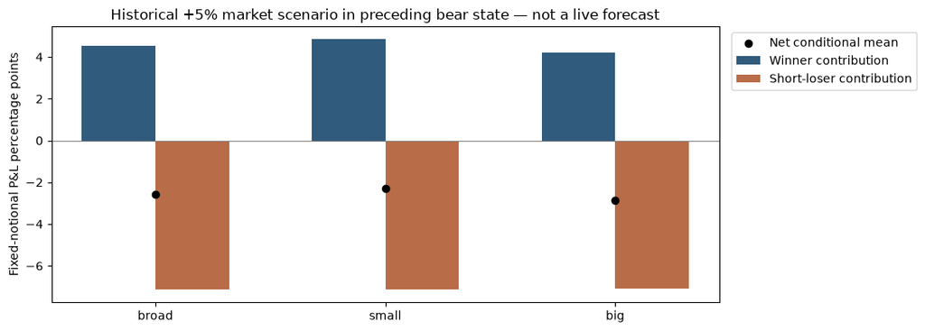

**Calculation code (expand for reproducibility)**

```
display(table.loc[table.bear & table.market.eq(5) & table.component.isin(['broad_net','small_net','big_net','hedged_net']),
    ['component','mean_pp','mean_lower95_pp','mean_upper95_pp','historical_dispersion_lo_pp',
     'historical_dispersion_hi_pp','nearby_weeks','nearby_recent_weeks','latest_nearby_outcome']])
display(r['stability'].loc[lambda f:f.bear & f.market.eq(5) & f.component.isin(['broad_net','small_net','big_net','hedged_net'])])
display(table.loc[table.component.eq('broad_net'),
    ['bear','market','mean_pp','mean_lower95_pp','mean_upper95_pp','nearby_weeks','nearby_recent_weeks']])
```

|  | component | mean_pp | mean_lower95_pp | mean_upper95_pp | historical_dispersion_lo_pp | historical_dispersion_hi_pp | nearby_weeks | nearby_recent_weeks | latest_nearby_outcome |
| --- | --- | --- | --- | --- | --- | --- | --- | --- | --- |
| 101 | broad_net | -2.581 | -3.947 | -1.100 | -6.524 | 1.200 | 17 | 1 | 2023-11-03 |
| 104 | small_net | -2.283 | -3.598 | -0.768 | -6.551 | 1.285 | 17 | 1 | 2023-11-03 |
| 107 | big_net | -2.879 | -4.383 | -1.131 | -7.367 | 1.131 | 17 | 1 | 2023-11-03 |
| 109 | hedged_net | -0.734 | -1.841 | 0.607 | -4.759 | 3.037 | 17 | 1 | 2023-11-03 |

|  | sample | bear | market | component | mean_pp | nearby_weeks | sample_weeks |
| --- | --- | --- | --- | --- | --- | --- | --- |
| 101 | full | True | 5.0 | broad_net | -2.581 | 17 | 2713 |
| 104 | full | True | 5.0 | small_net | -2.283 | 17 | 2713 |
| 107 | full | True | 5.0 | big_net | -2.879 | 17 | 2713 |
| 109 | full | True | 5.0 | hedged_net | -0.734 | 17 | 2713 |
| 211 | pre2017 | True | 5.0 | broad_net | -2.903 | 16 | 2243 |
| 214 | pre2017 | True | 5.0 | small_net | -2.687 | 16 | 2243 |
| 217 | pre2017 | True | 5.0 | big_net | -3.120 | 16 | 2243 |
| 219 | pre2017 | True | 5.0 | hedged_net | -0.898 | 16 | 2243 |
| 321 | 2017_onward | True | 5.0 | broad_net | -0.784 | 1 | 470 |
| 324 | 2017_onward | True | 5.0 | small_net | -0.041 | 1 | 470 |
| 327 | 2017_onward | True | 5.0 | big_net | -1.526 | 1 | 470 |
| 329 | 2017_onward | True | 5.0 | hedged_net | 0.264 | 1 | 470 |
| 431 | exclude_2008_2009 | True | 5.0 | broad_net | -1.533 | 12 | 2609 |
| 434 | exclude_2008_2009 | True | 5.0 | small_net | -1.396 | 12 | 2609 |
| 437 | exclude_2008_2009 | True | 5.0 | big_net | -1.671 | 12 | 2609 |
| 439 | exclude_2008_2009 | True | 5.0 | hedged_net | -0.015 | 12 | 2609 |

|  | bear | market | mean_pp | mean_lower95_pp | mean_upper95_pp | nearby_weeks | nearby_recent_weeks |
| --- | --- | --- | --- | --- | --- | --- | --- |
| 2 | False | -5.0 | -0.410 | -1.180 | 0.377 | 44 | 13 |
| 13 | False | -2.0 | 0.026 | -0.296 | 0.321 | 432 | 79 |
| 24 | False | 0.0 | 0.317 | 0.180 | 0.450 | 951 | 162 |
| 35 | False | 2.0 | 0.184 | -0.034 | 0.401 | 683 | 125 |
| 46 | False | 5.0 | -0.016 | -0.631 | 0.541 | 52 | 19 |
| 57 | True | -5.0 | 1.916 | 0.376 | 2.913 | 19 | 0 |
| 68 | True | -2.0 | 0.876 | 0.331 | 1.289 | 71 | 5 |
| 79 | True | 0.0 | 0.182 | -0.181 | 0.552 | 97 | 10 |
| 90 | True | 2.0 | -0.923 | -1.563 | -0.201 | 101 | 16 |
| 101 | True | 5.0 | -2.581 | -3.947 | -1.100 | 17 | 1 |

**Calculation code (expand for reproducibility)**

```
daily,panel=data();pred=original_run()['predictions'];latest=pred.iloc[-1]
fit_cutoff=pred.loc[pred.start.dt.year==latest.start.year,'cutoff'].min()
model=MomentumRiskCore().fit(panel,fit_cutoff)
reference=model.forecast(latest.ewma)
display(pd.Series({'assessment_cutoff':str(latest.cutoff.date()),
    'historical_outcome_interval':f'{latest.start.date()} to {latest.end.date()}',
    'annual_fit_cutoff':str(fit_cutoff.date()),'loss_boundary_pp':-2.16,
    'model_probability_percent':100*reference['probability'],'5th_percentile_pp':reference['q05_pp'],
    'status':'Historical replay; not current market or actual-book risk'},name='Quantitative reference'))
```

**Calculation code (expand for reproducibility)**

```
for example,(values,text) in r['changes'].items():
    display(Markdown('### '+example.replace('_',' ').title()))
    display(Markdown(text));display(values)
    np.testing.assert_allclose(values.total_change,values.volatility_effect+values.shock_sample_effect,atol=1e-10)
```

|  | metric | unit | previous_value | current_value | total_change | volatility_effect | shock_sample_effect |
| --- | --- | --- | --- | --- | --- | --- | --- |
| 0 | probability | probability percentage points | 26.245 | 26.245 | 0.000 | 0.000 | 0.0 |
| 1 | q05_pp | P&L percentage points | -5.989 | -5.980 | 0.009 | 0.009 | 0.0 |

|  | metric | unit | previous_value | current_value | total_change | volatility_effect | shock_sample_effect |
| --- | --- | --- | --- | --- | --- | --- | --- |
| 0 | probability | probability percentage points | 13.218 | 10.920 | -2.299 | -2.299 | 6.939e-16 |
| 1 | q05_pp | P&L percentage points | -3.165 | -2.913 | 0.252 | 0.214 | 3.801e-02 |

**Calculation code (expand for reproducibility)**

```
display(r['ledger'])
```

|  | claim | evidence | limit |
| --- | --- | --- | --- |
| 0 | Observed volatility | Calculated from preceding daily returns | Revised public factor data, not a live replica... |
| 1 | Fixed-threshold probability | Bear weeks: predicted 16.0%; realized 23.6% | Conditional underprediction; not a precise sta... |
| 2 | 5% downside quantile | Overall breaches 5.2% | Pooled coverage does not establish accuracy in... |
| 3 | Scenario mean | OLS conditional association and fixed-seed blo... | Not a causal macro-shock effect, current holdi... |
| 4 | Scenario outcome dispersion | Historical residual 5th–95th percentiles by state | Not a calibrated 90% future interval; earlier ... |
| 5 | First reversal warning | V5 alert rule captured 5 of 38 first events | Not demonstrated; no automatic action implication |
| 6 | Actual portfolio applicability | Public broad/small/big and illustrative beta h... | Book mapping unavailable; excludes costs, fina... |
| 7 | Assessment freshness | Scenario fit through 2026-01-02; historical re... | Do not present cached observations as current ... |

**Calculation code (expand for reproducibility)**

```
print(r['checks'])
# Template reproducibility and source traceability.
assert describe_scenario(table)==describe_scenario(table.copy())
assert (table.mean_lower95_pp<=table.mean_upper95_pp).all()
assert (table.historical_dispersion_lo_pp<=table.historical_dispersion_hi_pp).all()
assert r['metadata']['bootstrap_valid_draws']>=400
artifact={'version':6,'metadata':r['metadata'],'checks':r['checks'],
    'scenarios':table.to_dict(orient='records'),'stability':r['stability'].to_dict(orient='records'),
    'changes':{k:{'values':v.to_dict(orient='records'),'explanation':text} for k,(v,text) in r['changes'].items()},
    'reliability':r['ledger'].to_dict(orient='records'),
    'source_sha256':hashlib.sha256((ROOT/'scripts/pm_research.py').read_bytes()).hexdigest()}
(ROOT/'pm_research_v6.json').write_text(json.dumps(artifact,indent=2)+'\n')
print('PASS: deterministic template, ordered intervals, scenario contributions and change attribution. No prior selection file changed.')
```

## E07. Conditional quantiles and joint tails

**Calculation code (expand for reproducibility)**

```
from pathlib import Path
import os,sys,json
os.environ.setdefault('OPENBLAS_NUM_THREADS','1');os.environ.setdefault('OMP_NUM_THREADS','1')
os.environ.setdefault('VECLIB_MAXIMUM_THREADS','1')
ROOT=Path.cwd();sys.path.insert(0,str(ROOT/'scripts'))
import numpy as np
import pandas as pd
from IPython.display import display,Markdown
from tail_scenarios import run
r=run();pred=r['predictions'];metrics=r['metrics']
pd.set_option('display.max_columns',12);pd.set_option('display.precision',3)
print(r['status']);print(f'{len(pred)} weekly conditional forecasts, {pred.start.min().date()} to {pred.end.max().date()}')
```

**Calculation code (expand for reproducibility)**

```
display(metrics.loc[metrics['sample'].eq('all')])
display(metrics.loc[metrics['sample'].isin(['bear','bear rebound >2%','nonbear'])])
display(r['comparisons'])
```

|  | sample | model | quantile | weeks | breaches | breach_rate | pinball | mean_estimate_pp |
| --- | --- | --- | --- | --- | --- | --- | --- | --- |
| 0 | all | historical | 0.10 | 2221 | 302 | 0.136 | 0.418 | -1.572 |
| 1 | all | mean_residual | 0.10 | 2221 | 308 | 0.139 | 0.391 | -1.464 |
| 2 | all | qr_market | 0.10 | 2221 | 305 | 0.137 | 0.393 | -1.556 |
| 3 | all | qr_state | 0.10 | 2221 | 317 | 0.143 | 0.385 | -1.479 |
| 4 | all | historical | 0.05 | 2221 | 157 | 0.071 | 0.284 | -2.555 |
| 5 | all | mean_residual | 0.05 | 2221 | 175 | 0.079 | 0.266 | -2.269 |
| 6 | all | qr_market | 0.05 | 2221 | 151 | 0.068 | 0.264 | -2.447 |
| 7 | all | qr_state | 0.05 | 2221 | 170 | 0.077 | 0.258 | -2.342 |

|  | sample | model | quantile | weeks | breaches | breach_rate | pinball | mean_estimate_pp |
| --- | --- | --- | --- | --- | --- | --- | --- | --- |
| 24 | bear | historical | 0.10 | 271 | 83 | 0.306 | 0.843 | -1.592 |
| 25 | bear | mean_residual | 0.10 | 271 | 46 | 0.170 | 0.636 | -2.569 |
| 26 | bear | qr_market | 0.10 | 271 | 77 | 0.284 | 0.757 | -1.870 |
| 27 | bear | qr_state | 0.10 | 271 | 60 | 0.221 | 0.610 | -2.376 |
| 28 | bear | historical | 0.05 | 271 | 53 | 0.196 | 0.577 | -2.649 |
| 29 | bear | mean_residual | 0.05 | 271 | 32 | 0.118 | 0.432 | -3.442 |
| 30 | bear | qr_market | 0.05 | 271 | 41 | 0.151 | 0.498 | -2.834 |
| 31 | bear | qr_state | 0.05 | 271 | 34 | 0.125 | 0.375 | -3.296 |
| 32 | bear rebound >2% | historical | 0.10 | 68 | 37 | 0.544 | 1.717 | -1.622 |
| 33 | bear rebound >2% | mean_residual | 0.10 | 68 | 17 | 0.250 | 0.945 | -4.431 |
| 34 | bear rebound >2% | qr_market | 0.10 | 68 | 31 | 0.456 | 1.302 | -2.661 |
| 35 | bear rebound >2% | qr_state | 0.10 | 68 | 17 | 0.250 | 0.901 | -4.827 |
| 36 | bear rebound >2% | historical | 0.05 | 68 | 29 | 0.426 | 1.305 | -2.679 |
| 37 | bear rebound >2% | mean_residual | 0.05 | 68 | 11 | 0.162 | 0.698 | -5.317 |
| 38 | bear rebound >2% | qr_market | 0.05 | 68 | 17 | 0.250 | 0.975 | -3.835 |
| 39 | bear rebound >2% | qr_state | 0.05 | 68 | 11 | 0.162 | 0.582 | -5.813 |
| 40 | nonbear | historical | 0.10 | 1950 | 219 | 0.112 | 0.359 | -1.569 |
| 41 | nonbear | mean_residual | 0.10 | 1950 | 262 | 0.134 | 0.357 | -1.311 |
| 42 | nonbear | qr_market | 0.10 | 1950 | 228 | 0.117 | 0.342 | -1.512 |
| 43 | nonbear | qr_state | 0.10 | 1950 | 257 | 0.132 | 0.354 | -1.355 |
| 44 | nonbear | historical | 0.05 | 1950 | 104 | 0.053 | 0.244 | -2.542 |
| 45 | nonbear | mean_residual | 0.05 | 1950 | 143 | 0.073 | 0.243 | -2.106 |
| 46 | nonbear | qr_market | 0.05 | 1950 | 110 | 0.056 | 0.232 | -2.394 |
| 47 | nonbear | qr_state | 0.05 | 1950 | 136 | 0.070 | 0.242 | -2.210 |

|  | quantile | candidate | base | block | pinball_difference | lower95 | upper95 |
| --- | --- | --- | --- | --- | --- | --- | --- |
| 0 | 0.10 | qr_state | mean_residual | 13 | -0.006 | -0.014 | 1.547e-03 |
| 1 | 0.10 | qr_state | qr_market | 13 | -0.008 | -0.030 | 9.770e-03 |
| 2 | 0.05 | qr_state | mean_residual | 13 | -0.008 | -0.016 | 2.108e-04 |
| 3 | 0.05 | qr_state | qr_market | 13 | -0.006 | -0.025 | 7.743e-03 |
| 4 | 0.10 | qr_state | mean_residual | 26 | -0.006 | -0.015 | 1.666e-03 |
| 5 | 0.10 | qr_state | qr_market | 26 | -0.008 | -0.036 | 1.213e-02 |
| 6 | 0.05 | qr_state | mean_residual | 26 | -0.008 | -0.018 | 9.952e-04 |
| 7 | 0.05 | qr_state | qr_market | 26 | -0.006 | -0.029 | 9.949e-03 |

**Calculation code (expand for reproducibility)**

```
display(metrics.loc[metrics['sample'].isin(['1984–2016','2017 onward examined'])])
display(r['crossings'].rename(columns={'weeks':'weeks_where_5th_exceeds_10th'}))
```

|  | sample | model | quantile | weeks | breaches | breach_rate | pinball | mean_estimate_pp |
| --- | --- | --- | --- | --- | --- | --- | --- | --- |
| 8 | 1984–2016 | historical | 0.10 | 1722 | 227 | 0.132 | 0.401 | -1.481 |
| 9 | 1984–2016 | mean_residual | 0.10 | 1722 | 227 | 0.132 | 0.360 | -1.400 |
| 10 | 1984–2016 | qr_market | 0.10 | 1722 | 224 | 0.130 | 0.374 | -1.463 |
| 11 | 1984–2016 | qr_state | 0.10 | 1722 | 232 | 0.135 | 0.357 | -1.403 |
| 12 | 1984–2016 | historical | 0.05 | 1722 | 120 | 0.070 | 0.275 | -2.434 |
| 13 | 1984–2016 | mean_residual | 0.05 | 1722 | 127 | 0.074 | 0.244 | -2.188 |
| 14 | 1984–2016 | qr_market | 0.05 | 1722 | 116 | 0.067 | 0.255 | -2.313 |
| 15 | 1984–2016 | qr_state | 0.05 | 1722 | 125 | 0.073 | 0.242 | -2.245 |
| 16 | 2017 onward examined | historical | 0.10 | 499 | 75 | 0.150 | 0.474 | -1.888 |
| 17 | 2017 onward examined | mean_residual | 0.10 | 499 | 81 | 0.162 | 0.500 | -1.686 |
| 18 | 2017 onward examined | qr_market | 0.10 | 499 | 81 | 0.162 | 0.459 | -1.876 |
| 19 | 2017 onward examined | qr_state | 0.10 | 499 | 85 | 0.170 | 0.481 | -1.742 |
| 20 | 2017 onward examined | historical | 0.05 | 499 | 37 | 0.074 | 0.315 | -2.972 |
| 21 | 2017 onward examined | mean_residual | 0.05 | 499 | 48 | 0.096 | 0.344 | -2.550 |
| 22 | 2017 onward examined | qr_market | 0.05 | 499 | 35 | 0.070 | 0.296 | -2.910 |
| 23 | 2017 onward examined | qr_state | 0.05 | 499 | 45 | 0.090 | 0.316 | -2.677 |

|  | model | weeks_where_5th_exceeds_10th |
| --- | --- | --- |
| 0 | historical | 0 |
| 1 | mean_residual | 0 |
| 2 | qr_market | 12 |
| 3 | qr_state | 8 |

**Calculation code (expand for reproducibility)**

```
display(r['scenarios'])
```

|  | bear | market | conditional_mean | q10 | q5 | q10_estimate_lower95 | ... | q5_estimate_lower95 | q5_estimate_upper95 | crossed | fit_cutoff | nearby_weeks | nearby_recent_weeks |
| --- | --- | --- | --- | --- | --- | --- | --- | --- | --- | --- | --- | --- | --- |
| 0 | False | -5.0 | -0.410 | -2.155 | -2.685 | -2.740 | ... | -3.339 | -2.205 | False | 2026-01-02 | 44.0 | 13.0 |
| 1 | False | 0.0 | 0.317 | -1.454 | -2.390 | -1.699 | ... | -2.701 | -2.123 | False | 2026-01-02 | 951.0 | 162.0 |
| 2 | False | 5.0 | -0.016 | -2.533 | -4.011 | -3.448 | ... | -4.968 | -2.498 | False | 2026-01-02 | 52.0 | 19.0 |
| 3 | True | -5.0 | 1.916 | -2.155 | -2.685 | -2.510 | ... | -3.343 | -2.106 | False | 2026-01-02 | 19.0 | 0.0 |
| 4 | True | 0.0 | 0.182 | -1.454 | -2.390 | -2.158 | ... | -3.012 | -2.123 | False | 2026-01-02 | 97.0 | 10.0 |
| 5 | True | 5.0 | -2.581 | -6.974 | -7.473 | -7.626 | ... | -8.315 | -4.608 | False | 2026-01-02 | 17.0 | 1.0 |

6 rows × 13 columns

**Calculation code (expand for reproducibility)**

```
display(r['joint_breaches'])
joint=r['joint_breaches'].dropna()
np.testing.assert_allclose(joint.realized_long_mean_pp+joint.realized_short_mean_pp,joint.realized_net_mean_pp,atol=1e-10)
```

|  | sample | quantile | selected_weeks | realized_long_mean_pp | realized_short_mean_pp | realized_net_mean_pp |
| --- | --- | --- | --- | --- | --- | --- |
| 0 | all | 0.10 | 317 | -0.444 | -2.754 | -3.198 |
| 1 | all | 0.05 | 170 | -0.760 | -3.579 | -4.339 |
| 2 | bear rebound >2% | 0.10 | 17 | 3.044 | -10.169 | -7.126 |
| 3 | bear rebound >2% | 0.05 | 11 | 3.168 | -11.842 | -8.674 |

**Calculation code (expand for reproducibility)**

```
print(r['checks'])
summary={'version':7,'status':r['status'],'metrics':metrics.to_dict(orient='records'),
    'comparisons':r['comparisons'].to_dict(orient='records'),'scenarios':r['scenarios'].to_dict(orient='records'),
    'joint_breaches':r['joint_breaches'].to_dict(orient='records'),
    'crossings':r['crossings'].to_dict(orient='records'),'checks':r['checks'],'fingerprint':r['fingerprint']}
(ROOT/'tail_scenarios_v7.json').write_text(json.dumps(summary,indent=2)+'\n')
print('Conditional tail experiment completed; previous models and mean scenario analysis preserved.')
```

## E08. Baseline validation and distribution appendix

**Calculation code (expand for reproducibility)**

```
from pathlib import Path
import os, sys, json
os.environ.setdefault('OPENBLAS_NUM_THREADS', '1')
os.environ.setdefault('OMP_NUM_THREADS', '1')
os.environ.setdefault('VECLIB_MAXIMUM_THREADS', '1')
ROOT = Path.cwd()
if not (ROOT / 'scripts/companion_v8.py').exists():
    raise RuntimeError('Open/run this notebook from the gpt-momentum repository root.')
sys.path.insert(0, str(ROOT / 'scripts'))
%matplotlib inline
import numpy as np
import pandas as pd
import matplotlib.pyplot as plt
from IPython.display import display, Markdown
from companion_v8 import Companion
from distribution_panel import tail_weights, profile
from final_distribution_checks import change, path_summary, path_windows
from through_time_v8 import performance_plot, episode_ledger, episode_plot, alarm_table, scenario_time_plot, self_test as time_self_test
try:
    import ipywidgets as W
except ImportError:
    W = None
C = Companion(ROOT)
DEFAULT_DATE = '2022-12-31'
STATE = {'date': DEFAULT_DATE}
REFRESH = []
FIGURES = ROOT / 'research/notebook_v8/figures'
FIGURES.mkdir(exist_ok=True)
pd.set_option('display.max_columns', 12)
pd.set_option('display.precision', 3)
print('PASS: all prepared data and research-input hashes verified.')
print(f'Daily observations: {C.daily.index.min().date()} to {C.daily.index.max().date()}')
print(f'Frozen evaluation: {C.manifest["evaluation_start"]} to {C.manifest["evaluation_end"]}; {len(C.evaluation):,} weeks')
print('Widgets available:', W is not None)

def dropdown(options, value, label):
    return W.Dropdown(options=options, value=value, description=label, layout=W.Layout(width='260px')) if W else None

def value(control, default):
    return control.value if control is not None else default

def view(name, draw, controls=(), shared=True):
    """Save/display a static default; notebook controls update the same output in place."""
    active = [x for x in controls if x is not None]
    if active:
        display(W.HBox(active, layout=W.Layout(flex_flow='row wrap')))
    obj = draw()
    isfig = isinstance(obj, plt.Figure)
    if isfig:
        obj.savefig(FIGURES / f'{name}.png', dpi=150, bbox_inches='tight')
    handle = display(obj, display_id=True)
    if isfig: plt.close(obj)
    busy = [False]
    def refresh(event=None):
        if busy[0]: return
        busy[0] = True
        try:
            new = draw()
            handle.update(new)
            if isinstance(new, plt.Figure): plt.close(new)
        finally:
            busy[0] = False
    for control in active:
        control.observe(refresh, names='value')
    if shared: REFRESH.append(refresh)
    return refresh

if W:
    cursor = W.SelectionSlider(options=C.dates, value=DEFAULT_DATE, description='As of',
                               continuous_update=False, layout=W.Layout(width='650px'))
    previous = W.Button(description='← Quarter', layout=W.Layout(width='110px'))
    following = W.Button(description='Quarter →', layout=W.Layout(width='110px'))
    status = W.HTML(value='Historical replay; evaluation sample remains fixed.')
    def move_date(event):
        STATE['date'] = cursor.value
        status.value = f'<b>Historical date {cursor.value}</b> — refreshing linked views.'
        for refresh in REFRESH: refresh()
        status.value = f'<b>Historical date {cursor.value}</b> — not live; evaluation unchanged.'
    cursor.observe(move_date, names='value')
    previous.on_click(lambda _: setattr(cursor, 'value', C.dates[max(0, C.dates.index(cursor.value)-1)]))
    following.on_click(lambda _: setattr(cursor, 'value', C.dates[min(len(C.dates)-1, C.dates.index(cursor.value)+1)]))
    display(W.VBox([W.HBox([previous, following]), cursor, status]))
else:
    print('Static mode: change DEFAULT_DATE above and rerun for another historical date.')
```

**Calculation code (expand for reproducibility)**

```
difference = (C.daily.net - C.daily.Mom).abs()
assert difference.max() < 0.02
display(pd.DataFrame({'Check': ['Max |published Mom − reconstructed net|', 'Last observation'],
                      'Result': [f'{difference.max():.4f} pp', str(C.daily.index.max().date())]}))
year_range = W.IntRangeSlider(value=[1975,2022], min=1975, max=2022, description='Zoom years',
                             continuous_update=False, layout=W.Layout(width='600px')) if W else None
_ = view('01_exposure', lambda: C.exposure(STATE['date'], value(year_range, (1975,2022))), [year_range])
```

|  | Check | Result |
| --- | --- | --- |
| 0 | Max \|published Mom − reconstructed net\| | 0.0100 pp |
| 1 | Last observation | 2022-12-30 |

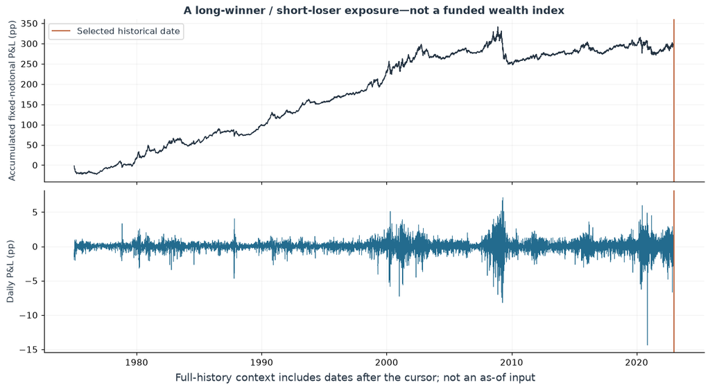

**Calculation code (expand for reproducibility)**

```
path_h = dropdown([5,20], 5, 'Sessions')
_ = view('02_path', lambda: C.path(STATE['date'], value(path_h,5)), [path_h])
display(pd.DataFrame(C.checks['path_summary'])[['h','crossed_fixed_loss','recovered_above_threshold',
                                              'recovered_fraction_of_crossings']].rename(columns={
    'h':'Sessions', 'crossed_fixed_loss':'Crossing windows', 'recovered_above_threshold':'Recovered windows',
    'recovered_fraction_of_crossings':'Recovery fraction'}))
```

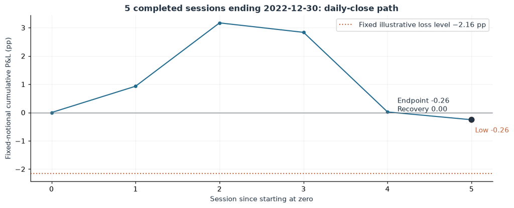

|  | Sessions | Crossing windows | Recovered windows | Recovery fraction |
| --- | --- | --- | --- | --- |
| 0 | 5 | 1338 | 294 | 0.220 |
| 1 | 20 | 3545 | 1457 | 0.411 |

**Calculation code (expand for reproducibility)**

```
_ = view('03_forward_baseline', lambda: C.baseline(STATE['date']))
model, sigma, forecast = C.core(STATE['date'])
display(pd.Series({'Annual fit cutoff': str(model.fitted_asof.date()),
                   'Latest completed training week': str(model.training_end.date()),
                   'Historical shocks': len(model.residuals),
                   'Current daily scale (pp)': round(sigma,3)}, name='Default-fit audit'))
```

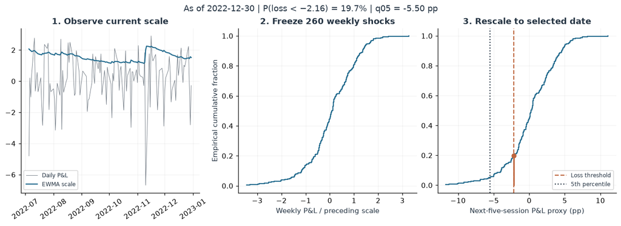

**Calculation code (expand for reproducibility)**

```
evaluation_state = dropdown(['all','bear','nonbear'], 'all', 'Fixed sample')
_ = view('04_validation', lambda: C.validation(value(evaluation_state,'all')), [evaluation_state], shared=False)
display(C.scores().round(4))
```

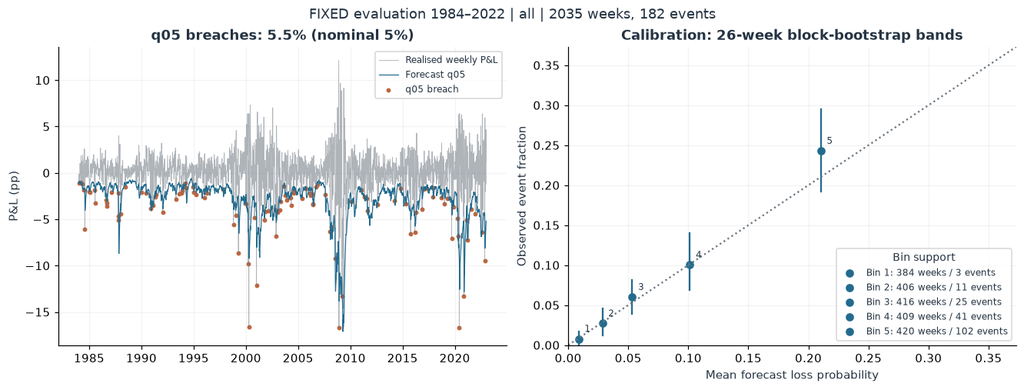

|  | model | state | weeks | events | predicted | observed | brier | log_loss | q05_breach |
| --- | --- | --- | --- | --- | --- | --- | --- | --- | --- |
| 0 | Historical frequency | all | 2035 | 182 | 0.063 | 0.089 | 0.082 | 0.305 | 0.072 |
| 1 | Historical frequency | bear | 238 | 58 | 0.065 | 0.244 | 0.216 | 0.719 | 0.210 |
| 2 | Historical frequency | nonbear | 1797 | 124 | 0.062 | 0.069 | 0.064 | 0.250 | 0.053 |
| 3 | 126-session volatility logit | all | 2035 | 182 | 0.101 | 0.089 | 0.074 | 0.262 | NaN |
| 4 | 126-session volatility logit | bear | 238 | 58 | 0.220 | 0.244 | 0.163 | 0.498 | NaN |
| 5 | 126-session volatility logit | nonbear | 1797 | 124 | 0.085 | 0.069 | 0.062 | 0.231 | NaN |
| 6 | Matched EWMA logit | all | 2035 | 182 | 0.106 | 0.089 | 0.073 | 0.256 | NaN |
| 7 | Matched EWMA logit | bear | 238 | 58 | 0.221 | 0.244 | 0.159 | 0.490 | NaN |
| 8 | Matched EWMA logit | nonbear | 1797 | 124 | 0.091 | 0.069 | 0.062 | 0.225 | NaN |
| 9 | Retained empirical/volatility | all | 2035 | 182 | 0.082 | 0.089 | 0.073 | 0.255 | 0.055 |
| 10 | Retained empirical/volatility | bear | 238 | 58 | 0.166 | 0.244 | 0.172 | 0.518 | 0.055 |
| 11 | Retained empirical/volatility | nonbear | 1797 | 124 | 0.071 | 0.069 | 0.060 | 0.221 | 0.055 |

**Calculation code (expand for reproducibility)**

```
forward_audit = pd.DataFrame(C.audit['forward'])
display(forward_audit.query("block == 26 and subset in ['all', 'bear']").round(4))
display(forward_audit.query("block == 26 and metric == 'Brier' and comparator == 'Volatility logit' and subset not in ['all','bear','nonbear']").round(4))
print('Full block-length and calendar-period sensitivity: research/notebook_v8/validation/results.json')
```

|  | comparator | metric | subset | n | events | difference | lo | hi | block |
| --- | --- | --- | --- | --- | --- | --- | --- | --- | --- |
| 1 | Frequency | Brier | all | 2035 | 182 | -9.100e-03 | -1.520e-02 | -4.200e-03 | 26 |
| 4 | Frequency | Brier | bear | 238 | 58 | -4.430e-02 | -9.010e-02 | -1.250e-02 | 26 |
| 19 | Frequency | Log loss | all | 2035 | 182 | -4.930e-02 | -7.560e-02 | -2.700e-02 | 26 |
| 22 | Frequency | Log loss | bear | 238 | 58 | -2.013e-01 | -3.802e-01 | -6.790e-02 | 26 |
| 37 | Volatility logit | Brier | all | 2035 | 182 | -1.000e-03 | -3.400e-03 | 1.400e-03 | 26 |
| 40 | Volatility logit | Brier | bear | 238 | 58 | 9.300e-03 | -2.500e-03 | 2.560e-02 | 26 |
| 55 | Volatility logit | Log loss | all | 2035 | 182 | -7.100e-03 | -1.540e-02 | 8.000e-04 | 26 |
| 58 | Volatility logit | Log loss | bear | 238 | 58 | 2.020e-02 | -1.200e-02 | 5.810e-02 | 26 |
| 73 | Matched EWMA logit | Brier | all | 2035 | 182 | -6.000e-04 | -3.500e-03 | 2.700e-03 | 26 |
| 76 | Matched EWMA logit | Brier | bear | 238 | 58 | 1.310e-02 | -7.000e-04 | 3.470e-02 | 26 |
| 91 | Matched EWMA logit | Log loss | all | 2035 | 182 | -8.000e-04 | -7.400e-03 | 6.600e-03 | 26 |
| 94 | Matched EWMA logit | Log loss | bear | 238 | 58 | 2.840e-02 | -3.100e-03 | 7.460e-02 | 26 |
| 109 | Historical quantile | q05 pinball | all | 2035 | 182 | -7.290e-02 | -1.225e-01 | -3.730e-02 | 26 |
| 112 | Historical quantile | q05 pinball | bear | 238 | 58 | -3.157e-01 | -6.720e-01 | -7.680e-02 | 26 |

|  | comparator | metric | subset | n | events | difference | lo | hi | block |
| --- | --- | --- | --- | --- | --- | --- | --- | --- | --- |
| 46 | Volatility logit | Brier | 1984–1999 | 835 | 33 | -1.200e-03 | -0.003 | -1.000e-04 | 26 |
| 49 | Volatility logit | Brier | 2000–2016 | 887 | 111 | -1.000e-04 | -0.006 | 5.700e-03 | 26 |
| 52 | Volatility logit | Brier | 2017–2022 | 313 | 38 | -3.400e-03 | -0.008 | 8.000e-04 | 26 |

**Calculation code (expand for reproducibility)**

```
time_window = dropdown([('156 weeks (~3 years)',156),('260 weeks (~5 years)',260)],156,'Evaluation span')
_ = view('04b_performance_time',lambda: performance_plot(C.evaluation,value(time_window,156)),[time_window],shared=False)
display(C.evaluation.groupby('sessions').agg(Weeks=('y','size')).rename_axis('Actual trading sessions in evaluated calendar week'))
```

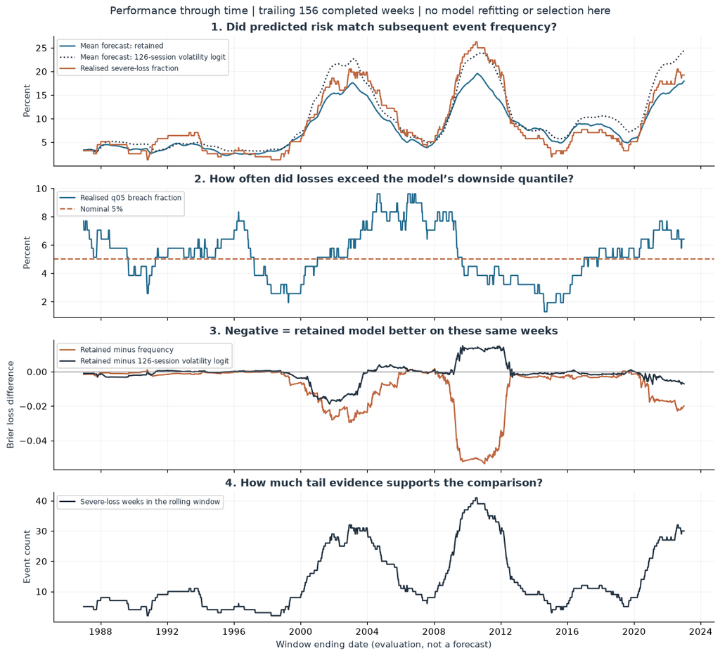

| Actual trading sessions in evaluated calendar week | Weeks |
| --- | --- |
| 1 | 1 |
| 3 | 2 |
| 4 | 336 |
| 5 | 1696 |

**Calculation code (expand for reproducibility)**

```
time_episodes = episode_ledger(C.evaluation)
display(alarm_table(C.evaluation))
decades = (pd.to_datetime(time_episodes.start).dt.year // 10) * 10
representatives = time_episodes.loc[time_episodes.groupby(decades).total_pp.idxmin()].sort_values('start')
display(representatives[['episode','start','end','weeks','total_pp']].rename(columns={
    'episode':'Run','start':'Start','end':'End','weeks':'Loss weeks','total_pp':'Total P&L (pp)'}).round(2))
probability_table = representatives[['episode','prior4_mean_p','first_week_p','first_week_logit','during_mean_p','after4_mean_p']].copy()
probability_table.iloc[:,1:] *= 100
display(probability_table.rename(columns={'episode':'Run','prior4_mean_p':'Prior 4 weeks (%)',
    'first_week_p':'Before first loss (%)','first_week_logit':'Logit before first loss (%)',
    'during_mean_p':'During run (%)','after4_mean_p':'Next 4 weeks (%)'}).round(1))
display(representatives[['episode','prior_weeks','after_weeks']].rename(columns={
    'episode':'Run','prior_weeks':'Available prior weeks','after_weeks':'Available subsequent weeks'}))
episode_choice = dropdown([(f'{r.episode}: {r.start}',r.episode) for r in time_episodes.itertuples()],1,'Event run')
_ = view('04c_event_review',lambda: episode_plot(C.evaluation,value(episode_choice,1)),[episode_choice],shared=False)
time_episodes.to_parquet(ROOT/'research/notebook_v8/validation/event_run_ledger.parquet',index=False)
print(time_self_test(C.evaluation))
print('Complete run ledger: research/notebook_v8/validation/event_run_ledger.parquet. Displayed probabilities are percentages; saved ledger uses fractions.')
```

|  | Question | Count | Denominator |
| --- | --- | --- | --- |
| 0 | Elevated forecast weeks | 212 | 2035 |
| 1 | Elevated forecast + severe loss | 67 | 212 |
| 2 | Elevated forecast without severe loss | 145 | 212 |
| 3 | Severe loss below elevated threshold | 115 | 182 |
| 4 | Event runs elevated before first loss week | 39 | 135 |

|  | Run | Start | End | Loss weeks | Total P&L (pp) |
| --- | --- | --- | --- | --- | --- |
| 4 | 5 | 1987-10-05 | 1987-10-23 | 3 | -11.99 |
| 10 | 11 | 1991-01-21 | 1991-02-08 | 3 | -8.83 |
| 79 | 80 | 2009-03-09 | 2009-05-08 | 9 | -69.01 |
| 111 | 112 | 2019-09-03 | 2019-09-13 | 2 | -9.86 |
| 117 | 118 | 2020-05-18 | 2020-06-05 | 3 | -26.56 |

|  | Run | Prior 4 weeks (%) | Before first loss (%) | Logit before first loss (%) | During run (%) | Next 4 weeks (%) |
| --- | --- | --- | --- | --- | --- | --- |
| 4 | 5 | 3.7 | 4.8 | 2.7 | 8.1 | 24.9 |
| 10 | 11 | 8.9 | 7.5 | 7.3 | 8.0 | 8.8 |
| 79 | 80 | 29.3 | 29.3 | 42.2 | 32.2 | 32.2 |
| 111 | 112 | 12.7 | 10.9 | 9.9 | 11.9 | 17.2 |
| 117 | 118 | 27.1 | 27.8 | 23.0 | 29.1 | 32.5 |

|  | Run | Available prior weeks | Available subsequent weeks |
| --- | --- | --- | --- |
| 4 | 5 | 4 | 4 |
| 10 | 11 | 4 | 4 |
| 79 | 80 | 4 | 4 |
| 111 | 112 | 4 | 4 |
| 117 | 118 | 4 | 4 |

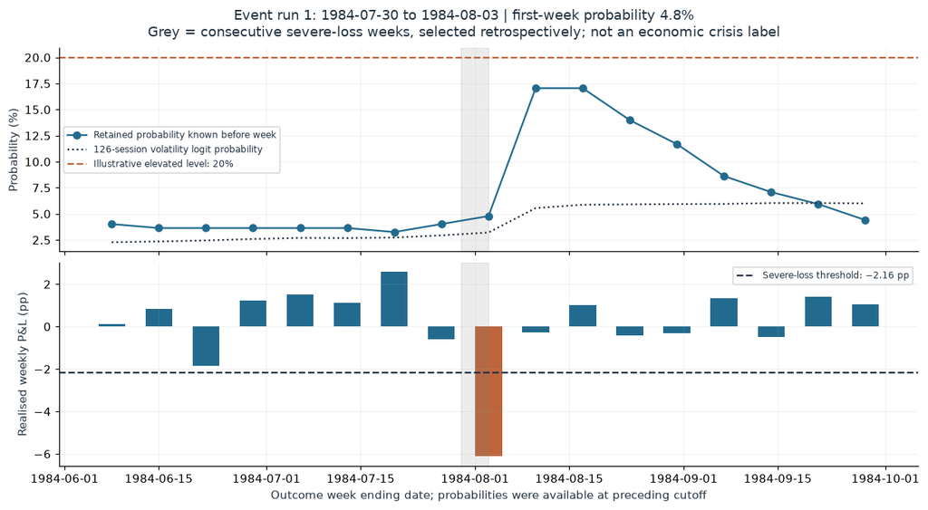

**Calculation code (expand for reproducibility)**

```
comparison_dates = sorted(set(C.atlas.date))
date_a = dropdown(comparison_dates,'2015-04-30','Sample A')
date_b = dropdown(comparison_dates,'2018-11-30','Sample B')
dist_h = dropdown([5,20],5,'Sessions')
dist_w = dropdown([126,252,504],252,'Lookback')
standard = W.Checkbox(value=False,description='Remove mean / SD') if W else None
if W:
    preset = W.Button(description='Load 20-day contrast',layout=W.Layout(width='220px'))
    def load_twenty(_):
        date_a.value='2019-08-31';date_b.value='2022-08-31';dist_h.value=20
    preset.on_click(load_twenty);display(preset)
_ = view('05_distributions', lambda: C.distributions(value(date_a,'2015-04-30'), value(date_b,'2018-11-30'),
          value(dist_h,5),value(dist_w,252),value(standard,False)),
         [date_a,date_b,dist_h,dist_w,standard], shared=False)
```

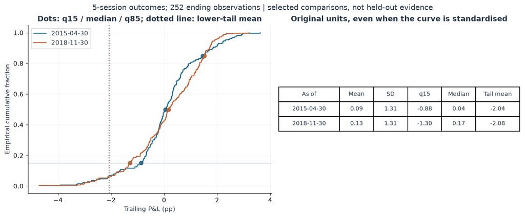

**Calculation code (expand for reproducibility)**

```
uncertainty = []
for r in C.panel['uncertainty']:
    if r['block'] == 60:
        for i,metric in enumerate(r['metrics']):
            uncertainty.append({'A':r['a'],'B':r['b'],'Horizon':r['h'],'Metric':metric,
                                'B minus A':r['difference'][i],
                                'Approx simultaneous lower':r['simultaneous_approx95_lo'][i],
                                'Approx simultaneous upper':r['simultaneous_approx95_hi'][i]})
display(pd.DataFrame(uncertainty).round(3))
```

|  | A | B | Horizon | Metric | B minus A | Approx simultaneous lower | Approx simultaneous upper |
| --- | --- | --- | --- | --- | --- | --- | --- |
| 0 | 2015-04-30 | 2018-11-30 | 5 | tail_mean | -0.034 | -1.252 | 1.493 |
| 1 | 2015-04-30 | 2018-11-30 | 5 | standardized_tail | -0.050 | -0.382 | 0.248 |
| 2 | 2015-04-30 | 2018-11-30 | 5 | downside_share | 0.126 | -0.117 | 0.245 |
| 3 | 2015-04-30 | 2018-11-30 | 5 | q15 | -0.417 | -1.076 | 1.241 |
| 4 | 2019-08-31 | 2022-08-31 | 20 | tail_mean | -1.251 | -6.490 | 4.396 |
| 5 | 2019-08-31 | 2022-08-31 | 20 | standardized_tail | -0.283 | -0.561 | 0.265 |
| 6 | 2019-08-31 | 2022-08-31 | 20 | downside_share | 0.205 | -0.177 | 0.359 |
| 7 | 2019-08-31 | 2022-08-31 | 20 | q15 | -0.819 | -4.815 | 4.218 |

**Calculation code (expand for reproducibility)**

```
leg_h = dropdown([5,20],5,'Sessions')
leg_w = dropdown([126,252,504],252,'Lookback')
leg_book = dropdown(['broad','small','big'],'broad','Book')
tail_point = W.IntSlider(value=0,min=0,max=37,description='Tail point',continuous_update=False) if W else None
def draw_legs():
    h,w,book=value(leg_h,5),value(leg_w,252),value(leg_book,'broad')
    if tail_point is not None:
        y=C.sample(STATE['date'],h,w,book).sum(axis=1).to_numpy()
        tail_point.max=int((tail_weights(y)>0).sum())-1
    return C.leg_view(STATE['date'],h,w,book,value(tail_point,0))
_ = view('06_leg_attribution',draw_legs,[leg_h,leg_w,leg_book,tail_point])
```

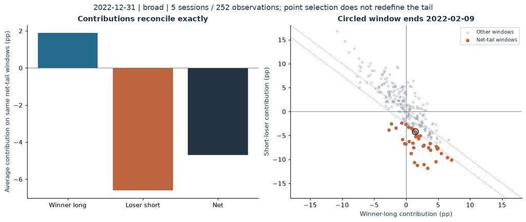

**Calculation code (expand for reproducibility)**

```
episode_h = dropdown([5,20],5,'Sessions')
episode_pick = W.IntSlider(value=1,min=1,max=20,description='Episode',continuous_update=False) if W else None
episode_omit = W.Checkbox(value=True,description='Show largest-episode sensitivity') if W else None
def draw_episodes():
    h=value(episode_h,5)
    if episode_pick is not None:
        episode_pick.max=profile(C.sample(STATE['date'],h).to_numpy(),h)['episodes']
    return C.episodes(STATE['date'],h,252,value(episode_pick,1),value(episode_omit,True))
_ = view('07_episodes',draw_episodes,[episode_h,episode_pick,episode_omit])
_ = view('07b_size_check',lambda: C.sizes(STATE['date'],value(episode_h,5)),[episode_h])
```

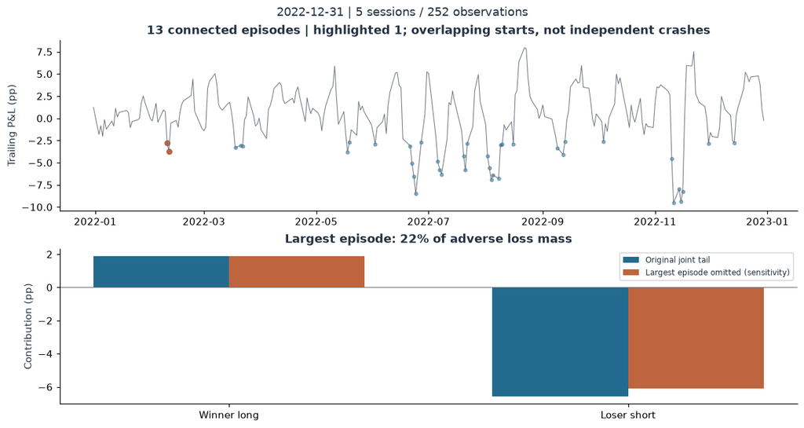

|  | Book | Lower15% mean | Long contribution | Short contribution | Episodes |
| --- | --- | --- | --- | --- | --- |
| 0 | broad | -4.696 | 1.890 | -6.587 | 13 |
| 1 | small | -5.201 | 1.105 | -6.305 | 12 |
| 2 | big | -4.674 | 1.288 | -5.961 | 15 |

**Calculation code (expand for reproducibility)**

```
_ = view('07c_mechanism_history', C.atlas_plot, shared=False)
display(pd.DataFrame(C.panel['summary']).query("book == 'broad'")[
    ['h','median_episodes','median_largest_episode_share','dominant_leg_survival_among_nonempty','empty_after_removal']].round(3))
```

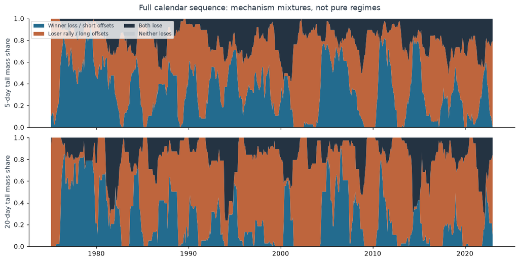

|  | h | median_episodes | median_largest_episode_share | dominant_leg_survival_among_nonempty | empty_after_removal |
| --- | --- | --- | --- | --- | --- |
| 4 | 1 | 38.0 | 0.064 | 0.984 | 0 |
| 5 | 5 | 9.0 | 0.311 | 0.889 | 0 |
| 6 | 10 | 5.0 | 0.486 | 0.809 | 0 |
| 7 | 20 | 3.0 | 0.667 | 0.752 | 27 |

**Calculation code (expand for reproducibility)**

```
rows = [r for r in C.panel['temporal'] if r['date']=='2020-11-30' and r['h']==20 and r['block']==20]
display(pd.DataFrame([{'Block boundary':r['phase'],'Observed tail mean':r['observed'][0],
                      'Reordered median':r['reordered_median'][0],
                      'Observed percentile (not p-value)':100*r['observed_percentile'][0]} for r in rows]).round(3))
```

|  | Block boundary | Observed tail mean | Reordered median | Observed percentile (not p-value) |
| --- | --- | --- | --- | --- |
| 0 | fixed | -14.471 | -11.010 | 0.251 |
| 1 | random_circular_cut | -14.471 | -13.932 | 42.356 |

**Calculation code (expand for reproducibility)**

```
change_dates = sorted(set(C.atlas.date))
prior_date = dropdown(change_dates,'2021-01-31','Previous')
current_date = dropdown(change_dates,'2021-02-28','Current')
change_h = dropdown([5,20],5,'Sessions')
def change_view():
    a,b=value(prior_date,'2021-01-31'),value(current_date,'2021-02-28')
    if pd.Timestamp(b)<=pd.Timestamp(a) or (pd.Timestamp(b)-pd.Timestamp(a)).days>270:
        return Markdown('Choose a later current date within 270 calendar days of the previous date.')
    return C.changes(a,b,value(change_h,5))
_ = view('08_window_accounting', change_view,[prior_date,current_date,change_h],shared=False)
```

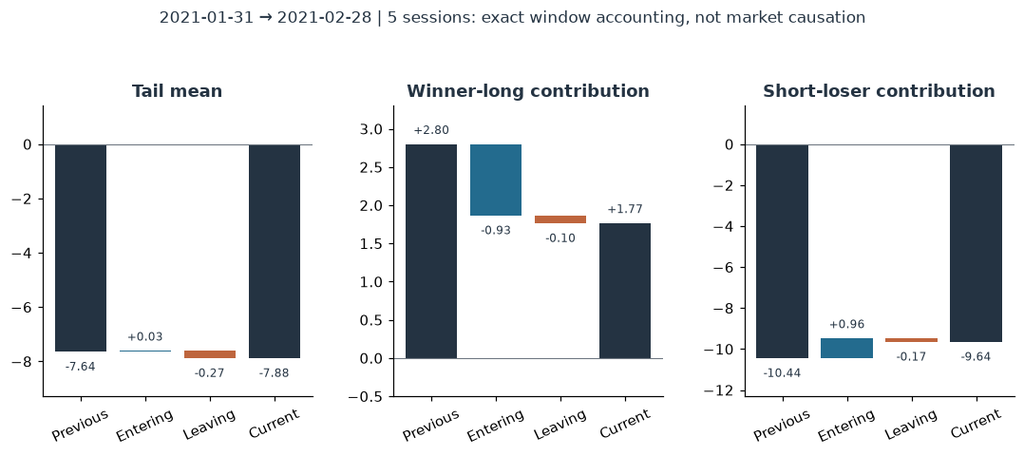

**Calculation code (expand for reproducibility)**

```
scenario_bear = dropdown([('Hypothetical bear',True),('Hypothetical non-bear',False)],True,'State')
scenario_move = W.FloatSlider(value=5,min=-5,max=5,step=.5,description='Market %',continuous_update=False) if W else None
_ = view('09_scenario',lambda: C.scenario(STATE['date'],value(scenario_bear,True),value(scenario_move,5.)),
         [scenario_bear,scenario_move])
```

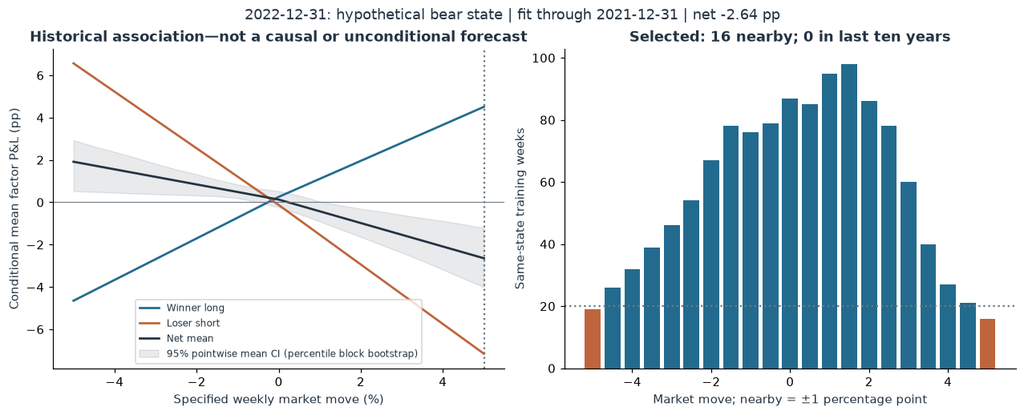

**Calculation code (expand for reproducibility)**

```
display(pd.DataFrame(C.audit['scenario']).round(3))
display(pd.DataFrame(C.audit['scenario_paired']).query('block == 26').round(3))
```

|  | subset | model | n | MAE | RMSE | coverage90 |
| --- | --- | --- | --- | --- | --- | --- |
| 0 | all | asymmetric | 2035 | 1.389 | 2.125 | 0.847 |
| 1 | all | linear | 2035 | 1.389 | 2.132 | 0.850 |
| 2 | all | state asymmetric | 2035 | 1.358 | 2.052 | 0.838 |
| 3 | bear rebound >2% | asymmetric | 59 | 3.415 | 4.608 | 0.508 |
| 4 | bear rebound >2% | linear | 59 | 3.597 | 4.882 | 0.525 |
| 5 | bear rebound >2% | state asymmetric | 59 | 2.888 | 3.837 | 0.644 |
| 6 | 2017–2022 | asymmetric | 313 | 1.752 | 2.564 | 0.821 |
| 7 | 2017–2022 | linear | 313 | 1.746 | 2.569 | 0.824 |
| 8 | 2017–2022 | state asymmetric | 313 | 1.852 | 2.752 | 0.760 |

|  | subset | comparator | metric | difference | lo | hi | block |
| --- | --- | --- | --- | --- | --- | --- | --- |
| 1 | all | linear | MAE | -0.032 | -0.100 | 0.034 | 26 |
| 4 | all | asymmetric | MAE | -0.032 | -0.101 | 0.036 | 26 |
| 7 | bear rebound >2% | linear | MAE | -0.709 | -1.736 | 0.460 | 26 |
| 10 | bear rebound >2% | asymmetric | MAE | -0.527 | -1.378 | 0.534 | 26 |
| 13 | 2017–2022 | linear | MAE | 0.107 | -0.008 | 0.248 | 26 |
| 16 | 2017–2022 | asymmetric | MAE | 0.101 | -0.016 | 0.239 | 26 |

**Calculation code (expand for reproducibility)**

```
scenario_history = pd.read_parquet(ROOT/'research/notebook_v8/validation/scenario_predictions.parquet')
assert set(scenario_history.end)==set(C.evaluation.end.dt.strftime('%Y-%m-%d'))
_ = view('09b_scenario_time',lambda: scenario_time_plot(scenario_history),shared=False)
```

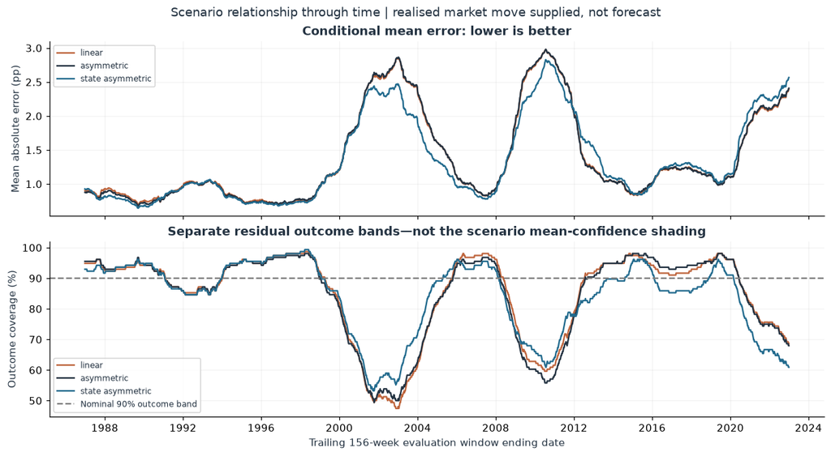

**Calculation code (expand for reproducibility)**

```
_ = view('10_snapshot',lambda: Markdown(C.snapshot(STATE['date'])))
```

**Calculation code (expand for reproducibility)**

```
display(pd.DataFrame(C.audit['explanatory_audit']))
```

|  | horizon | scheduled_snapshots | episode_over_half | dominant_leg_not_surviving_omission | any_description_warning |
| --- | --- | --- | --- | --- | --- |
| 0 | 5 | 132 | 7 | 11 | 64 |
| 1 | 20 | 132 | 105 | 31 | 119 |

**Calculation code (expand for reproducibility)**

```
assert len(C.snapshots)==132
for date, saved in C.snapshots.items():
    rendered = C.snapshot(date)
    short_section = rendered.split('**Five-session qualification:**', 1)[1].split('**Change since', 1)[0]
    long_section = rendered.split('**Longer-path qualification:**', 1)[1].split('**Applicability:**', 1)[0]
    for horizon, section in [('5', short_section), ('20', long_section)]:
        for warning in saved['description_warnings'][horizon]:
            assert warning in section, (date, horizon, warning)
        if not saved['description_warnings'][horizon]:
            assert 'does not establish confidence or safety' in section
print('PASS: horizon-specific snapshot qualifications displayed at all 132 dates, including no-flag caveats.')
assert C.checks['tests']['full_vs_truncated_replay']==132
assert C.checks['tests']['exact_entry_exit_reconciliation']==1150
np.testing.assert_allclose(tail_weights(np.ones(7)),np.full(7,.15))
for date in ['1990-03-31','2009-03-31','2020-12-31','2022-12-31']:
    model,scale,estimate=C.core(date)
    expected=C.snapshots[date]['separate_forward_research_estimate']
    np.testing.assert_allclose([estimate['probability'],estimate['q05_pp']],
                               [expected['probability'],expected['q05_pp']],atol=1e-12)
    a=C.sample(date).to_numpy();p=profile(a,5)
    np.testing.assert_allclose(p['tail_mean'],p['long']+p['short'],atol=1e-10)
    assert model.training_end < C.actual(date)
for s in C.scenarios.values():
    f=pd.DataFrame(s['rows'])
    np.testing.assert_allclose(f.net,f.long+f.short,atol=1e-10)
    assert s['bootstrap_valid']>250
print('PASS: 132 saved chronological replays; 1,150 change reconciliations; live forward replay at four dates; exact tail ties; scenario and leg additivity; cutoff ordering.')
print(f'{len(list(FIGURES.glob("*.png")))} static figures saved for inspection/export.')
```

## E09. Distributional anatomy and company-data audit

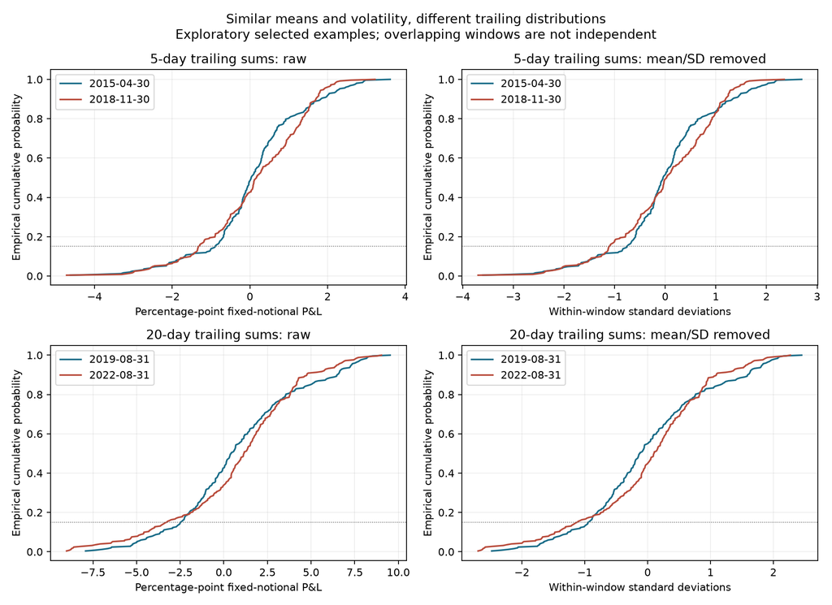

## E12. Exposure, shape and macro forecasting / conditional response

**conditional pairs 126: 210 result rows**

| subset | model | baseline | metric | block | n | years_better | years | delta | lo | hi |
| --- | --- | --- | --- | --- | --- | --- | --- | --- | --- | --- |
| all | dynamic | static | MAE | 13 | 2035 | 29 | 39 | -0.101277 | -0.150873 | -0.0583042 |
| all | dynamic | static | MAE | 26 | 2035 | 29 | 39 | -0.101277 | -0.160931 | -0.0516729 |
| all | dynamic | static | MAE | 52 | 2035 | 29 | 39 | -0.101277 | -0.165447 | -0.0518409 |
| all | dynamic | static | MSE | 13 | 2035 | 29 | 39 | -0.682121 | -1.03731 | -0.404412 |
| all | dynamic | static | MSE | 26 | 2035 | 29 | 39 | -0.682121 | -1.05625 | -0.359456 |
| all | dynamic | static | MSE | 52 | 2035 | 29 | 39 | -0.682121 | -1.06204 | -0.369783 |
| all | dynamic | rolling | MAE | 13 | 2035 | 22 | 39 | 0.000387441 | -0.0139089 | 0.0146288 |
| all | dynamic | rolling | MAE | 26 | 2035 | 22 | 39 | 0.000387441 | -0.0150846 | 0.0160326 |
| all | dynamic | rolling | MAE | 52 | 2035 | 22 | 39 | 0.000387441 | -0.0155768 | 0.0169382 |
| all | dynamic | rolling | MSE | 13 | 2035 | 21 | 39 | -0.0572389 | -0.173023 | 0.0326842 |
| all | dynamic | rolling | MSE | 26 | 2035 | 21 | 39 | -0.0572389 | -0.176706 | 0.0437857 |
| all | dynamic | rolling | MSE | 52 | 2035 | 21 | 39 | -0.0572389 | -0.205434 | 0.0394819 |
| all | rolling | static | MAE | 13 | 2035 | 29 | 39 | -0.101664 | -0.15935 | -0.0538063 |
| all | rolling | static | MAE | 26 | 2035 | 29 | 39 | -0.101664 | -0.167156 | -0.0453306 |
| all | rolling | static | MAE | 52 | 2035 | 29 | 39 | -0.101664 | -0.17402 | -0.0462638 |
| all | rolling | static | MSE | 13 | 2035 | 28 | 39 | -0.624882 | -0.989548 | -0.333042 |
| all | rolling | static | MSE | 26 | 2035 | 28 | 39 | -0.624882 | -1.0247 | -0.287079 |
| all | rolling | static | MSE | 52 | 2035 | 28 | 39 | -0.624882 | -1.01778 | -0.289806 |
| all | dynamic | vol_response | MAE | 13 | 2035 | 28 | 39 | -0.103912 | -0.155072 | -0.0603586 |
| all | dynamic | vol_response | MAE | 26 | 2035 | 28 | 39 | -0.103912 | -0.162107 | -0.0514579 |
| all | dynamic | vol_response | MAE | 52 | 2035 | 28 | 39 | -0.103912 | -0.167955 | -0.0511001 |
| all | dynamic | vol_response | MSE | 13 | 2035 | 31 | 39 | -0.657073 | -1.00216 | -0.383457 |
| all | dynamic | vol_response | MSE | 26 | 2035 | 31 | 39 | -0.657073 | -0.999608 | -0.344472 |
| all | dynamic | vol_response | MSE | 52 | 2035 | 31 | 39 | -0.657073 | -1.05819 | -0.322098 |
| all | full_response | vol_response | MAE | 13 | 2035 | 29 | 39 | -0.100444 | -0.150079 | -0.0591922 |
| all | full_response | vol_response | MAE | 26 | 2035 | 29 | 39 | -0.100444 | -0.15702 | -0.0519126 |
| all | full_response | vol_response | MAE | 52 | 2035 | 29 | 39 | -0.100444 | -0.16304 | -0.0503392 |
| all | full_response | vol_response | MSE | 13 | 2035 | 30 | 39 | -0.680703 | -1.00237 | -0.409338 |
| all | full_response | vol_response | MSE | 26 | 2035 | 30 | 39 | -0.680703 | -1.04054 | -0.369508 |
| all | full_response | vol_response | MSE | 52 | 2035 | 30 | 39 | -0.680703 | -1.07682 | -0.353274 |

[output cut: 180 more lines]

**conditional pairs 252: 210 result rows**

| subset | model | baseline | metric | block | n | years_better | years | delta | lo | hi |
| --- | --- | --- | --- | --- | --- | --- | --- | --- | --- | --- |
| all | dynamic | static | MAE | 13 | 2035 | 21 | 39 | -0.0404098 | -0.0740282 | -0.010074 |
| all | dynamic | static | MAE | 26 | 2035 | 21 | 39 | -0.0404098 | -0.0784487 | -0.00738778 |
| all | dynamic | static | MAE | 52 | 2035 | 21 | 39 | -0.0404098 | -0.0762957 | -0.00954535 |
| all | dynamic | static | MSE | 13 | 2035 | 25 | 39 | -0.372489 | -0.640764 | -0.148938 |
| all | dynamic | static | MSE | 26 | 2035 | 25 | 39 | -0.372489 | -0.653488 | -0.106413 |
| all | dynamic | static | MSE | 52 | 2035 | 25 | 39 | -0.372489 | -0.679509 | -0.115861 |
| all | dynamic | rolling | MAE | 13 | 2035 | 23 | 39 | 0.00498698 | -0.0123282 | 0.0240889 |
| all | dynamic | rolling | MAE | 26 | 2035 | 23 | 39 | 0.00498698 | -0.0150717 | 0.027183 |
| all | dynamic | rolling | MAE | 52 | 2035 | 23 | 39 | 0.00498698 | -0.0173691 | 0.02936 |
| all | dynamic | rolling | MSE | 13 | 2035 | 20 | 39 | 0.00778297 | -0.102237 | 0.112107 |
| all | dynamic | rolling | MSE | 26 | 2035 | 20 | 39 | 0.00778297 | -0.123956 | 0.129027 |
| all | dynamic | rolling | MSE | 52 | 2035 | 20 | 39 | 0.00778297 | -0.142998 | 0.133087 |
| all | rolling | static | MAE | 13 | 2035 | 19 | 39 | -0.0453968 | -0.0899719 | -0.00497744 |
| all | rolling | static | MAE | 26 | 2035 | 19 | 39 | -0.0453968 | -0.0953202 | 0.000829478 |
| all | rolling | static | MAE | 52 | 2035 | 19 | 39 | -0.0453968 | -0.0986535 | 0.000679963 |
| all | rolling | static | MSE | 13 | 2035 | 22 | 39 | -0.380272 | -0.693777 | -0.106225 |
| all | rolling | static | MSE | 26 | 2035 | 22 | 39 | -0.380272 | -0.719234 | -0.0721474 |
| all | rolling | static | MSE | 52 | 2035 | 22 | 39 | -0.380272 | -0.713367 | -0.0927206 |
| all | dynamic | vol_response | MAE | 13 | 2035 | 19 | 39 | -0.043045 | -0.073394 | -0.0116791 |
| all | dynamic | vol_response | MAE | 26 | 2035 | 19 | 39 | -0.043045 | -0.0811495 | -0.00787325 |
| all | dynamic | vol_response | MAE | 52 | 2035 | 19 | 39 | -0.043045 | -0.0821493 | -0.00927879 |
| all | dynamic | vol_response | MSE | 13 | 2035 | 24 | 39 | -0.347442 | -0.570887 | -0.131867 |
| all | dynamic | vol_response | MSE | 26 | 2035 | 24 | 39 | -0.347442 | -0.600547 | -0.11282 |
| all | dynamic | vol_response | MSE | 52 | 2035 | 24 | 39 | -0.347442 | -0.63762 | -0.115441 |
| all | full_response | vol_response | MAE | 13 | 2035 | 18 | 39 | -0.0418897 | -0.0715176 | -0.0132865 |
| all | full_response | vol_response | MAE | 26 | 2035 | 18 | 39 | -0.0418897 | -0.0782104 | -0.0109293 |
| all | full_response | vol_response | MAE | 52 | 2035 | 18 | 39 | -0.0418897 | -0.0761263 | -0.0118117 |
| all | full_response | vol_response | MSE | 13 | 2035 | 23 | 39 | -0.373485 | -0.618801 | -0.154485 |
| all | full_response | vol_response | MSE | 26 | 2035 | 23 | 39 | -0.373485 | -0.647917 | -0.130572 |
| all | full_response | vol_response | MSE | 52 | 2035 | 23 | 39 | -0.373485 | -0.658395 | -0.126806 |

[output cut: 180 more lines]

**conditional pairs 504: 210 result rows**

| subset | model | baseline | metric | block | n | years_better | years | delta | lo | hi |
| --- | --- | --- | --- | --- | --- | --- | --- | --- | --- | --- |
| all | dynamic | static | MAE | 13 | 2035 | 15 | 39 | 0.00618611 | -0.00583738 | 0.0192022 |
| all | dynamic | static | MAE | 26 | 2035 | 15 | 39 | 0.00618611 | -0.00773956 | 0.0208691 |
| all | dynamic | static | MAE | 52 | 2035 | 15 | 39 | 0.00618611 | -0.00926269 | 0.023935 |
| all | dynamic | static | MSE | 13 | 2035 | 17 | 39 | -0.00274913 | -0.0950965 | 0.0824395 |
| all | dynamic | static | MSE | 26 | 2035 | 17 | 39 | -0.00274913 | -0.103893 | 0.0961408 |
| all | dynamic | static | MSE | 52 | 2035 | 17 | 39 | -0.00274913 | -0.117221 | 0.118952 |
| all | dynamic | rolling | MAE | 13 | 2035 | 22 | 39 | -0.00632186 | -0.0345727 | 0.0208399 |
| all | dynamic | rolling | MAE | 26 | 2035 | 22 | 39 | -0.00632186 | -0.0387711 | 0.02319 |
| all | dynamic | rolling | MAE | 52 | 2035 | 22 | 39 | -0.00632186 | -0.0418024 | 0.0305174 |
| all | dynamic | rolling | MSE | 13 | 2035 | 22 | 39 | 0.022952 | -0.158377 | 0.213135 |
| all | dynamic | rolling | MSE | 26 | 2035 | 22 | 39 | 0.022952 | -0.186026 | 0.222166 |
| all | dynamic | rolling | MSE | 52 | 2035 | 22 | 39 | 0.022952 | -0.193062 | 0.252176 |
| all | rolling | static | MAE | 13 | 2035 | 16 | 39 | 0.012508 | -0.0198275 | 0.047014 |
| all | rolling | static | MAE | 26 | 2035 | 16 | 39 | 0.012508 | -0.0232991 | 0.0513065 |
| all | rolling | static | MAE | 52 | 2035 | 16 | 39 | 0.012508 | -0.0310108 | 0.0575934 |
| all | rolling | static | MSE | 13 | 2035 | 16 | 39 | -0.0257012 | -0.276722 | 0.194863 |
| all | rolling | static | MSE | 26 | 2035 | 16 | 39 | -0.0257012 | -0.296417 | 0.241147 |
| all | rolling | static | MSE | 52 | 2035 | 16 | 39 | -0.0257012 | -0.335138 | 0.268355 |
| all | dynamic | vol_response | MAE | 13 | 2035 | 11 | 39 | 0.00355093 | -0.0112937 | 0.0191134 |
| all | dynamic | vol_response | MAE | 26 | 2035 | 11 | 39 | 0.00355093 | -0.0120575 | 0.0202823 |
| all | dynamic | vol_response | MAE | 52 | 2035 | 11 | 39 | 0.00355093 | -0.0182845 | 0.0221453 |
| all | dynamic | vol_response | MSE | 13 | 2035 | 17 | 39 | 0.0222986 | -0.108318 | 0.167947 |
| all | dynamic | vol_response | MSE | 26 | 2035 | 17 | 39 | 0.0222986 | -0.115925 | 0.154207 |
| all | dynamic | vol_response | MSE | 52 | 2035 | 17 | 39 | 0.0222986 | -0.154079 | 0.171043 |
| all | full_response | vol_response | MAE | 13 | 2035 | 15 | 39 | 0.0048576 | -0.00668021 | 0.0160365 |
| all | full_response | vol_response | MAE | 26 | 2035 | 15 | 39 | 0.0048576 | -0.00711102 | 0.0176152 |
| all | full_response | vol_response | MAE | 52 | 2035 | 15 | 39 | 0.0048576 | -0.00726712 | 0.0184966 |
| all | full_response | vol_response | MSE | 13 | 2035 | 18 | 39 | 0.00125168 | -0.0968642 | 0.0813363 |
| all | full_response | vol_response | MSE | 26 | 2035 | 18 | 39 | 0.00125168 | -0.0946493 | 0.0967394 |
| all | full_response | vol_response | MSE | 52 | 2035 | 18 | 39 | 0.00125168 | -0.10739 | 0.109204 |

[output cut: 180 more lines]

**conditional scores 126: 35 result rows**

| subset | model | n | MAE | MSE |
| --- | --- | --- | --- | --- |
| all | static | 2035 | 1.35801 | 4.208 |
| all | rolling | 2035 | 1.25635 | 3.58312 |
| all | dynamic | 2035 | 1.25673 | 3.52588 |
| all | vol_response | 2035 | 1.36065 | 4.18295 |
| all | full_response | 2035 | 1.2602 | 3.50225 |
| bear | static | 238 | 2.28531 | 9.46786 |
| bear | rolling | 238 | 1.94241 | 7.88189 |
| bear | dynamic | 238 | 1.95553 | 7.34338 |
| bear | vol_response | 238 | 2.36079 | 9.89181 |
| bear | full_response | 238 | 1.95136 | 7.15456 |
| bear_rebound | static | 59 | 2.89522 | 14.704 |
| bear_rebound | rolling | 59 | 2.3561 | 12.2793 |
| bear_rebound | dynamic | 59 | 2.30245 | 10.201 |
| bear_rebound | vol_response | 59 | 2.84548 | 14.3796 |
| bear_rebound | full_response | 59 | 2.21815 | 9.18003 |
| 1984_1999 | static | 835 | 0.900771 | 1.60076 |
| 1984_1999 | rolling | 835 | 0.887636 | 1.51318 |
| 1984_1999 | dynamic | 835 | 0.877519 | 1.51654 |
| 1984_1999 | vol_response | 835 | 0.902541 | 1.6101 |
| 1984_1999 | full_response | 835 | 0.880492 | 1.52628 |
| 2000_2016 | static | 887 | 1.61404 | 5.47568 |
| 2000_2016 | rolling | 887 | 1.44628 | 4.59271 |
| 2000_2016 | dynamic | 887 | 1.46046 | 4.51971 |
| 2000_2016 | vol_response | 887 | 1.63351 | 5.58424 |
| 2000_2016 | full_response | 887 | 1.46431 | 4.49051 |
| 2017_2022 | static | 313 | 1.85227 | 7.57097 |
| 2017_2022 | rolling | 313 | 1.70173 | 6.24408 |
| 2017_2022 | dynamic | 313 | 1.69104 | 6.06987 |
| 2017_2022 | vol_response | 313 | 1.80949 | 7.07557 |
| 2017_2022 | full_response | 313 | 1.69477 | 5.97299 |
| exclude_crises | static | 1877 | 1.20021 | 3.03842 |
| exclude_crises | rolling | 1877 | 1.10446 | 2.52305 |
| exclude_crises | dynamic | 1877 | 1.10734 | 2.52103 |
| exclude_crises | vol_response | 1877 | 1.20235 | 3.03114 |
| exclude_crises | full_response | 1877 | 1.11212 | 2.52962 |

**conditional scores 252: 35 result rows**

| subset | model | n | MAE | MSE |
| --- | --- | --- | --- | --- |
| all | static | 2035 | 1.35801 | 4.208 |
| all | rolling | 2035 | 1.31262 | 3.82773 |
| all | dynamic | 2035 | 1.3176 | 3.83551 |
| all | vol_response | 2035 | 1.36065 | 4.18295 |
| all | full_response | 2035 | 1.31876 | 3.80947 |
| bear | static | 238 | 2.28531 | 9.46786 |
| bear | rolling | 238 | 2.09055 | 8.56973 |
| bear | dynamic | 238 | 2.13998 | 8.39156 |
| bear | vol_response | 238 | 2.36079 | 9.89181 |
| bear | full_response | 238 | 2.16369 | 8.37278 |
| bear_rebound | static | 59 | 2.89522 | 14.704 |
| bear_rebound | rolling | 59 | 2.6342 | 13.7956 |
| bear_rebound | dynamic | 59 | 2.65573 | 12.57 |
| bear_rebound | vol_response | 59 | 2.84548 | 14.3796 |
| bear_rebound | full_response | 59 | 2.5675 | 11.4878 |
| 1984_1999 | static | 835 | 0.900771 | 1.60076 |
| 1984_1999 | rolling | 835 | 0.917856 | 1.61415 |
| 1984_1999 | dynamic | 835 | 0.906569 | 1.6075 |
| 1984_1999 | vol_response | 835 | 0.902541 | 1.6101 |
| 1984_1999 | full_response | 835 | 0.909487 | 1.61918 |
| 2000_2016 | static | 887 | 1.61404 | 5.47568 |
| 2000_2016 | rolling | 887 | 1.52347 | 4.94322 |
| 2000_2016 | dynamic | 887 | 1.54645 | 4.98245 |
| 2000_2016 | vol_response | 887 | 1.63351 | 5.58424 |
| 2000_2016 | full_response | 887 | 1.54843 | 4.96468 |
| 2017_2022 | static | 313 | 1.85227 | 7.57097 |
| 2017_2022 | rolling | 313 | 1.7682 | 6.57181 |
| 2017_2022 | dynamic | 313 | 1.76559 | 6.52895 |
| 2017_2022 | vol_response | 313 | 1.80949 | 7.07557 |
| 2017_2022 | full_response | 313 | 1.75972 | 6.37883 |
| exclude_crises | static | 1877 | 1.20021 | 3.03842 |
| exclude_crises | rolling | 1877 | 1.16747 | 2.80026 |
| exclude_crises | dynamic | 1877 | 1.17197 | 2.82406 |
| exclude_crises | vol_response | 1877 | 1.20235 | 3.03114 |
| exclude_crises | full_response | 1877 | 1.17482 | 2.83201 |

**conditional scores 504: 35 result rows**

| subset | model | n | MAE | MSE |
| --- | --- | --- | --- | --- |
| all | static | 2035 | 1.35801 | 4.208 |
| all | rolling | 2035 | 1.37052 | 4.1823 |
| all | dynamic | 2035 | 1.3642 | 4.20525 |
| all | vol_response | 2035 | 1.36065 | 4.18295 |
| all | full_response | 2035 | 1.3655 | 4.1842 |
| bear | static | 238 | 2.28531 | 9.46786 |
| bear | rolling | 238 | 2.33204 | 9.80625 |
| bear | dynamic | 238 | 2.33527 | 9.66147 |
| bear | vol_response | 238 | 2.36079 | 9.89181 |
| bear | full_response | 238 | 2.39036 | 9.96973 |
| bear_rebound | static | 59 | 2.89522 | 14.704 |
| bear_rebound | rolling | 59 | 2.94515 | 15.7454 |
| bear_rebound | dynamic | 59 | 2.94777 | 15.003 |
| bear_rebound | vol_response | 59 | 2.84548 | 14.3796 |
| bear_rebound | full_response | 59 | 2.89228 | 14.4726 |
| 1984_1999 | static | 835 | 0.900771 | 1.60076 |
| 1984_1999 | rolling | 835 | 0.91683 | 1.63085 |
| 1984_1999 | dynamic | 835 | 0.910705 | 1.63857 |
| 1984_1999 | vol_response | 835 | 0.902541 | 1.6101 |
| 1984_1999 | full_response | 835 | 0.913642 | 1.65349 |
| 2000_2016 | static | 887 | 1.61404 | 5.47568 |
| 2000_2016 | rolling | 887 | 1.64788 | 5.66373 |
| 2000_2016 | dynamic | 887 | 1.62877 | 5.53815 |
| 2000_2016 | vol_response | 887 | 1.63351 | 5.58424 |
| 2000_2016 | full_response | 887 | 1.6408 | 5.62912 |
| 2017_2022 | static | 313 | 1.85227 | 7.57097 |
| 2017_2022 | rolling | 313 | 1.79485 | 6.79069 |
| 2017_2022 | dynamic | 313 | 1.82423 | 7.27521 |
| 2017_2022 | vol_response | 313 | 1.80949 | 7.07557 |
| 2017_2022 | full_response | 313 | 1.79079 | 6.84076 |
| exclude_crises | static | 1877 | 1.20021 | 3.03842 |
| exclude_crises | rolling | 1877 | 1.22911 | 3.14044 |
| exclude_crises | dynamic | 1877 | 1.21107 | 3.08985 |
| exclude_crises | vol_response | 1877 | 1.20235 | 3.03114 |
| exclude_crises | full_response | 1877 | 1.21181 | 3.08639 |

**macro pairs 14: 540 result rows**

| subset | model | baseline | metric | block | n | years_better | years | delta | lo | hi |
| --- | --- | --- | --- | --- | --- | --- | --- | --- | --- | --- |
| all | exposure | vol | Brier | 13 | 1200 | 11 | 23 | 0.0079972 | 0.000403022 | 0.0190481 |
| all | exposure | vol | Brier | 26 | 1200 | 11 | 23 | 0.0079972 | -0.000283056 | 0.0218042 |
| all | exposure | vol | Brier | 52 | 1200 | 11 | 23 | 0.0079972 | -0.000680679 | 0.0250799 |
| all | exposure | vol | logloss | 13 | 1200 | 11 | 23 | 0.0191365 | 0.00183797 | 0.0437002 |
| all | exposure | vol | logloss | 26 | 1200 | 11 | 23 | 0.0191365 | 4.72095e-05 | 0.0504732 |
| all | exposure | vol | logloss | 52 | 1200 | 11 | 23 | 0.0191365 | -0.00146011 | 0.0578391 |
| all | exposure | vol | pinball | 13 | 1200 | 2 | 23 | 0.00876462 | 0.00103733 | 0.0183513 |
| all | exposure | vol | pinball | 26 | 1200 | 2 | 23 | 0.00876462 | -6.25648e-05 | 0.0219009 |
| all | exposure | vol | pinball | 52 | 1200 | 2 | 23 | 0.00876462 | -2.58077e-05 | 0.0245467 |
| all | exposure | empirical | Brier | 13 | 1200 | 8 | 23 | 0.00717498 | -0.00111765 | 0.0188262 |
| all | exposure | empirical | Brier | 26 | 1200 | 8 | 23 | 0.00717498 | -0.00204004 | 0.0211358 |
| all | exposure | empirical | Brier | 52 | 1200 | 8 | 23 | 0.00717498 | -0.00271641 | 0.0248569 |
| all | exposure | empirical | logloss | 13 | 1200 | 6 | 23 | 0.0182241 | -0.000710499 | 0.0446702 |
| all | exposure | empirical | logloss | 26 | 1200 | 6 | 23 | 0.0182241 | -0.00259465 | 0.0495267 |
| all | exposure | empirical | logloss | 52 | 1200 | 6 | 23 | 0.0182241 | -0.00465265 | 0.0576145 |
| all | exposure | empirical | pinball | 13 | 1200 | 10 | 23 | 0.0104122 | 0.000605643 | 0.0222597 |
| all | exposure | empirical | pinball | 26 | 1200 | 10 | 23 | 0.0104122 | -0.0010528 | 0.0259939 |
| all | exposure | empirical | pinball | 52 | 1200 | 10 | 23 | 0.0104122 | -0.00173588 | 0.0305396 |
| all | shape | vol | Brier | 13 | 1200 | 8 | 23 | 0.00161114 | 0.000185546 | 0.00311755 |
| all | shape | vol | Brier | 26 | 1200 | 8 | 23 | 0.00161114 | 0.000368849 | 0.0029929 |
| all | shape | vol | Brier | 52 | 1200 | 8 | 23 | 0.00161114 | 0.000313003 | 0.00307449 |
| all | shape | vol | logloss | 13 | 1200 | 8 | 23 | 0.00533998 | 0.000419202 | 0.0109424 |
| all | shape | vol | logloss | 26 | 1200 | 8 | 23 | 0.00533998 | 0.00139993 | 0.0100661 |
| all | shape | vol | logloss | 52 | 1200 | 8 | 23 | 0.00533998 | 0.00136465 | 0.0100284 |
| all | shape | vol | pinball | 13 | 1200 | 0 | 23 | 0 | 0 | 0 |
| all | shape | vol | pinball | 26 | 1200 | 0 | 23 | 0 | 0 | 0 |
| all | shape | vol | pinball | 52 | 1200 | 0 | 23 | 0 | 0 | 0 |
| all | shape | empirical | Brier | 13 | 1200 | 8 | 23 | 0.000788909 | -0.00307783 | 0.00431929 |
| all | shape | empirical | Brier | 26 | 1200 | 8 | 23 | 0.000788909 | -0.00301879 | 0.00436114 |
| all | shape | empirical | Brier | 52 | 1200 | 8 | 23 | 0.000788909 | -0.00268534 | 0.00377311 |

[output cut: 510 more lines]

**macro pairs 7: 540 result rows**

| subset | model | baseline | metric | block | n | years_better | years | delta | lo | hi |
| --- | --- | --- | --- | --- | --- | --- | --- | --- | --- | --- |
| all | exposure | vol | Brier | 13 | 1200 | 11 | 23 | 0.00801768 | 0.000404157 | 0.0190974 |
| all | exposure | vol | Brier | 26 | 1200 | 11 | 23 | 0.00801768 | -0.000282756 | 0.0218524 |
| all | exposure | vol | Brier | 52 | 1200 | 11 | 23 | 0.00801768 | -0.000681361 | 0.0251376 |
| all | exposure | vol | logloss | 13 | 1200 | 11 | 23 | 0.0191916 | 0.00186259 | 0.0438234 |
| all | exposure | vol | logloss | 26 | 1200 | 11 | 23 | 0.0191916 | 5.36752e-05 | 0.0506211 |
| all | exposure | vol | logloss | 52 | 1200 | 11 | 23 | 0.0191916 | -0.00145269 | 0.057998 |
| all | exposure | vol | pinball | 13 | 1200 | 2 | 23 | 0.00872593 | 0.00106349 | 0.0182094 |
| all | exposure | vol | pinball | 26 | 1200 | 2 | 23 | 0.00872593 | -8.6534e-05 | 0.0218998 |
| all | exposure | vol | pinball | 52 | 1200 | 2 | 23 | 0.00872593 | -2.39404e-05 | 0.0244854 |
| all | exposure | empirical | Brier | 13 | 1200 | 8 | 23 | 0.00719652 | -0.00111858 | 0.0188714 |
| all | exposure | empirical | Brier | 26 | 1200 | 8 | 23 | 0.00719652 | -0.00204215 | 0.0211967 |
| all | exposure | empirical | Brier | 52 | 1200 | 8 | 23 | 0.00719652 | -0.00271623 | 0.0249169 |
| all | exposure | empirical | logloss | 13 | 1200 | 6 | 23 | 0.0182783 | -0.00069934 | 0.0447954 |
| all | exposure | empirical | logloss | 26 | 1200 | 6 | 23 | 0.0182783 | -0.0025722 | 0.0496819 |
| all | exposure | empirical | logloss | 52 | 1200 | 6 | 23 | 0.0182783 | -0.00464513 | 0.0577709 |
| all | exposure | empirical | pinball | 13 | 1200 | 10 | 23 | 0.0104137 | 0.000617632 | 0.0222613 |
| all | exposure | empirical | pinball | 26 | 1200 | 10 | 23 | 0.0104137 | -0.00104784 | 0.0259958 |
| all | exposure | empirical | pinball | 52 | 1200 | 10 | 23 | 0.0104137 | -0.00172776 | 0.030536 |
| all | shape | vol | Brier | 13 | 1200 | 8 | 23 | 0.0016019 | 0.000180515 | 0.00309457 |
| all | shape | vol | Brier | 26 | 1200 | 8 | 23 | 0.0016019 | 0.000362867 | 0.00297758 |
| all | shape | vol | Brier | 52 | 1200 | 8 | 23 | 0.0016019 | 0.000306293 | 0.00305505 |
| all | shape | vol | logloss | 13 | 1200 | 8 | 23 | 0.00530505 | 0.000396378 | 0.0108701 |
| all | shape | vol | logloss | 26 | 1200 | 8 | 23 | 0.00530505 | 0.00136824 | 0.00998277 |
| all | shape | vol | logloss | 52 | 1200 | 8 | 23 | 0.00530505 | 0.00134721 | 0.00997154 |
| all | shape | vol | pinball | 13 | 1200 | 0 | 23 | 0 | 0 | 0 |
| all | shape | vol | pinball | 26 | 1200 | 0 | 23 | 0 | 0 | 0 |
| all | shape | vol | pinball | 52 | 1200 | 0 | 23 | 0 | 0 | 0 |
| all | shape | empirical | Brier | 13 | 1200 | 8 | 23 | 0.000780747 | -0.00308608 | 0.00431338 |
| all | shape | empirical | Brier | 26 | 1200 | 8 | 23 | 0.000780747 | -0.00303031 | 0.00435286 |
| all | shape | empirical | Brier | 52 | 1200 | 8 | 23 | 0.000780747 | -0.00268913 | 0.00376992 |

[output cut: 510 more lines]

**macro scenario pairs 156 7: 216 result rows**

| subset | leg | model | metric | block | delta | lo | hi |
| --- | --- | --- | --- | --- | --- | --- | --- |
| all | long | rates | MAE | 26 | 0.013002 | 0.00123384 | 0.0279542 |
| all | long | rates | MAE | 52 | 0.013002 | 0.000369047 | 0.0314768 |
| all | long | rates | MSE | 26 | 0.0378899 | -0.00132058 | 0.0908907 |
| all | long | rates | MSE | 52 | 0.0378899 | -0.00716044 | 0.102829 |
| all | long | credit | MAE | 26 | 0.0132287 | 0.00351564 | 0.0258611 |
| all | long | credit | MAE | 52 | 0.0132287 | 0.003476 | 0.0247357 |
| all | long | credit | MSE | 26 | 0.0532409 | 0.0118976 | 0.117924 |
| all | long | credit | MSE | 52 | 0.0532409 | 0.0102417 | 0.114313 |
| all | long | both | MAE | 26 | 0.0275018 | 0.0103109 | 0.0473368 |
| all | long | both | MAE | 52 | 0.0275018 | 0.00879171 | 0.0526292 |
| all | long | both | MSE | 26 | 0.093427 | 0.0322581 | 0.172329 |
| all | long | both | MSE | 52 | 0.093427 | 0.0261295 | 0.189004 |
| all | short | rates | MAE | 26 | 0.0166704 | -0.0304344 | 0.0687801 |
| all | short | rates | MAE | 52 | 0.0166704 | -0.0401818 | 0.0906582 |
| all | short | rates | MSE | 26 | 0.107792 | -0.182571 | 0.459556 |
| all | short | rates | MSE | 52 | 0.107792 | -0.259942 | 0.604369 |
| all | short | credit | MAE | 26 | 0.0026601 | -0.0174584 | 0.0245909 |
| all | short | credit | MAE | 52 | 0.0026601 | -0.0207567 | 0.0264479 |
| all | short | credit | MSE | 26 | -0.0315296 | -0.160143 | 0.0975299 |
| all | short | credit | MSE | 52 | -0.0315296 | -0.185652 | 0.112337 |
| all | short | both | MAE | 26 | 0.0376316 | -0.0199112 | 0.102468 |
| all | short | both | MAE | 52 | 0.0376316 | -0.0333378 | 0.131229 |
| all | short | both | MSE | 26 | 0.242399 | -0.157893 | 0.734632 |
| all | short | both | MSE | 52 | 0.242399 | -0.230449 | 0.924403 |
| all | net | rates | MAE | 26 | 0.0281425 | -0.0381432 | 0.105801 |
| all | net | rates | MAE | 52 | 0.0281425 | -0.0516936 | 0.139071 |
| all | net | rates | MSE | 26 | 0.287618 | -0.262946 | 0.975309 |
| all | net | rates | MSE | 52 | 0.287618 | -0.376361 | 1.24063 |
| all | net | credit | MAE | 26 | 0.00384862 | -0.0213845 | 0.0310384 |
| all | net | credit | MAE | 52 | 0.00384862 | -0.0228703 | 0.0338549 |

[output cut: 186 more lines]

**macro scenario pairs 260 14: 216 result rows**

| subset | leg | model | metric | block | delta | lo | hi |
| --- | --- | --- | --- | --- | --- | --- | --- |
| all | long | rates | MAE | 26 | 0.00765979 | 0.000418822 | 0.0167398 |
| all | long | rates | MAE | 52 | 0.00765979 | -0.0013122 | 0.0193521 |
| all | long | rates | MSE | 26 | 0.0249191 | -0.000700195 | 0.0584827 |
| all | long | rates | MSE | 52 | 0.0249191 | -0.00479131 | 0.0648988 |
| all | long | credit | MAE | 26 | 0.00635336 | -0.00222035 | 0.0167757 |
| all | long | credit | MAE | 52 | 0.00635336 | -0.00226719 | 0.0156963 |
| all | long | credit | MSE | 26 | 0.0289251 | -0.00237347 | 0.0744496 |
| all | long | credit | MSE | 52 | 0.0289251 | -0.00164673 | 0.0694797 |
| all | long | both | MAE | 26 | 0.0131824 | 0.00310134 | 0.0258413 |
| all | long | both | MAE | 52 | 0.0131824 | 0.000937756 | 0.0290617 |
| all | long | both | MSE | 26 | 0.0525242 | 0.016082 | 0.09867 |
| all | long | both | MSE | 52 | 0.0525242 | 0.0132191 | 0.105295 |
| all | short | rates | MAE | 26 | 0.00839784 | -0.0277723 | 0.0472809 |
| all | short | rates | MAE | 52 | 0.00839784 | -0.0353136 | 0.059308 |
| all | short | rates | MSE | 26 | 0.0282049 | -0.19759 | 0.271533 |
| all | short | rates | MSE | 52 | 0.0282049 | -0.260888 | 0.36493 |
| all | short | credit | MAE | 26 | 0.00249602 | -0.0203254 | 0.0259447 |
| all | short | credit | MAE | 52 | 0.00249602 | -0.0240054 | 0.0277579 |
| all | short | credit | MSE | 26 | -0.018491 | -0.159768 | 0.120081 |
| all | short | credit | MSE | 52 | -0.018491 | -0.188133 | 0.133091 |
| all | short | both | MAE | 26 | 0.0193705 | -0.0216431 | 0.0645475 |
| all | short | both | MAE | 52 | 0.0193705 | -0.0332973 | 0.0810277 |
| all | short | both | MSE | 26 | 0.0858549 | -0.186912 | 0.420902 |
| all | short | both | MSE | 52 | 0.0858549 | -0.26616 | 0.525436 |
| all | net | rates | MAE | 26 | 0.0214978 | -0.0253437 | 0.0748326 |
| all | net | rates | MAE | 52 | 0.0214978 | -0.0371544 | 0.0975629 |
| all | net | rates | MSE | 26 | 0.147487 | -0.231048 | 0.629368 |
| all | net | rates | MSE | 52 | 0.147487 | -0.361658 | 0.768523 |
| all | net | credit | MAE | 26 | -0.000654416 | -0.0235057 | 0.0259359 |
| all | net | credit | MAE | 52 | -0.000654416 | -0.0253133 | 0.0257457 |

[output cut: 186 more lines]

**macro scenario pairs 260 7: 216 result rows**